# About the dataset

This repository has two datasets of **red and white wine samples** which consists of inputs includes objective tests

**Objective**

1. To analyze the features for positive and negative coorelation
2. To know about the outliers present in the dataset using box plot
3. Using Support vector machines and Naive Bayes algorithm to classify the wine quality

# Load the data

```python
import pandas as pd
import numpy as np
from sklearn.model_selection import train_test_split, cross_val_score
from sklearn import svm
from sklearn.naive_bayes import GaussianNB

import tensorflow as tf
from scipy import stats as st
import warnings
warnings.filterwarnings('ignore')

import matplotlib.pyplot as plt
%matplotlib inline

import missingno as msno
import seaborn as sns

# Import Bokeh
from bokeh.plotting import figure, output_file, show
from bokeh.palettes import d3
from bokeh.io import output_notebook
from bokeh.models import Legend
output_notebook()
```

```python
# Load the data
wine_red_df = pd.read_csv("winequality-red.csv", sep = ";")
wine_white_df = pd.read_csv("winequality-white.csv", sep = ";")
```

Let see whether we have the data or not by viewing the top 5 samples in the red and white dataset.

```python
# View first five samples of the Red wine data
wine_red_df.head()
```

|  | fixed acidity | volatile acidity | citric acid | residual sugar | chlorides | free sulfur dioxide | total sulfur dioxide | density | pH | sulphates | alcohol | quality |
| --- | --- | --- | --- | --- | --- | --- | --- | --- | --- | --- | --- | --- |
| 0 | 7.4 | 0.70 | 0.00 | 1.9 | 0.076 | 11.0 | 34.0 | 0.9978 | 3.51 | 0.56 | 9.4 | 5 |
| 1 | 7.8 | 0.88 | 0.00 | 2.6 | 0.098 | 25.0 | 67.0 | 0.9968 | 3.20 | 0.68 | 9.8 | 5 |
| 2 | 7.8 | 0.76 | 0.04 | 2.3 | 0.092 | 15.0 | 54.0 | 0.9970 | 3.26 | 0.65 | 9.8 | 5 |
| 3 | 11.2 | 0.28 | 0.56 | 1.9 | 0.075 | 17.0 | 60.0 | 0.9980 | 3.16 | 0.58 | 9.8 | 6 |
| 4 | 7.4 | 0.70 | 0.00 | 1.9 | 0.076 | 11.0 | 34.0 | 0.9978 | 3.51 | 0.56 | 9.4 | 5 |

```python
# View first five samples of the White wine data
display(wine_white_df.head())
```

|  | fixed acidity | volatile acidity | citric acid | residual sugar | chlorides | free sulfur dioxide | total sulfur dioxide | density | pH | sulphates | alcohol | quality |
| --- | --- | --- | --- | --- | --- | --- | --- | --- | --- | --- | --- | --- |
| 0 | 7.0 | 0.27 | 0.36 | 20.7 | 0.045 | 45.0 | 170.0 | 1.0010 | 3.00 | 0.45 | 8.8 | 6 |
| 1 | 6.3 | 0.30 | 0.34 | 1.6 | 0.049 | 14.0 | 132.0 | 0.9940 | 3.30 | 0.49 | 9.5 | 6 |
| 2 | 8.1 | 0.28 | 0.40 | 6.9 | 0.050 | 30.0 | 97.0 | 0.9951 | 3.26 | 0.44 | 10.1 | 6 |
| 3 | 7.2 | 0.23 | 0.32 | 8.5 | 0.058 | 47.0 | 186.0 | 0.9956 | 3.19 | 0.40 | 9.9 | 6 |
| 4 | 7.2 | 0.23 | 0.32 | 8.5 | 0.058 | 47.0 | 186.0 | 0.9956 | 3.19 | 0.40 | 9.9 | 6 |

Thus we see that we have our data being loaded succesfully. But how many samples and variables we have in our dataset.? Ok lets take a time to answer that question.

```python
# Dimension of the data
print("The Red wine dataset has", wine_red_df.shape[0], "number of observations and",
      wine_red_df.shape[1], "variables")
print("The White wine dataset has", wine_white_df.shape[0], "number of observations and",
      wine_white_df.shape[1], "variables")
```

```
The Red wine dataset has 1599 number of observations and 12 variables
The White wine dataset has 4898 number of observations and 12 variables
```

# Exploratory Data Analysis

## Checking Null Values

```python
wine_red_df.isnull().any()
```

```
fixed acidity           False
volatile acidity        False
citric acid             False
residual sugar          False
chlorides               False
free sulfur dioxide     False
total sulfur dioxide    False
density                 False
pH                      False
sulphates               False
alcohol                 False
quality                 False
dtype: bool
```

```python
wine_white_df.isnull().any()
```

```
fixed acidity           False
volatile acidity        False
citric acid             False
residual sugar          False
chlorides               False
free sulfur dioxide     False
total sulfur dioxide    False
density                 False
pH                      False
sulphates               False
alcohol                 False
quality                 False
dtype: bool
```

From the above analysis we got to know that **there are no null values**

## Data Features

Thus we have seen dimensions of the data, both the dataset has same number of variables but white wine has almost thrice the amount of observations then the red wine dataset. Each wine sample (row) has the following characteristics (columns):

- Fixed acidity
- Volatile acidity
- Citric acid
- Residual sugar
- Chlorides
- Free sulfur dioxide
- Total sulfur dioxide
- Density
- pH
- Sulphates
- Alcohol
- Quality (score between 0 and 10)

## Knowing data

```python
np.round(wine_red_df.describe(),3)
```

|  | fixed acidity | volatile acidity | citric acid | residual sugar | chlorides | free sulfur dioxide | total sulfur dioxide | density | pH | sulphates | alcohol | quality |
| --- | --- | --- | --- | --- | --- | --- | --- | --- | --- | --- | --- | --- |
| count | 1599.000 | 1599.000 | 1599.000 | 1599.000 | 1599.000 | 1599.000 | 1599.000 | 1599.000 | 1599.000 | 1599.000 | 1599.000 | 1599.000 |
| mean | 8.320 | 0.528 | 0.271 | 2.539 | 0.087 | 15.875 | 46.468 | 0.997 | 3.311 | 0.658 | 10.423 | 5.636 |
| std | 1.741 | 0.179 | 0.195 | 1.410 | 0.047 | 10.460 | 32.895 | 0.002 | 0.154 | 0.170 | 1.066 | 0.808 |
| min | 4.600 | 0.120 | 0.000 | 0.900 | 0.012 | 1.000 | 6.000 | 0.990 | 2.740 | 0.330 | 8.400 | 3.000 |
| 25% | 7.100 | 0.390 | 0.090 | 1.900 | 0.070 | 7.000 | 22.000 | 0.996 | 3.210 | 0.550 | 9.500 | 5.000 |
| 50% | 7.900 | 0.520 | 0.260 | 2.200 | 0.079 | 14.000 | 38.000 | 0.997 | 3.310 | 0.620 | 10.200 | 6.000 |
| 75% | 9.200 | 0.640 | 0.420 | 2.600 | 0.090 | 21.000 | 62.000 | 0.998 | 3.400 | 0.730 | 11.100 | 6.000 |
| max | 15.900 | 1.580 | 1.000 | 15.500 | 0.611 | 72.000 | 289.000 | 1.004 | 4.010 | 2.000 | 14.900 | 8.000 |

```python
np.round(wine_white_df.describe(),3)
```

|  | fixed acidity | volatile acidity | citric acid | residual sugar | chlorides | free sulfur dioxide | total sulfur dioxide | density | pH | sulphates | alcohol | quality |
| --- | --- | --- | --- | --- | --- | --- | --- | --- | --- | --- | --- | --- |
| count | 4898.000 | 4898.000 | 4898.000 | 4898.000 | 4898.000 | 4898.000 | 4898.000 | 4898.000 | 4898.000 | 4898.000 | 4898.000 | 4898.000 |
| mean | 6.855 | 0.278 | 0.334 | 6.391 | 0.046 | 35.308 | 138.361 | 0.994 | 3.188 | 0.490 | 10.514 | 5.878 |
| std | 0.844 | 0.101 | 0.121 | 5.072 | 0.022 | 17.007 | 42.498 | 0.003 | 0.151 | 0.114 | 1.231 | 0.886 |
| min | 3.800 | 0.080 | 0.000 | 0.600 | 0.009 | 2.000 | 9.000 | 0.987 | 2.720 | 0.220 | 8.000 | 3.000 |
| 25% | 6.300 | 0.210 | 0.270 | 1.700 | 0.036 | 23.000 | 108.000 | 0.992 | 3.090 | 0.410 | 9.500 | 5.000 |
| 50% | 6.800 | 0.260 | 0.320 | 5.200 | 0.043 | 34.000 | 134.000 | 0.994 | 3.180 | 0.470 | 10.400 | 6.000 |
| 75% | 7.300 | 0.320 | 0.390 | 9.900 | 0.050 | 46.000 | 167.000 | 0.996 | 3.280 | 0.550 | 11.400 | 6.000 |
| max | 14.200 | 1.100 | 1.660 | 65.800 | 0.346 | 289.000 | 440.000 | 1.039 | 3.820 | 1.080 | 14.200 | 9.000 |

## Checking the distribution of Quality

First up lets check how the quality of wine is distributed accross. I am using barplot to visualize this because its the right choice to visualize any categoical data.

```python
def custom_style(title, xlab, ylab, width = 400, height = 300):
    p = figure(plot_width = width, plot_height = height, title = title, x_axis_label = xlab, y_axis_label = ylab)
    p.title.text_font_size = "10pt"
    p.title.align = "center"
    p.xaxis.axis_label_text_font_size = "10pt"
    p.yaxis.axis_label_text_font_size = "10pt"
    return p

def custom_barplot(data, width = 400, height = 300, color = "#3687cc", title = "Barplot", xlab = "Category",
                   ylab = "Counts"):
    counts = data.value_counts()
    p = custom_style(width = width, height = height, title = title, xlab = xlab, ylab = ylab)
    p.vbar(x = counts.index, top = counts.values, width = 0.5, bottom = 0,  color = color)
    return show(p)

custom_barplot(wine_red_df.quality, title = "Red Wine Quality", xlab = "Quality Level",
               ylab = "Counts")
```

[interactive chart not shown]

```python
custom_barplot(wine_white_df.quality, title = "White Wine Quality", xlab = "Quality Level",
               ylab = "Counts")
```

[interactive chart not shown]

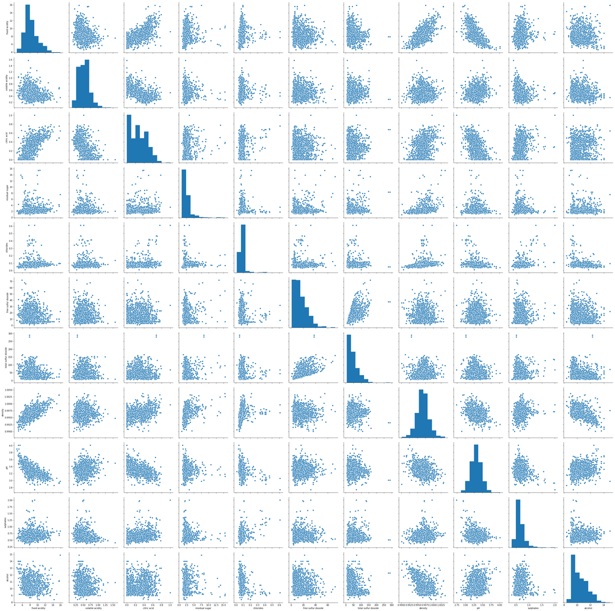

```python
sns.pairplot(wine_red_df.iloc[:,:-1],height=3.5)
```

## Correlation

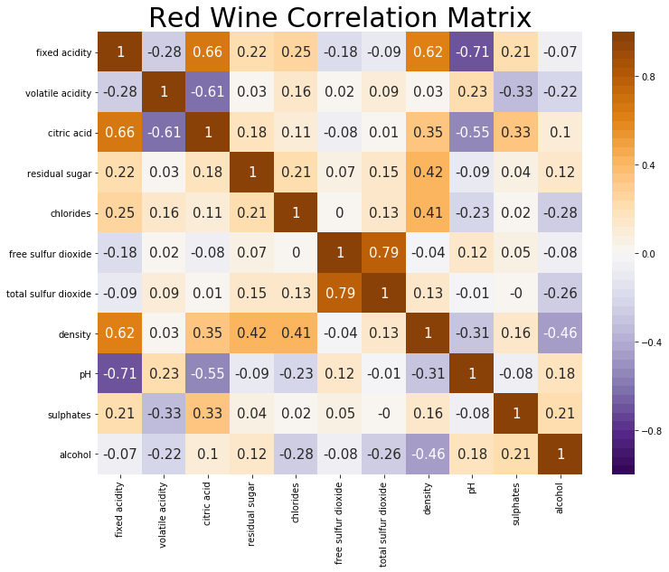

```python
def coorelation_matrix_plot(data, title = "Red Wine Correlation Matrix", height = 9, width = 12):
    cor_mat = round(data.corr(method ="spearman"), 2)
    plt.figure(figsize = (width, height))
    ax = sns.heatmap(cor_mat, annot=True, annot_kws={"size": 15}, cmap = sns.color_palette("PuOr_r", 50),
                     vmin = -1, vmax = 1)
    ax.axes.set_title(title, fontsize = 30)
    ax.title.set_position([.5, 1.03])
    plt.show()

coorelation_matrix_plot(wine_red_df.iloc[:,:-1], title = "Red Wine Correlation Matrix")
```

Heatmap shows the correlation between the variables in the dataset. High concentration of color representation high corrlation. Brown represents positive and purple represents negative correlation.

From the above heatmap on the red wine, we have the following inference

- It looks like we have pH and fixed acidity has inverse relationships between them. The same in case of citric acid and volatile acidity too.
- There is a strong positive relationship between total sulfur dioxide and free sulfur dioxide.

**Negative coorelation**

1. PH and Acidiy of -0.71

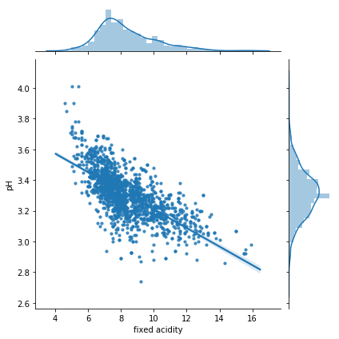

```python
#Create a new dataframe containing only pH and fixed acidity columns to visualize their co-relations
fixedAcidity_pH = wine_red_df[['pH', 'fixed acidity']]

#Initialize a joint-grid with the dataframe, using seaborn library
gridA = sns.JointGrid(x="fixed acidity", y="pH", data=fixedAcidity_pH, size=6)

#Draws a regression plot in the grid
gridA = gridA.plot_joint(sns.regplot, scatter_kws={"s": 10})

#Draws a distribution plot in the same grid
gridA = gridA.plot_marginals(sns.distplot)
```

**Positive coorelation**

1. Fixed acidity with citric acid with coorelation value of 0.66

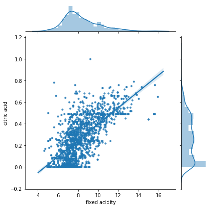

```python
fixedAcidity_citricAcid = wine_red_df[['citric acid', 'fixed acidity']]
g = sns.JointGrid(x="fixed acidity", y="citric acid", data=fixedAcidity_citricAcid, size=6)
g = g.plot_joint(sns.regplot, scatter_kws={"s": 10})
g = g.plot_marginals(sns.distplot)
```

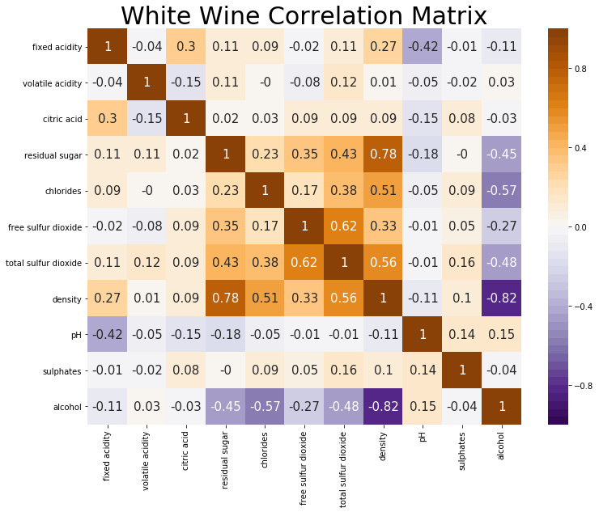

```python
coorelation_matrix_plot(wine_white_df.iloc[:,:-1], title = "White Wine Correlation Matrix")
```

- Alcohol and Density having very High coorelation value of -0.82
- Alcohol and chlorides have fair coorelation value of -0.57
- Fixed acidity and PH have fair coorelation value of -0.42

- Density and Residual Sugar have very high coorelation value of 0.78
- Free sulphur dioxide and total sulphur dioxide have fair coorelation value of 0.62
- Density and chlorides and Total sulphur dioxide have fair coorelation value.

## Outliers

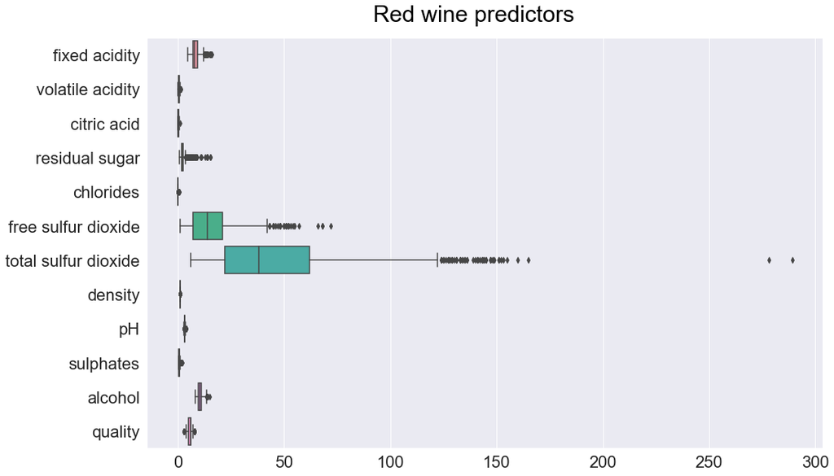

```python
def box_plot(data, height = 10, width = 16, title = "Boxplot"):
    plt.figure(figsize=(width, height))
    plt.suptitle(title, y = 0.94, fontsize = 30)
    sns.set(font_scale = 2)
    sns.boxplot(data = data, orient = "h")

box_plot(data = wine_red_df, title = "Red wine predictors")
```

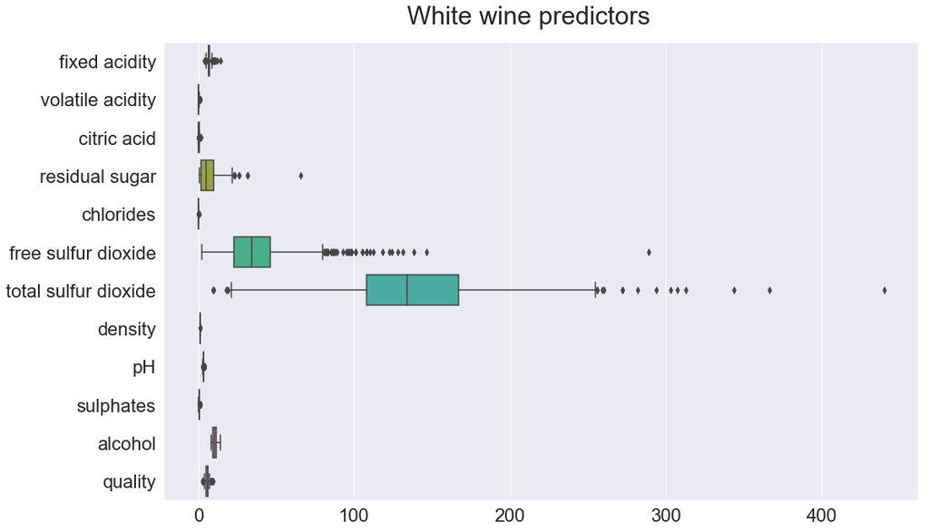

```python
box_plot(data = wine_white_df, title = "White wine predictors")
```

From the above two box plots we get to know about the outliers present in the data which must be removed for better machine learning prediction.

### Removing the outliers

```python
# For each feature find the data points with extreme high or low values
outliers_data_red = pd.DataFrame()
outliers_data_white = pd.DataFrame()
length = 0
for feature in wine_red_df.keys():
    # Calculate Q1 (25th percentile of the data) for the given feature
    Q1 = np.percentile(wine_red_df[feature], q=25)

    # Calculate Q3 (75th percentile of the data) for the given feature
    Q3 = np.percentile(wine_red_df[feature], q=75)

    # Use the interquartile range to calculate an outlier step (1.5 times the interquartile range)
    interquartile_range = Q3 - Q1
    step = 1.5 * interquartile_range

    # Display the outliers
    print("Outliers considered for the red white")
    print("Data points considered outliers for the feature '{}':".format(feature))
    outliers_data_red = outliers_data_red.append(wine_red_df[~((wine_red_df[feature] >= Q1 - step) & (wine_red_df[feature] <= Q3 + step))])
    outliers_data_white = outliers_data_white.append(wine_white_df[~((wine_white_df[feature] >= Q1 - step) & (wine_white_df[feature] <= Q3 + step))])
    display(wine_red_df[~((wine_red_df[feature] >= Q1 - step) & (wine_red_df[feature] <= Q3 + step))])
    print("----------------------------------------------------------------------")
    print("Outliers considered for the white white")
    print("Data points considered outliers for the feature '{}':".format(feature))
    display(wine_white_df[~((wine_white_df[feature] >= Q1 - step) & (wine_white_df[feature] <= Q3 + step))])

#
```

```
Outliers considered for the red white
Data points considered outliers for the feature 'fixed acidity':
```

|  | fixed acidity | volatile acidity | citric acid | residual sugar | chlorides | free sulfur dioxide | total sulfur dioxide | density | pH | sulphates | alcohol | quality |
| --- | --- | --- | --- | --- | --- | --- | --- | --- | --- | --- | --- | --- |
| 205 | 12.8 | 0.300 | 0.74 | 2.6 | 0.095 | 9.0 | 28.0 | 0.99940 | 3.20 | 0.77 | 10.8 | 7 |
| 206 | 12.8 | 0.300 | 0.74 | 2.6 | 0.095 | 9.0 | 28.0 | 0.99940 | 3.20 | 0.77 | 10.8 | 7 |
| 243 | 15.0 | 0.210 | 0.44 | 2.2 | 0.075 | 10.0 | 24.0 | 1.00005 | 3.07 | 0.84 | 9.2 | 7 |
| 244 | 15.0 | 0.210 | 0.44 | 2.2 | 0.075 | 10.0 | 24.0 | 1.00005 | 3.07 | 0.84 | 9.2 | 7 |
| 264 | 12.5 | 0.560 | 0.49 | 2.4 | 0.064 | 5.0 | 27.0 | 0.99990 | 3.08 | 0.87 | 10.9 | 5 |
| 294 | 13.3 | 0.340 | 0.52 | 3.2 | 0.094 | 17.0 | 53.0 | 1.00140 | 3.05 | 0.81 | 9.5 | 6 |
| 328 | 13.4 | 0.270 | 0.62 | 2.6 | 0.082 | 6.0 | 21.0 | 1.00020 | 3.16 | 0.67 | 9.7 | 6 |
| 338 | 12.4 | 0.490 | 0.58 | 3.0 | 0.103 | 28.0 | 99.0 | 1.00080 | 3.16 | 1.00 | 11.5 | 6 |
| 339 | 12.5 | 0.280 | 0.54 | 2.3 | 0.082 | 12.0 | 29.0 | 0.99970 | 3.11 | 1.36 | 9.8 | 7 |
| 347 | 13.8 | 0.490 | 0.67 | 3.0 | 0.093 | 6.0 | 15.0 | 0.99860 | 3.02 | 0.93 | 12.0 | 6 |
| 353 | 13.5 | 0.530 | 0.79 | 4.8 | 0.120 | 23.0 | 77.0 | 1.00180 | 3.18 | 0.77 | 13.0 | 5 |
| 359 | 12.6 | 0.380 | 0.66 | 2.6 | 0.088 | 10.0 | 41.0 | 1.00100 | 3.17 | 0.68 | 9.8 | 6 |
| 363 | 12.5 | 0.460 | 0.63 | 2.0 | 0.071 | 6.0 | 15.0 | 0.99880 | 2.99 | 0.87 | 10.2 | 5 |
| 364 | 12.8 | 0.615 | 0.66 | 5.8 | 0.083 | 7.0 | 42.0 | 1.00220 | 3.07 | 0.73 | 10.0 | 7 |
| 366 | 12.8 | 0.615 | 0.66 | 5.8 | 0.083 | 7.0 | 42.0 | 1.00220 | 3.07 | 0.73 | 10.0 | 7 |
| 374 | 14.0 | 0.410 | 0.63 | 3.8 | 0.089 | 6.0 | 47.0 | 1.00140 | 3.01 | 0.81 | 10.8 | 6 |
| 381 | 13.7 | 0.415 | 0.68 | 2.9 | 0.085 | 17.0 | 43.0 | 1.00140 | 3.06 | 0.80 | 10.0 | 6 |
| 391 | 13.7 | 0.415 | 0.68 | 2.9 | 0.085 | 17.0 | 43.0 | 1.00140 | 3.06 | 0.80 | 10.0 | 6 |
| 394 | 12.7 | 0.600 | 0.65 | 2.3 | 0.063 | 6.0 | 25.0 | 0.99970 | 3.03 | 0.57 | 9.9 | 5 |
| 409 | 12.5 | 0.460 | 0.49 | 4.5 | 0.070 | 26.0 | 49.0 | 0.99810 | 3.05 | 0.57 | 9.6 | 4 |
| 429 | 12.8 | 0.840 | 0.63 | 2.4 | 0.088 | 13.0 | 35.0 | 0.99970 | 3.10 | 0.60 | 10.4 | 6 |
| 440 | 12.6 | 0.310 | 0.72 | 2.2 | 0.072 | 6.0 | 29.0 | 0.99870 | 2.88 | 0.82 | 9.8 | 8 |
| 442 | 15.6 | 0.685 | 0.76 | 3.7 | 0.100 | 6.0 | 43.0 | 1.00320 | 2.95 | 0.68 | 11.2 | 7 |
| 446 | 12.5 | 0.380 | 0.60 | 2.6 | 0.081 | 31.0 | 72.0 | 0.99960 | 3.10 | 0.73 | 10.5 | 5 |
| 470 | 13.0 | 0.320 | 0.65 | 2.6 | 0.093 | 15.0 | 47.0 | 0.99960 | 3.05 | 0.61 | 10.6 | 5 |
| 472 | 12.5 | 0.370 | 0.55 | 2.6 | 0.083 | 25.0 | 68.0 | 0.99950 | 3.15 | 0.82 | 10.4 | 6 |
| 509 | 13.3 | 0.290 | 0.75 | 2.8 | 0.084 | 23.0 | 43.0 | 0.99860 | 3.04 | 0.68 | 11.4 | 7 |
| 510 | 12.4 | 0.420 | 0.49 | 4.6 | 0.073 | 19.0 | 43.0 | 0.99780 | 3.02 | 0.61 | 9.5 | 5 |
| 516 | 12.5 | 0.600 | 0.49 | 4.3 | 0.100 | 5.0 | 14.0 | 1.00100 | 3.25 | 0.74 | 11.9 | 6 |
| 538 | 12.9 | 0.350 | 0.49 | 5.8 | 0.066 | 5.0 | 35.0 | 1.00140 | 3.20 | 0.66 | 12.0 | 7 |
| 544 | 14.3 | 0.310 | 0.74 | 1.8 | 0.075 | 6.0 | 15.0 | 1.00080 | 2.86 | 0.79 | 8.4 | 6 |
| 548 | 12.4 | 0.350 | 0.49 | 2.6 | 0.079 | 27.0 | 69.0 | 0.99940 | 3.12 | 0.75 | 10.4 | 6 |
| 554 | 15.5 | 0.645 | 0.49 | 4.2 | 0.095 | 10.0 | 23.0 | 1.00315 | 2.92 | 0.74 | 11.1 | 5 |
| 555 | 15.5 | 0.645 | 0.49 | 4.2 | 0.095 | 10.0 | 23.0 | 1.00315 | 2.92 | 0.74 | 11.1 | 5 |
| 557 | 15.6 | 0.645 | 0.49 | 4.2 | 0.095 | 10.0 | 23.0 | 1.00315 | 2.92 | 0.74 | 11.1 | 5 |
| 559 | 13.0 | 0.470 | 0.49 | 4.3 | 0.085 | 6.0 | 47.0 | 1.00210 | 3.30 | 0.68 | 12.7 | 6 |
| 560 | 12.7 | 0.600 | 0.49 | 2.8 | 0.075 | 5.0 | 19.0 | 0.99940 | 3.14 | 0.57 | 11.4 | 5 |
| 564 | 13.0 | 0.470 | 0.49 | 4.3 | 0.085 | 6.0 | 47.0 | 1.00210 | 3.30 | 0.68 | 12.7 | 6 |
| 565 | 12.7 | 0.600 | 0.49 | 2.8 | 0.075 | 5.0 | 19.0 | 0.99940 | 3.14 | 0.57 | 11.4 | 5 |
| 596 | 12.4 | 0.400 | 0.51 | 2.0 | 0.059 | 6.0 | 24.0 | 0.99940 | 3.04 | 0.60 | 9.3 | 6 |
| 599 | 12.7 | 0.590 | 0.45 | 2.3 | 0.082 | 11.0 | 22.0 | 1.00000 | 3.00 | 0.70 | 9.3 | 6 |
| 601 | 13.2 | 0.460 | 0.52 | 2.2 | 0.071 | 12.0 | 35.0 | 1.00060 | 3.10 | 0.56 | 9.0 | 6 |
| 603 | 13.2 | 0.460 | 0.52 | 2.2 | 0.071 | 12.0 | 35.0 | 1.00060 | 3.10 | 0.56 | 9.0 | 6 |
| 611 | 13.2 | 0.380 | 0.55 | 2.7 | 0.081 | 5.0 | 16.0 | 1.00060 | 2.98 | 0.54 | 9.4 | 5 |
| 652 | 15.9 | 0.360 | 0.65 | 7.5 | 0.096 | 22.0 | 71.0 | 0.99760 | 2.98 | 0.84 | 14.9 | 5 |
| 680 | 13.3 | 0.430 | 0.58 | 1.9 | 0.070 | 15.0 | 40.0 | 1.00040 | 3.06 | 0.49 | 9.0 | 5 |
| 811 | 12.9 | 0.500 | 0.55 | 2.8 | 0.072 | 7.0 | 24.0 | 1.00012 | 3.09 | 0.68 | 10.9 | 6 |
| 814 | 12.6 | 0.410 | 0.54 | 2.8 | 0.103 | 19.0 | 41.0 | 0.99939 | 3.21 | 0.76 | 11.3 | 6 |
| 1224 | 12.6 | 0.390 | 0.49 | 2.5 | 0.080 | 8.0 | 20.0 | 0.99920 | 3.07 | 0.82 | 10.3 | 6 |

```
----------------------------------------------------------------------
Outliers considered for the white white
Data points considered outliers for the feature 'fixed acidity':
```

|  | fixed acidity | volatile acidity | citric acid | residual sugar | chlorides | free sulfur dioxide | total sulfur dioxide | density | pH | sulphates | alcohol | quality |
| --- | --- | --- | --- | --- | --- | --- | --- | --- | --- | --- | --- | --- |
| 1526 | 14.2 | 0.270 | 0.49 | 1.1 | 0.037 | 33.0 | 156.0 | 0.99200 | 3.15 | 0.54 | 11.1 | 6 |
| 4259 | 3.8 | 0.310 | 0.02 | 11.1 | 0.036 | 20.0 | 114.0 | 0.99248 | 3.75 | 0.44 | 12.4 | 6 |
| 4787 | 3.9 | 0.225 | 0.40 | 4.2 | 0.030 | 29.0 | 118.0 | 0.98900 | 3.57 | 0.36 | 12.8 | 8 |

```
Outliers considered for the red white
Data points considered outliers for the feature 'volatile acidity':
```

|  | fixed acidity | volatile acidity | citric acid | residual sugar | chlorides | free sulfur dioxide | total sulfur dioxide | density | pH | sulphates | alcohol | quality |
| --- | --- | --- | --- | --- | --- | --- | --- | --- | --- | --- | --- | --- |
| 38 | 5.7 | 1.130 | 0.09 | 1.50 | 0.172 | 7.0 | 19.0 | 0.99400 | 3.50 | 0.48 | 9.8 | 4 |
| 94 | 5.0 | 1.020 | 0.04 | 1.40 | 0.045 | 41.0 | 85.0 | 0.99380 | 3.75 | 0.48 | 10.5 | 4 |
| 120 | 7.3 | 1.070 | 0.09 | 1.70 | 0.178 | 10.0 | 89.0 | 0.99620 | 3.30 | 0.57 | 9.0 | 5 |
| 126 | 8.2 | 1.330 | 0.00 | 1.70 | 0.081 | 3.0 | 12.0 | 0.99640 | 3.53 | 0.49 | 10.9 | 5 |
| 127 | 8.1 | 1.330 | 0.00 | 1.80 | 0.082 | 3.0 | 12.0 | 0.99640 | 3.54 | 0.48 | 10.9 | 5 |
| 134 | 7.9 | 1.040 | 0.05 | 2.20 | 0.084 | 13.0 | 29.0 | 0.99590 | 3.22 | 0.55 | 9.9 | 6 |
| 199 | 6.9 | 1.090 | 0.06 | 2.10 | 0.061 | 12.0 | 31.0 | 0.99480 | 3.51 | 0.43 | 11.4 | 4 |
| 553 | 5.0 | 1.040 | 0.24 | 1.60 | 0.050 | 32.0 | 96.0 | 0.99340 | 3.74 | 0.62 | 11.5 | 5 |
| 672 | 9.8 | 1.240 | 0.34 | 2.00 | 0.079 | 32.0 | 151.0 | 0.99800 | 3.15 | 0.53 | 9.5 | 5 |
| 690 | 7.4 | 1.185 | 0.00 | 4.25 | 0.097 | 5.0 | 14.0 | 0.99660 | 3.63 | 0.54 | 10.7 | 3 |
| 700 | 10.6 | 1.020 | 0.43 | 2.90 | 0.076 | 26.0 | 88.0 | 0.99840 | 3.08 | 0.57 | 10.1 | 6 |
| 705 | 8.4 | 1.035 | 0.15 | 6.00 | 0.073 | 11.0 | 54.0 | 0.99900 | 3.37 | 0.49 | 9.9 | 5 |
| 710 | 10.6 | 1.025 | 0.43 | 2.80 | 0.080 | 21.0 | 84.0 | 0.99850 | 3.06 | 0.57 | 10.1 | 5 |
| 724 | 7.5 | 1.115 | 0.10 | 3.10 | 0.086 | 5.0 | 12.0 | 0.99580 | 3.54 | 0.60 | 11.2 | 4 |
| 899 | 8.3 | 1.020 | 0.02 | 3.40 | 0.084 | 6.0 | 11.0 | 0.99892 | 3.48 | 0.49 | 11.0 | 3 |
| 1261 | 6.3 | 1.020 | 0.00 | 2.00 | 0.083 | 17.0 | 24.0 | 0.99437 | 3.59 | 0.55 | 11.2 | 4 |
| 1299 | 7.6 | 1.580 | 0.00 | 2.10 | 0.137 | 5.0 | 9.0 | 0.99476 | 3.50 | 0.40 | 10.9 | 3 |
| 1312 | 8.0 | 1.180 | 0.21 | 1.90 | 0.083 | 14.0 | 41.0 | 0.99532 | 3.34 | 0.47 | 10.5 | 5 |
| 1467 | 6.7 | 1.040 | 0.08 | 2.30 | 0.067 | 19.0 | 32.0 | 0.99648 | 3.52 | 0.57 | 11.0 | 4 |

```
----------------------------------------------------------------------
Outliers considered for the white white
Data points considered outliers for the feature 'volatile acidity':
```

|  | fixed acidity | volatile acidity | citric acid | residual sugar | chlorides | free sulfur dioxide | total sulfur dioxide | density | pH | sulphates | alcohol | quality |
| --- | --- | --- | --- | --- | --- | --- | --- | --- | --- | --- | --- | --- |
| 4039 | 6.1 | 1.1 | 0.16 | 4.4 | 0.033 | 8.0 | 109.0 | 0.99058 | 3.35 | 0.47 | 12.4 | 4 |

```
Outliers considered for the red white
Data points considered outliers for the feature 'citric acid':
```

|  | fixed acidity | volatile acidity | citric acid | residual sugar | chlorides | free sulfur dioxide | total sulfur dioxide | density | pH | sulphates | alcohol | quality |
| --- | --- | --- | --- | --- | --- | --- | --- | --- | --- | --- | --- | --- |
| 151 | 9.2 | 0.52 | 1.0 | 3.4 | 0.61 | 32.0 | 69.0 | 0.9996 | 2.74 | 2.0 | 9.4 | 4 |

```
----------------------------------------------------------------------
Outliers considered for the white white
Data points considered outliers for the feature 'citric acid':
```

|  | fixed acidity | volatile acidity | citric acid | residual sugar | chlorides | free sulfur dioxide | total sulfur dioxide | density | pH | sulphates | alcohol | quality |
| --- | --- | --- | --- | --- | --- | --- | --- | --- | --- | --- | --- | --- |
| 745 | 7.4 | 0.200 | 1.66 | 2.10 | 0.022 | 34.0 | 113.0 | 0.99165 | 3.26 | 0.55 | 12.2 | 6 |
| 946 | 8.2 | 0.345 | 1.00 | 18.20 | 0.047 | 55.0 | 205.0 | 0.99965 | 2.96 | 0.43 | 9.6 | 5 |
| 1551 | 6.6 | 0.190 | 0.99 | 1.20 | 0.122 | 45.0 | 129.0 | 0.99360 | 3.09 | 0.31 | 8.7 | 6 |
| 1722 | 7.5 | 0.400 | 1.00 | 19.50 | 0.041 | 33.0 | 148.0 | 0.99770 | 3.24 | 0.38 | 12.0 | 6 |
| 1775 | 7.7 | 0.490 | 1.00 | 19.60 | 0.030 | 28.0 | 135.0 | 0.99730 | 3.24 | 0.40 | 12.0 | 6 |
| 3043 | 7.2 | 0.210 | 1.00 | 1.10 | 0.154 | 46.0 | 114.0 | 0.99310 | 2.95 | 0.43 | 9.2 | 6 |
| 3152 | 7.6 | 0.250 | 1.23 | 4.60 | 0.035 | 51.0 | 294.0 | 0.99018 | 3.03 | 0.43 | 13.1 | 6 |
| 3497 | 7.7 | 0.430 | 1.00 | 19.95 | 0.032 | 42.0 | 164.0 | 0.99742 | 3.29 | 0.50 | 12.0 | 6 |

```
Outliers considered for the red white
Data points considered outliers for the feature 'residual sugar':
```

|  | fixed acidity | volatile acidity | citric acid | residual sugar | chlorides | free sulfur dioxide | total sulfur dioxide | density | pH | sulphates | alcohol | quality |
| --- | --- | --- | --- | --- | --- | --- | --- | --- | --- | --- | --- | --- |
| 9 | 7.5 | 0.500 | 0.36 | 6.10 | 0.071 | 17.0 | 102.0 | 0.99780 | 3.35 | 0.80 | 10.500000 | 5 |
| 11 | 7.5 | 0.500 | 0.36 | 6.10 | 0.071 | 17.0 | 102.0 | 0.99780 | 3.35 | 0.80 | 10.500000 | 5 |
| 14 | 8.9 | 0.620 | 0.18 | 3.80 | 0.176 | 52.0 | 145.0 | 0.99860 | 3.16 | 0.88 | 9.200000 | 5 |
| 15 | 8.9 | 0.620 | 0.19 | 3.90 | 0.170 | 51.0 | 148.0 | 0.99860 | 3.17 | 0.93 | 9.200000 | 5 |
| 18 | 7.4 | 0.590 | 0.08 | 4.40 | 0.086 | 6.0 | 29.0 | 0.99740 | 3.38 | 0.50 | 9.000000 | 4 |
| 33 | 6.9 | 0.605 | 0.12 | 10.70 | 0.073 | 40.0 | 83.0 | 0.99930 | 3.45 | 0.52 | 9.400000 | 6 |
| 35 | 7.8 | 0.645 | 0.00 | 5.50 | 0.086 | 5.0 | 18.0 | 0.99860 | 3.40 | 0.55 | 9.600000 | 6 |
| 39 | 7.3 | 0.450 | 0.36 | 5.90 | 0.074 | 12.0 | 87.0 | 0.99780 | 3.33 | 0.83 | 10.500000 | 5 |
| 40 | 7.3 | 0.450 | 0.36 | 5.90 | 0.074 | 12.0 | 87.0 | 0.99780 | 3.33 | 0.83 | 10.500000 | 5 |
| 55 | 7.7 | 0.620 | 0.04 | 3.80 | 0.084 | 25.0 | 45.0 | 0.99780 | 3.34 | 0.53 | 9.500000 | 5 |
| 57 | 7.5 | 0.630 | 0.12 | 5.10 | 0.111 | 50.0 | 110.0 | 0.99830 | 3.26 | 0.77 | 9.400000 | 5 |
| 64 | 7.2 | 0.725 | 0.05 | 4.65 | 0.086 | 4.0 | 11.0 | 0.99620 | 3.41 | 0.39 | 10.900000 | 5 |
| 65 | 7.2 | 0.725 | 0.05 | 4.65 | 0.086 | 4.0 | 11.0 | 0.99620 | 3.41 | 0.39 | 10.900000 | 5 |
| 154 | 7.1 | 0.430 | 0.42 | 5.50 | 0.070 | 29.0 | 129.0 | 0.99730 | 3.42 | 0.72 | 10.500000 | 5 |
| 155 | 7.1 | 0.430 | 0.42 | 5.50 | 0.071 | 28.0 | 128.0 | 0.99730 | 3.42 | 0.71 | 10.500000 | 5 |
| 156 | 7.1 | 0.430 | 0.42 | 5.50 | 0.070 | 29.0 | 129.0 | 0.99730 | 3.42 | 0.72 | 10.500000 | 5 |
| 157 | 7.1 | 0.430 | 0.42 | 5.50 | 0.071 | 28.0 | 128.0 | 0.99730 | 3.42 | 0.71 | 10.500000 | 5 |
| 163 | 7.4 | 0.600 | 0.26 | 7.30 | 0.070 | 36.0 | 121.0 | 0.99820 | 3.37 | 0.49 | 9.400000 | 5 |
| 164 | 7.3 | 0.590 | 0.26 | 7.20 | 0.070 | 35.0 | 121.0 | 0.99810 | 3.37 | 0.49 | 9.400000 | 5 |
| 192 | 6.8 | 0.630 | 0.12 | 3.80 | 0.099 | 16.0 | 126.0 | 0.99690 | 3.28 | 0.61 | 9.500000 | 5 |
| 215 | 7.0 | 0.490 | 0.49 | 5.60 | 0.060 | 26.0 | 121.0 | 0.99740 | 3.34 | 0.76 | 10.500000 | 5 |
| 269 | 11.5 | 0.180 | 0.51 | 4.00 | 0.104 | 4.0 | 23.0 | 0.99960 | 3.28 | 0.97 | 10.100000 | 6 |
| 270 | 7.9 | 0.545 | 0.06 | 4.00 | 0.087 | 27.0 | 61.0 | 0.99650 | 3.36 | 0.67 | 10.700000 | 6 |
| 271 | 11.5 | 0.180 | 0.51 | 4.00 | 0.104 | 4.0 | 23.0 | 0.99960 | 3.28 | 0.97 | 10.100000 | 6 |
| 272 | 10.9 | 0.370 | 0.58 | 4.00 | 0.071 | 17.0 | 65.0 | 0.99935 | 3.22 | 0.78 | 10.100000 | 5 |
| 274 | 7.5 | 0.650 | 0.18 | 7.00 | 0.088 | 27.0 | 94.0 | 0.99915 | 3.38 | 0.77 | 9.400000 | 5 |
| 275 | 7.9 | 0.545 | 0.06 | 4.00 | 0.087 | 27.0 | 61.0 | 0.99650 | 3.36 | 0.67 | 10.700000 | 6 |
| 277 | 11.5 | 0.180 | 0.51 | 4.00 | 0.104 | 4.0 | 23.0 | 0.99960 | 3.28 | 0.97 | 10.100000 | 6 |
| 278 | 10.3 | 0.320 | 0.45 | 6.40 | 0.073 | 5.0 | 13.0 | 0.99760 | 3.23 | 0.82 | 12.600000 | 8 |
| 279 | 8.9 | 0.400 | 0.32 | 5.60 | 0.087 | 10.0 | 47.0 | 0.99910 | 3.38 | 0.77 | 10.500000 | 7 |
| ... | ... | ... | ... | ... | ... | ... | ... | ... | ... | ... | ... | ... |
| 1289 | 7.0 | 0.600 | 0.30 | 4.50 | 0.068 | 20.0 | 110.0 | 0.99914 | 3.30 | 1.17 | 10.200000 | 5 |
| 1295 | 6.6 | 0.630 | 0.00 | 4.30 | 0.093 | 51.0 | 77.5 | 0.99558 | 3.20 | 0.45 | 9.500000 | 5 |
| 1296 | 6.6 | 0.630 | 0.00 | 4.30 | 0.093 | 51.0 | 77.5 | 0.99558 | 3.20 | 0.45 | 9.500000 | 5 |
| 1307 | 6.8 | 0.680 | 0.09 | 3.90 | 0.068 | 15.0 | 29.0 | 0.99524 | 3.41 | 0.52 | 11.100000 | 4 |
| 1331 | 7.8 | 0.870 | 0.26 | 3.80 | 0.107 | 31.0 | 67.0 | 0.99668 | 3.26 | 0.46 | 9.200000 | 5 |
| 1358 | 7.4 | 0.640 | 0.17 | 5.40 | 0.168 | 52.0 | 98.0 | 0.99736 | 3.28 | 0.50 | 9.500000 | 5 |
| 1373 | 7.7 | 0.750 | 0.27 | 3.80 | 0.110 | 34.0 | 89.0 | 0.99664 | 3.24 | 0.45 | 9.300000 | 5 |
| 1388 | 6.6 | 0.640 | 0.31 | 6.10 | 0.083 | 7.0 | 49.0 | 0.99718 | 3.35 | 0.68 | 10.300000 | 5 |
| 1394 | 6.4 | 0.570 | 0.14 | 3.90 | 0.070 | 27.0 | 73.0 | 0.99669 | 3.32 | 0.48 | 9.200000 | 5 |
| 1406 | 8.2 | 0.240 | 0.34 | 5.10 | 0.062 | 8.0 | 22.0 | 0.99740 | 3.22 | 0.94 | 10.900000 | 6 |
| 1412 | 8.2 | 0.240 | 0.34 | 5.10 | 0.062 | 8.0 | 22.0 | 0.99740 | 3.22 | 0.94 | 10.900000 | 6 |
| 1423 | 6.4 | 0.530 | 0.09 | 3.90 | 0.123 | 14.0 | 31.0 | 0.99680 | 3.50 | 0.67 | 11.000000 | 4 |
| 1434 | 10.2 | 0.540 | 0.37 | 15.40 | 0.214 | 55.0 | 95.0 | 1.00369 | 3.18 | 0.77 | 9.000000 | 6 |
| 1435 | 10.2 | 0.540 | 0.37 | 15.40 | 0.214 | 55.0 | 95.0 | 1.00369 | 3.18 | 0.77 | 9.000000 | 6 |
| 1437 | 6.8 | 0.915 | 0.29 | 4.80 | 0.070 | 15.0 | 39.0 | 0.99577 | 3.53 | 0.54 | 11.100000 | 5 |
| 1441 | 7.4 | 0.785 | 0.19 | 5.20 | 0.094 | 19.0 | 98.0 | 0.99713 | 3.16 | 0.52 | 9.566667 | 6 |
| 1445 | 7.4 | 0.785 | 0.19 | 5.20 | 0.094 | 19.0 | 98.0 | 0.99713 | 3.16 | 0.52 | 9.600000 | 6 |
| 1471 | 6.7 | 0.700 | 0.08 | 3.75 | 0.067 | 8.0 | 16.0 | 0.99334 | 3.43 | 0.52 | 12.600000 | 5 |
| 1474 | 9.9 | 0.500 | 0.50 | 13.80 | 0.205 | 48.0 | 82.0 | 1.00242 | 3.16 | 0.75 | 8.800000 | 5 |
| 1476 | 9.9 | 0.500 | 0.50 | 13.80 | 0.205 | 48.0 | 82.0 | 1.00242 | 3.16 | 0.75 | 8.800000 | 5 |
| 1478 | 7.1 | 0.875 | 0.05 | 5.70 | 0.082 | 3.0 | 14.0 | 0.99808 | 3.40 | 0.52 | 10.200000 | 3 |
| 1501 | 7.8 | 0.820 | 0.29 | 4.30 | 0.083 | 21.0 | 64.0 | 0.99642 | 3.16 | 0.53 | 9.400000 | 5 |
| 1514 | 6.9 | 0.840 | 0.21 | 4.10 | 0.074 | 16.0 | 65.0 | 0.99842 | 3.53 | 0.72 | 9.233333 | 6 |
| 1515 | 6.9 | 0.840 | 0.21 | 4.10 | 0.074 | 16.0 | 65.0 | 0.99842 | 3.53 | 0.72 | 9.250000 | 6 |
| 1540 | 6.2 | 0.520 | 0.08 | 4.40 | 0.071 | 11.0 | 32.0 | 0.99646 | 3.56 | 0.63 | 11.600000 | 6 |
| 1552 | 6.3 | 0.680 | 0.01 | 3.70 | 0.103 | 32.0 | 54.0 | 0.99586 | 3.51 | 0.66 | 11.300000 | 6 |
| 1558 | 6.9 | 0.630 | 0.33 | 6.70 | 0.235 | 66.0 | 115.0 | 0.99787 | 3.22 | 0.56 | 9.500000 | 5 |
| 1574 | 5.6 | 0.310 | 0.78 | 13.90 | 0.074 | 23.0 | 92.0 | 0.99677 | 3.39 | 0.48 | 10.500000 | 6 |
| 1577 | 6.2 | 0.700 | 0.15 | 5.10 | 0.076 | 13.0 | 27.0 | 0.99622 | 3.54 | 0.60 | 11.900000 | 6 |
| 1589 | 6.6 | 0.725 | 0.20 | 7.80 | 0.073 | 29.0 | 79.0 | 0.99770 | 3.29 | 0.54 | 9.200000 | 5 |

155 rows × 12 columns

```
----------------------------------------------------------------------
Outliers considered for the white white
Data points considered outliers for the feature 'residual sugar':
```

|  | fixed acidity | volatile acidity | citric acid | residual sugar | chlorides | free sulfur dioxide | total sulfur dioxide | density | pH | sulphates | alcohol | quality |
| --- | --- | --- | --- | --- | --- | --- | --- | --- | --- | --- | --- | --- |
| 0 | 7.0 | 0.270 | 0.36 | 20.70 | 0.045 | 45.0 | 170.0 | 1.00100 | 3.00 | 0.45 | 8.800000 | 6 |
| 2 | 8.1 | 0.280 | 0.40 | 6.90 | 0.050 | 30.0 | 97.0 | 0.99510 | 3.26 | 0.44 | 10.100000 | 6 |
| 3 | 7.2 | 0.230 | 0.32 | 8.50 | 0.058 | 47.0 | 186.0 | 0.99560 | 3.19 | 0.40 | 9.900000 | 6 |
| 4 | 7.2 | 0.230 | 0.32 | 8.50 | 0.058 | 47.0 | 186.0 | 0.99560 | 3.19 | 0.40 | 9.900000 | 6 |
| 5 | 8.1 | 0.280 | 0.40 | 6.90 | 0.050 | 30.0 | 97.0 | 0.99510 | 3.26 | 0.44 | 10.100000 | 6 |
| 6 | 6.2 | 0.320 | 0.16 | 7.00 | 0.045 | 30.0 | 136.0 | 0.99490 | 3.18 | 0.47 | 9.600000 | 6 |
| 7 | 7.0 | 0.270 | 0.36 | 20.70 | 0.045 | 45.0 | 170.0 | 1.00100 | 3.00 | 0.45 | 8.800000 | 6 |
| 11 | 8.6 | 0.230 | 0.40 | 4.20 | 0.035 | 17.0 | 109.0 | 0.99470 | 3.14 | 0.53 | 9.700000 | 5 |
| 14 | 8.3 | 0.420 | 0.62 | 19.25 | 0.040 | 41.0 | 172.0 | 1.00020 | 2.98 | 0.67 | 9.700000 | 5 |
| 19 | 6.5 | 0.310 | 0.14 | 7.50 | 0.044 | 34.0 | 133.0 | 0.99550 | 3.22 | 0.50 | 9.500000 | 5 |
| 25 | 7.0 | 0.250 | 0.32 | 9.00 | 0.046 | 56.0 | 245.0 | 0.99550 | 3.25 | 0.50 | 10.400000 | 6 |
| 27 | 7.0 | 0.280 | 0.39 | 8.70 | 0.051 | 32.0 | 141.0 | 0.99610 | 3.38 | 0.53 | 10.500000 | 6 |
| 30 | 8.5 | 0.240 | 0.39 | 10.40 | 0.044 | 20.0 | 142.0 | 0.99740 | 3.20 | 0.53 | 10.000000 | 6 |
| 34 | 5.8 | 0.270 | 0.20 | 14.95 | 0.044 | 22.0 | 179.0 | 0.99620 | 3.37 | 0.37 | 10.200000 | 5 |
| 36 | 6.5 | 0.390 | 0.23 | 5.40 | 0.051 | 25.0 | 149.0 | 0.99340 | 3.24 | 0.35 | 10.000000 | 5 |
| 38 | 7.3 | 0.240 | 0.39 | 17.95 | 0.057 | 45.0 | 149.0 | 0.99990 | 3.21 | 0.36 | 8.600000 | 5 |
| 39 | 7.3 | 0.240 | 0.39 | 17.95 | 0.057 | 45.0 | 149.0 | 0.99990 | 3.21 | 0.36 | 8.600000 | 5 |
| 42 | 7.0 | 0.310 | 0.26 | 7.40 | 0.069 | 28.0 | 160.0 | 0.99540 | 3.13 | 0.46 | 9.800000 | 6 |
| 46 | 6.2 | 0.450 | 0.26 | 4.40 | 0.063 | 63.0 | 206.0 | 0.99400 | 3.27 | 0.52 | 9.800000 | 4 |
| 47 | 6.2 | 0.460 | 0.25 | 4.40 | 0.066 | 62.0 | 207.0 | 0.99390 | 3.25 | 0.52 | 9.800000 | 5 |
| 48 | 7.0 | 0.310 | 0.26 | 7.40 | 0.069 | 28.0 | 160.0 | 0.99540 | 3.13 | 0.46 | 9.800000 | 6 |
| 49 | 6.9 | 0.190 | 0.35 | 5.00 | 0.067 | 32.0 | 150.0 | 0.99500 | 3.36 | 0.48 | 9.800000 | 5 |
| 56 | 7.2 | 0.210 | 0.34 | 11.90 | 0.043 | 37.0 | 213.0 | 0.99620 | 3.09 | 0.50 | 9.600000 | 6 |
| 57 | 6.0 | 0.190 | 0.26 | 12.40 | 0.048 | 50.0 | 147.0 | 0.99720 | 3.30 | 0.36 | 8.900000 | 6 |
| 58 | 6.6 | 0.380 | 0.15 | 4.60 | 0.044 | 25.0 | 78.0 | 0.99310 | 3.11 | 0.38 | 10.200000 | 6 |
| 60 | 6.8 | 0.220 | 0.24 | 4.90 | 0.092 | 30.0 | 123.0 | 0.99510 | 3.03 | 0.46 | 8.600000 | 6 |
| 61 | 6.0 | 0.190 | 0.26 | 12.40 | 0.048 | 50.0 | 147.0 | 0.99720 | 3.30 | 0.36 | 8.900000 | 6 |
| 63 | 6.6 | 0.380 | 0.15 | 4.60 | 0.044 | 25.0 | 78.0 | 0.99310 | 3.11 | 0.38 | 10.200000 | 6 |
| 66 | 6.4 | 0.260 | 0.24 | 6.40 | 0.040 | 27.0 | 124.0 | 0.99030 | 3.22 | 0.49 | 12.600000 | 7 |
| 69 | 7.4 | 0.240 | 0.29 | 10.10 | 0.050 | 21.0 | 105.0 | 0.99620 | 3.13 | 0.35 | 9.500000 | 5 |
| ... | ... | ... | ... | ... | ... | ... | ... | ... | ... | ... | ... | ... |
| 4829 | 6.0 | 0.320 | 0.33 | 9.90 | 0.032 | 22.0 | 90.0 | 0.99258 | 3.10 | 0.43 | 12.100000 | 7 |
| 4836 | 6.7 | 0.500 | 0.36 | 11.50 | 0.096 | 18.0 | 92.0 | 0.99642 | 3.11 | 0.49 | 9.600000 | 5 |
| 4837 | 6.5 | 0.280 | 0.38 | 7.80 | 0.031 | 54.0 | 216.0 | 0.99154 | 3.03 | 0.42 | 13.100000 | 6 |
| 4838 | 5.3 | 0.275 | 0.24 | 7.40 | 0.038 | 28.0 | 114.0 | 0.99313 | 3.38 | 0.51 | 11.000000 | 6 |
| 4840 | 6.8 | 0.340 | 0.36 | 8.90 | 0.029 | 44.0 | 128.0 | 0.99318 | 3.28 | 0.35 | 11.950000 | 7 |
| 4847 | 4.4 | 0.540 | 0.09 | 5.10 | 0.038 | 52.0 | 97.0 | 0.99022 | 3.41 | 0.40 | 12.200000 | 7 |
| 4849 | 6.4 | 0.330 | 0.44 | 8.90 | 0.055 | 52.0 | 164.0 | 0.99488 | 3.10 | 0.48 | 9.600000 | 5 |
| 4851 | 6.4 | 0.330 | 0.44 | 8.90 | 0.055 | 52.0 | 164.0 | 0.99488 | 3.10 | 0.48 | 9.600000 | 5 |
| 4854 | 6.2 | 0.350 | 0.29 | 3.90 | 0.041 | 22.0 | 79.0 | 0.99005 | 3.10 | 0.59 | 12.066667 | 6 |
| 4855 | 7.1 | 0.230 | 0.39 | 13.70 | 0.058 | 26.0 | 172.0 | 0.99755 | 2.90 | 0.46 | 9.000000 | 6 |
| 4856 | 7.1 | 0.230 | 0.39 | 13.70 | 0.058 | 26.0 | 172.0 | 0.99755 | 2.90 | 0.46 | 9.000000 | 6 |
| 4857 | 7.5 | 0.380 | 0.33 | 9.20 | 0.043 | 19.0 | 116.0 | 0.99444 | 3.08 | 0.42 | 11.400000 | 6 |
| 4858 | 6.4 | 0.350 | 0.51 | 7.80 | 0.055 | 53.0 | 177.0 | 0.99502 | 3.12 | 0.45 | 9.600000 | 5 |
| 4859 | 6.0 | 0.430 | 0.34 | 7.60 | 0.045 | 25.0 | 118.0 | 0.99222 | 3.03 | 0.37 | 11.000000 | 6 |
| 4860 | 6.0 | 0.520 | 0.33 | 7.70 | 0.046 | 24.0 | 119.0 | 0.99224 | 3.04 | 0.38 | 11.000000 | 6 |
| 4863 | 6.2 | 0.360 | 0.32 | 4.00 | 0.036 | 44.0 | 92.0 | 0.98936 | 3.20 | 0.50 | 13.300000 | 7 |
| 4868 | 5.8 | 0.230 | 0.31 | 4.50 | 0.046 | 42.0 | 124.0 | 0.99324 | 3.31 | 0.64 | 10.800000 | 6 |
| 4869 | 6.6 | 0.240 | 0.33 | 10.10 | 0.032 | 8.0 | 81.0 | 0.99626 | 3.19 | 0.51 | 9.800000 | 6 |
| 4870 | 6.1 | 0.320 | 0.28 | 6.60 | 0.021 | 29.0 | 132.0 | 0.99188 | 3.15 | 0.36 | 11.450000 | 7 |
| 4872 | 6.0 | 0.420 | 0.41 | 12.40 | 0.032 | 50.0 | 179.0 | 0.99622 | 3.14 | 0.60 | 9.700000 | 5 |
| 4877 | 5.9 | 0.540 | 0.00 | 0.80 | 0.032 | 12.0 | 82.0 | 0.99286 | 3.25 | 0.36 | 8.800000 | 5 |
| 4879 | 6.6 | 0.340 | 0.40 | 8.10 | 0.046 | 68.0 | 170.0 | 0.99494 | 3.15 | 0.50 | 9.533333 | 6 |
| 4880 | 6.6 | 0.340 | 0.40 | 8.10 | 0.046 | 68.0 | 170.0 | 0.99494 | 3.15 | 0.50 | 9.533333 | 6 |
| 4881 | 5.0 | 0.235 | 0.27 | 11.75 | 0.030 | 34.0 | 118.0 | 0.99540 | 3.07 | 0.50 | 9.400000 | 6 |
| 4884 | 6.5 | 0.330 | 0.38 | 8.30 | 0.048 | 68.0 | 174.0 | 0.99492 | 3.14 | 0.50 | 9.600000 | 5 |
| 4885 | 6.6 | 0.340 | 0.40 | 8.10 | 0.046 | 68.0 | 170.0 | 0.99494 | 3.15 | 0.50 | 9.550000 | 6 |
| 4886 | 6.2 | 0.210 | 0.28 | 5.70 | 0.028 | 45.0 | 121.0 | 0.99168 | 3.21 | 1.08 | 12.150000 | 7 |
| 4889 | 4.9 | 0.235 | 0.27 | 11.75 | 0.030 | 34.0 | 118.0 | 0.99540 | 3.07 | 0.50 | 9.400000 | 6 |
| 4894 | 6.6 | 0.320 | 0.36 | 8.00 | 0.047 | 57.0 | 168.0 | 0.99490 | 3.15 | 0.46 | 9.600000 | 5 |
| 4897 | 6.0 | 0.210 | 0.38 | 0.80 | 0.020 | 22.0 | 98.0 | 0.98941 | 3.26 | 0.32 | 11.800000 | 6 |

2912 rows × 12 columns

```
Outliers considered for the red white
Data points considered outliers for the feature 'chlorides':
```

|  | fixed acidity | volatile acidity | citric acid | residual sugar | chlorides | free sulfur dioxide | total sulfur dioxide | density | pH | sulphates | alcohol | quality |
| --- | --- | --- | --- | --- | --- | --- | --- | --- | --- | --- | --- | --- |
| 14 | 8.9 | 0.620 | 0.18 | 3.80 | 0.176 | 52.0 | 145.0 | 0.99860 | 3.16 | 0.88 | 9.2 | 5 |
| 15 | 8.9 | 0.620 | 0.19 | 3.90 | 0.170 | 51.0 | 148.0 | 0.99860 | 3.17 | 0.93 | 9.2 | 5 |
| 17 | 8.1 | 0.560 | 0.28 | 1.70 | 0.368 | 16.0 | 56.0 | 0.99680 | 3.11 | 1.28 | 9.3 | 5 |
| 19 | 7.9 | 0.320 | 0.51 | 1.80 | 0.341 | 17.0 | 56.0 | 0.99690 | 3.04 | 1.08 | 9.2 | 6 |
| 38 | 5.7 | 1.130 | 0.09 | 1.50 | 0.172 | 7.0 | 19.0 | 0.99400 | 3.50 | 0.48 | 9.8 | 4 |
| 42 | 7.5 | 0.490 | 0.20 | 2.60 | 0.332 | 8.0 | 14.0 | 0.99680 | 3.21 | 0.90 | 10.5 | 6 |
| 81 | 7.8 | 0.430 | 0.70 | 1.90 | 0.464 | 22.0 | 67.0 | 0.99740 | 3.13 | 1.28 | 9.4 | 5 |
| 83 | 7.3 | 0.670 | 0.26 | 1.80 | 0.401 | 16.0 | 51.0 | 0.99690 | 3.16 | 1.14 | 9.4 | 5 |
| 106 | 7.8 | 0.410 | 0.68 | 1.70 | 0.467 | 18.0 | 69.0 | 0.99730 | 3.08 | 1.31 | 9.3 | 5 |
| 109 | 8.1 | 0.785 | 0.52 | 2.00 | 0.122 | 37.0 | 153.0 | 0.99690 | 3.21 | 0.69 | 9.3 | 5 |
| 120 | 7.3 | 1.070 | 0.09 | 1.70 | 0.178 | 10.0 | 89.0 | 0.99620 | 3.30 | 0.57 | 9.0 | 5 |
| 125 | 9.0 | 0.620 | 0.04 | 1.90 | 0.146 | 27.0 | 90.0 | 0.99840 | 3.16 | 0.70 | 9.4 | 5 |
| 147 | 7.6 | 0.490 | 0.26 | 1.60 | 0.236 | 10.0 | 88.0 | 0.99680 | 3.11 | 0.80 | 9.3 | 5 |
| 151 | 9.2 | 0.520 | 1.00 | 3.40 | 0.610 | 32.0 | 69.0 | 0.99960 | 2.74 | 2.00 | 9.4 | 4 |
| 169 | 7.5 | 0.705 | 0.24 | 1.80 | 0.360 | 15.0 | 63.0 | 0.99640 | 3.00 | 1.59 | 9.5 | 5 |
| 181 | 8.9 | 0.610 | 0.49 | 2.00 | 0.270 | 23.0 | 110.0 | 0.99720 | 3.12 | 1.02 | 9.3 | 5 |
| 210 | 9.7 | 0.530 | 0.60 | 2.00 | 0.039 | 5.0 | 19.0 | 0.99585 | 3.30 | 0.86 | 12.4 | 6 |
| 226 | 8.9 | 0.590 | 0.50 | 2.00 | 0.337 | 27.0 | 81.0 | 0.99640 | 3.04 | 1.61 | 9.5 | 6 |
| 240 | 8.9 | 0.635 | 0.37 | 1.70 | 0.263 | 5.0 | 62.0 | 0.99710 | 3.00 | 1.09 | 9.3 | 5 |
| 258 | 7.7 | 0.410 | 0.76 | 1.80 | 0.611 | 8.0 | 45.0 | 0.99680 | 3.06 | 1.26 | 9.4 | 5 |
| 281 | 7.7 | 0.270 | 0.68 | 3.50 | 0.358 | 5.0 | 10.0 | 0.99720 | 3.25 | 1.08 | 9.9 | 7 |
| 291 | 11.0 | 0.200 | 0.48 | 2.00 | 0.343 | 6.0 | 18.0 | 0.99790 | 3.30 | 0.71 | 10.5 | 5 |
| 303 | 7.4 | 0.670 | 0.12 | 1.60 | 0.186 | 5.0 | 21.0 | 0.99600 | 3.39 | 0.54 | 9.5 | 5 |
| 307 | 10.3 | 0.410 | 0.42 | 2.40 | 0.213 | 6.0 | 14.0 | 0.99940 | 3.19 | 0.62 | 9.5 | 6 |
| 308 | 10.3 | 0.430 | 0.44 | 2.40 | 0.214 | 5.0 | 12.0 | 0.99940 | 3.19 | 0.63 | 9.5 | 6 |
| 326 | 11.6 | 0.530 | 0.66 | 3.65 | 0.121 | 6.0 | 14.0 | 0.99780 | 3.05 | 0.74 | 11.5 | 7 |
| 330 | 10.2 | 0.360 | 0.64 | 2.90 | 0.122 | 10.0 | 41.0 | 0.99800 | 3.23 | 0.66 | 12.5 | 6 |
| 331 | 10.2 | 0.360 | 0.64 | 2.90 | 0.122 | 10.0 | 41.0 | 0.99800 | 3.23 | 0.66 | 12.5 | 6 |
| 335 | 11.9 | 0.695 | 0.53 | 3.40 | 0.128 | 7.0 | 21.0 | 0.99920 | 3.17 | 0.84 | 12.2 | 7 |
| 353 | 13.5 | 0.530 | 0.79 | 4.80 | 0.120 | 23.0 | 77.0 | 1.00180 | 3.18 | 0.77 | 13.0 | 5 |
| ... | ... | ... | ... | ... | ... | ... | ... | ... | ... | ... | ... | ... |
| 1109 | 10.8 | 0.470 | 0.43 | 2.10 | 0.171 | 27.0 | 66.0 | 0.99820 | 3.17 | 0.76 | 10.8 | 6 |
| 1146 | 7.8 | 0.500 | 0.12 | 1.80 | 0.178 | 6.0 | 21.0 | 0.99600 | 3.28 | 0.87 | 9.8 | 6 |
| 1165 | 8.5 | 0.440 | 0.50 | 1.90 | 0.369 | 15.0 | 38.0 | 0.99634 | 3.01 | 1.10 | 9.4 | 5 |
| 1191 | 6.5 | 0.885 | 0.00 | 2.30 | 0.166 | 6.0 | 12.0 | 0.99551 | 3.56 | 0.51 | 10.8 | 5 |
| 1193 | 6.4 | 0.885 | 0.00 | 2.30 | 0.166 | 6.0 | 12.0 | 0.99551 | 3.56 | 0.51 | 10.8 | 5 |
| 1207 | 9.9 | 0.720 | 0.55 | 1.70 | 0.136 | 24.0 | 52.0 | 0.99752 | 3.35 | 0.94 | 10.0 | 5 |
| 1220 | 10.9 | 0.320 | 0.52 | 1.80 | 0.132 | 17.0 | 44.0 | 0.99734 | 3.28 | 0.77 | 11.5 | 6 |
| 1221 | 10.9 | 0.320 | 0.52 | 1.80 | 0.132 | 17.0 | 44.0 | 0.99734 | 3.28 | 0.77 | 11.5 | 6 |
| 1252 | 7.1 | 0.720 | 0.00 | 1.80 | 0.123 | 6.0 | 14.0 | 0.99627 | 3.45 | 0.58 | 9.8 | 5 |
| 1258 | 6.8 | 0.640 | 0.00 | 2.70 | 0.123 | 15.0 | 33.0 | 0.99538 | 3.44 | 0.63 | 11.3 | 6 |
| 1259 | 6.8 | 0.640 | 0.00 | 2.70 | 0.123 | 15.0 | 33.0 | 0.99538 | 3.44 | 0.63 | 11.3 | 6 |
| 1260 | 8.6 | 0.635 | 0.68 | 1.80 | 0.403 | 19.0 | 56.0 | 0.99632 | 3.02 | 1.15 | 9.3 | 5 |
| 1299 | 7.6 | 1.580 | 0.00 | 2.10 | 0.137 | 5.0 | 9.0 | 0.99476 | 3.50 | 0.40 | 10.9 | 3 |
| 1319 | 9.1 | 0.760 | 0.68 | 1.70 | 0.414 | 18.0 | 64.0 | 0.99652 | 2.90 | 1.33 | 9.1 | 6 |
| 1334 | 7.2 | 0.835 | 0.00 | 2.00 | 0.166 | 4.0 | 11.0 | 0.99608 | 3.39 | 0.52 | 10.0 | 5 |
| 1358 | 7.4 | 0.640 | 0.17 | 5.40 | 0.168 | 52.0 | 98.0 | 0.99736 | 3.28 | 0.50 | 9.5 | 5 |
| 1370 | 8.7 | 0.780 | 0.51 | 1.70 | 0.415 | 12.0 | 66.0 | 0.99623 | 3.00 | 1.17 | 9.2 | 5 |
| 1371 | 7.5 | 0.580 | 0.56 | 3.10 | 0.153 | 5.0 | 14.0 | 0.99476 | 3.21 | 1.03 | 11.6 | 6 |
| 1372 | 8.7 | 0.780 | 0.51 | 1.70 | 0.415 | 12.0 | 66.0 | 0.99623 | 3.00 | 1.17 | 9.2 | 5 |
| 1374 | 6.8 | 0.815 | 0.00 | 1.20 | 0.267 | 16.0 | 29.0 | 0.99471 | 3.32 | 0.51 | 9.8 | 3 |
| 1423 | 6.4 | 0.530 | 0.09 | 3.90 | 0.123 | 14.0 | 31.0 | 0.99680 | 3.50 | 0.67 | 11.0 | 4 |
| 1434 | 10.2 | 0.540 | 0.37 | 15.40 | 0.214 | 55.0 | 95.0 | 1.00369 | 3.18 | 0.77 | 9.0 | 6 |
| 1435 | 10.2 | 0.540 | 0.37 | 15.40 | 0.214 | 55.0 | 95.0 | 1.00369 | 3.18 | 0.77 | 9.0 | 6 |
| 1436 | 10.0 | 0.380 | 0.38 | 1.60 | 0.169 | 27.0 | 90.0 | 0.99914 | 3.15 | 0.65 | 8.5 | 5 |
| 1474 | 9.9 | 0.500 | 0.50 | 13.80 | 0.205 | 48.0 | 82.0 | 1.00242 | 3.16 | 0.75 | 8.8 | 5 |
| 1476 | 9.9 | 0.500 | 0.50 | 13.80 | 0.205 | 48.0 | 82.0 | 1.00242 | 3.16 | 0.75 | 8.8 | 5 |
| 1490 | 7.1 | 0.220 | 0.49 | 1.80 | 0.039 | 8.0 | 18.0 | 0.99344 | 3.39 | 0.56 | 12.4 | 6 |
| 1558 | 6.9 | 0.630 | 0.33 | 6.70 | 0.235 | 66.0 | 115.0 | 0.99787 | 3.22 | 0.56 | 9.5 | 5 |
| 1570 | 6.4 | 0.360 | 0.53 | 2.20 | 0.230 | 19.0 | 35.0 | 0.99340 | 3.37 | 0.93 | 12.4 | 6 |
| 1571 | 6.4 | 0.380 | 0.14 | 2.20 | 0.038 | 15.0 | 25.0 | 0.99514 | 3.44 | 0.65 | 11.1 | 6 |

112 rows × 12 columns

```
----------------------------------------------------------------------
Outliers considered for the white white
Data points considered outliers for the feature 'chlorides':
```

|  | fixed acidity | volatile acidity | citric acid | residual sugar | chlorides | free sulfur dioxide | total sulfur dioxide | density | pH | sulphates | alcohol | quality |
| --- | --- | --- | --- | --- | --- | --- | --- | --- | --- | --- | --- | --- |
| 10 | 8.1 | 0.270 | 0.41 | 1.45 | 0.033 | 11.0 | 63.0 | 0.99080 | 2.99 | 0.56 | 12.00 | 5 |
| 11 | 8.6 | 0.230 | 0.40 | 4.20 | 0.035 | 17.0 | 109.0 | 0.99470 | 3.14 | 0.53 | 9.70 | 5 |
| 12 | 7.9 | 0.180 | 0.37 | 1.20 | 0.040 | 16.0 | 75.0 | 0.99200 | 3.18 | 0.63 | 10.80 | 5 |
| 14 | 8.3 | 0.420 | 0.62 | 19.25 | 0.040 | 41.0 | 172.0 | 1.00020 | 2.98 | 0.67 | 9.70 | 5 |
| 15 | 6.6 | 0.170 | 0.38 | 1.50 | 0.032 | 28.0 | 112.0 | 0.99140 | 3.25 | 0.55 | 11.40 | 7 |
| 17 | 6.2 | 0.660 | 0.48 | 1.20 | 0.029 | 29.0 | 75.0 | 0.98920 | 3.33 | 0.39 | 12.80 | 8 |
| 18 | 7.4 | 0.340 | 0.42 | 1.10 | 0.033 | 17.0 | 171.0 | 0.99170 | 3.12 | 0.53 | 11.30 | 6 |
| 20 | 6.2 | 0.660 | 0.48 | 1.20 | 0.029 | 29.0 | 75.0 | 0.98920 | 3.33 | 0.39 | 12.80 | 8 |
| 21 | 6.4 | 0.310 | 0.38 | 2.90 | 0.038 | 19.0 | 102.0 | 0.99120 | 3.17 | 0.35 | 11.00 | 7 |
| 29 | 7.2 | 0.320 | 0.36 | 2.00 | 0.033 | 37.0 | 114.0 | 0.99060 | 3.10 | 0.71 | 12.30 | 7 |
| 40 | 6.7 | 0.230 | 0.39 | 2.50 | 0.172 | 63.0 | 158.0 | 0.99370 | 3.11 | 0.36 | 9.40 | 6 |
| 41 | 6.7 | 0.240 | 0.39 | 2.90 | 0.173 | 63.0 | 157.0 | 0.99370 | 3.10 | 0.34 | 9.40 | 6 |
| 54 | 6.8 | 0.200 | 0.59 | 0.90 | 0.147 | 38.0 | 132.0 | 0.99300 | 3.05 | 0.38 | 9.10 | 6 |
| 55 | 6.9 | 0.250 | 0.35 | 1.30 | 0.039 | 29.0 | 191.0 | 0.99080 | 3.13 | 0.52 | 11.00 | 6 |
| 59 | 7.4 | 0.200 | 0.36 | 1.20 | 0.038 | 44.0 | 111.0 | 0.99260 | 3.36 | 0.34 | 9.90 | 6 |
| 62 | 7.0 | 0.470 | 0.07 | 1.10 | 0.035 | 17.0 | 151.0 | 0.99100 | 3.02 | 0.34 | 10.50 | 5 |
| 64 | 7.2 | 0.240 | 0.27 | 1.40 | 0.038 | 31.0 | 122.0 | 0.99270 | 3.15 | 0.46 | 10.30 | 6 |
| 66 | 6.4 | 0.260 | 0.24 | 6.40 | 0.040 | 27.0 | 124.0 | 0.99030 | 3.22 | 0.49 | 12.60 | 7 |
| 92 | 6.9 | 0.240 | 0.33 | 1.70 | 0.035 | 47.0 | 136.0 | 0.99000 | 3.26 | 0.40 | 12.60 | 7 |
| 93 | 6.9 | 0.210 | 0.33 | 1.80 | 0.034 | 48.0 | 136.0 | 0.98990 | 3.25 | 0.41 | 12.60 | 7 |
| 94 | 7.5 | 0.170 | 0.32 | 1.70 | 0.040 | 51.0 | 148.0 | 0.99160 | 3.21 | 0.44 | 11.50 | 7 |
| 97 | 8.6 | 0.265 | 0.36 | 1.20 | 0.034 | 15.0 | 80.0 | 0.99130 | 2.95 | 0.36 | 11.40 | 7 |
| 98 | 9.8 | 0.360 | 0.46 | 10.50 | 0.038 | 4.0 | 83.0 | 0.99560 | 2.89 | 0.30 | 10.10 | 4 |
| 107 | 7.1 | 0.230 | 0.35 | 16.50 | 0.040 | 60.0 | 171.0 | 0.99900 | 3.16 | 0.59 | 9.10 | 6 |
| 108 | 7.1 | 0.230 | 0.35 | 16.50 | 0.040 | 60.0 | 171.0 | 0.99900 | 3.16 | 0.59 | 9.10 | 6 |
| 117 | 7.0 | 0.140 | 0.40 | 1.70 | 0.035 | 16.0 | 85.0 | 0.99110 | 3.19 | 0.42 | 11.80 | 6 |
| 125 | 6.7 | 0.190 | 0.36 | 1.10 | 0.026 | 63.0 | 143.0 | 0.99120 | 3.27 | 0.48 | 11.00 | 6 |
| 126 | 7.4 | 0.390 | 0.23 | 7.00 | 0.033 | 29.0 | 126.0 | 0.99400 | 3.14 | 0.42 | 10.50 | 5 |
| 127 | 6.5 | 0.240 | 0.32 | 7.60 | 0.038 | 48.0 | 203.0 | 0.99580 | 3.45 | 0.54 | 9.70 | 7 |
| 130 | 5.7 | 0.260 | 0.25 | 10.40 | 0.020 | 7.0 | 57.0 | 0.99400 | 3.39 | 0.37 | 10.60 | 5 |
| ... | ... | ... | ... | ... | ... | ... | ... | ... | ... | ... | ... | ... |
| 4837 | 6.5 | 0.280 | 0.38 | 7.80 | 0.031 | 54.0 | 216.0 | 0.99154 | 3.03 | 0.42 | 13.10 | 6 |
| 4838 | 5.3 | 0.275 | 0.24 | 7.40 | 0.038 | 28.0 | 114.0 | 0.99313 | 3.38 | 0.51 | 11.00 | 6 |
| 4839 | 5.2 | 0.405 | 0.15 | 1.45 | 0.038 | 10.0 | 44.0 | 0.99125 | 3.52 | 0.40 | 11.60 | 4 |
| 4840 | 6.8 | 0.340 | 0.36 | 8.90 | 0.029 | 44.0 | 128.0 | 0.99318 | 3.28 | 0.35 | 11.95 | 7 |
| 4845 | 6.6 | 0.380 | 0.29 | 2.40 | 0.136 | 15.0 | 93.0 | 0.99336 | 3.18 | 0.60 | 9.50 | 5 |
| 4847 | 4.4 | 0.540 | 0.09 | 5.10 | 0.038 | 52.0 | 97.0 | 0.99022 | 3.41 | 0.40 | 12.20 | 7 |
| 4861 | 5.5 | 0.310 | 0.29 | 3.00 | 0.027 | 16.0 | 102.0 | 0.99067 | 3.23 | 0.56 | 11.20 | 6 |
| 4863 | 6.2 | 0.360 | 0.32 | 4.00 | 0.036 | 44.0 | 92.0 | 0.98936 | 3.20 | 0.50 | 13.30 | 7 |
| 4867 | 5.3 | 0.600 | 0.34 | 1.40 | 0.031 | 3.0 | 60.0 | 0.98854 | 3.27 | 0.38 | 13.00 | 6 |
| 4869 | 6.6 | 0.240 | 0.33 | 10.10 | 0.032 | 8.0 | 81.0 | 0.99626 | 3.19 | 0.51 | 9.80 | 6 |
| 4870 | 6.1 | 0.320 | 0.28 | 6.60 | 0.021 | 29.0 | 132.0 | 0.99188 | 3.15 | 0.36 | 11.45 | 7 |
| 4871 | 5.0 | 0.200 | 0.40 | 1.90 | 0.015 | 20.0 | 98.0 | 0.98970 | 3.37 | 0.55 | 12.05 | 6 |
| 4872 | 6.0 | 0.420 | 0.41 | 12.40 | 0.032 | 50.0 | 179.0 | 0.99622 | 3.14 | 0.60 | 9.70 | 5 |
| 4873 | 5.7 | 0.210 | 0.32 | 1.60 | 0.030 | 33.0 | 122.0 | 0.99044 | 3.33 | 0.52 | 11.90 | 6 |
| 4875 | 7.4 | 0.220 | 0.26 | 1.20 | 0.035 | 18.0 | 97.0 | 0.99245 | 3.12 | 0.41 | 9.70 | 6 |
| 4876 | 6.2 | 0.380 | 0.42 | 2.50 | 0.038 | 34.0 | 117.0 | 0.99132 | 3.36 | 0.59 | 11.60 | 7 |
| 4877 | 5.9 | 0.540 | 0.00 | 0.80 | 0.032 | 12.0 | 82.0 | 0.99286 | 3.25 | 0.36 | 8.80 | 5 |
| 4878 | 6.2 | 0.530 | 0.02 | 0.90 | 0.035 | 6.0 | 81.0 | 0.99234 | 3.24 | 0.35 | 9.50 | 4 |
| 4881 | 5.0 | 0.235 | 0.27 | 11.75 | 0.030 | 34.0 | 118.0 | 0.99540 | 3.07 | 0.50 | 9.40 | 6 |
| 4882 | 5.5 | 0.320 | 0.13 | 1.30 | 0.037 | 45.0 | 156.0 | 0.99184 | 3.26 | 0.38 | 10.70 | 5 |
| 4883 | 4.9 | 0.470 | 0.17 | 1.90 | 0.035 | 60.0 | 148.0 | 0.98964 | 3.27 | 0.35 | 11.50 | 6 |
| 4886 | 6.2 | 0.210 | 0.28 | 5.70 | 0.028 | 45.0 | 121.0 | 0.99168 | 3.21 | 1.08 | 12.15 | 7 |
| 4887 | 6.2 | 0.410 | 0.22 | 1.90 | 0.023 | 5.0 | 56.0 | 0.98928 | 3.04 | 0.79 | 13.00 | 7 |
| 4889 | 4.9 | 0.235 | 0.27 | 11.75 | 0.030 | 34.0 | 118.0 | 0.99540 | 3.07 | 0.50 | 9.40 | 6 |
| 4890 | 6.1 | 0.340 | 0.29 | 2.20 | 0.036 | 25.0 | 100.0 | 0.98938 | 3.06 | 0.44 | 11.80 | 6 |
| 4891 | 5.7 | 0.210 | 0.32 | 0.90 | 0.038 | 38.0 | 121.0 | 0.99074 | 3.24 | 0.46 | 10.60 | 6 |
| 4892 | 6.5 | 0.230 | 0.38 | 1.30 | 0.032 | 29.0 | 112.0 | 0.99298 | 3.29 | 0.54 | 9.70 | 5 |
| 4893 | 6.2 | 0.210 | 0.29 | 1.60 | 0.039 | 24.0 | 92.0 | 0.99114 | 3.27 | 0.50 | 11.20 | 6 |
| 4896 | 5.5 | 0.290 | 0.30 | 1.10 | 0.022 | 20.0 | 110.0 | 0.98869 | 3.34 | 0.38 | 12.80 | 7 |
| 4897 | 6.0 | 0.210 | 0.38 | 0.80 | 0.020 | 22.0 | 98.0 | 0.98941 | 3.26 | 0.32 | 11.80 | 6 |

2155 rows × 12 columns

```
Outliers considered for the red white
Data points considered outliers for the feature 'free sulfur dioxide':
```

|  | fixed acidity | volatile acidity | citric acid | residual sugar | chlorides | free sulfur dioxide | total sulfur dioxide | density | pH | sulphates | alcohol | quality |
| --- | --- | --- | --- | --- | --- | --- | --- | --- | --- | --- | --- | --- |
| 14 | 8.9 | 0.620 | 0.18 | 3.80 | 0.176 | 52.0 | 145.0 | 0.99860 | 3.16 | 0.88 | 9.2 | 5 |
| 15 | 8.9 | 0.620 | 0.19 | 3.90 | 0.170 | 51.0 | 148.0 | 0.99860 | 3.17 | 0.93 | 9.2 | 5 |
| 57 | 7.5 | 0.630 | 0.12 | 5.10 | 0.111 | 50.0 | 110.0 | 0.99830 | 3.26 | 0.77 | 9.4 | 5 |
| 396 | 6.6 | 0.735 | 0.02 | 7.90 | 0.122 | 68.0 | 124.0 | 0.99940 | 3.47 | 0.53 | 9.9 | 5 |
| 400 | 6.6 | 0.735 | 0.02 | 7.90 | 0.122 | 68.0 | 124.0 | 0.99940 | 3.47 | 0.53 | 9.9 | 5 |
| 497 | 7.2 | 0.340 | 0.32 | 2.50 | 0.090 | 43.0 | 113.0 | 0.99660 | 3.32 | 0.79 | 11.1 | 5 |
| 522 | 8.2 | 0.390 | 0.49 | 2.30 | 0.099 | 47.0 | 133.0 | 0.99790 | 3.38 | 0.99 | 9.8 | 5 |
| 584 | 11.8 | 0.330 | 0.49 | 3.40 | 0.093 | 54.0 | 80.0 | 1.00020 | 3.30 | 0.76 | 10.7 | 7 |
| 634 | 7.9 | 0.350 | 0.21 | 1.90 | 0.073 | 46.0 | 102.0 | 0.99640 | 3.27 | 0.58 | 9.5 | 5 |
| 678 | 8.3 | 0.780 | 0.10 | 2.60 | 0.081 | 45.0 | 87.0 | 0.99830 | 3.48 | 0.53 | 10.0 | 5 |
| 925 | 8.6 | 0.220 | 0.36 | 1.90 | 0.064 | 53.0 | 77.0 | 0.99604 | 3.47 | 0.87 | 11.0 | 7 |
| 926 | 9.4 | 0.240 | 0.33 | 2.30 | 0.061 | 52.0 | 73.0 | 0.99786 | 3.47 | 0.90 | 10.2 | 6 |
| 982 | 7.3 | 0.520 | 0.32 | 2.10 | 0.070 | 51.0 | 70.0 | 0.99418 | 3.34 | 0.82 | 12.9 | 6 |
| 1075 | 9.1 | 0.250 | 0.34 | 2.00 | 0.071 | 45.0 | 67.0 | 0.99769 | 3.44 | 0.86 | 10.2 | 7 |
| 1131 | 5.9 | 0.190 | 0.21 | 1.70 | 0.045 | 57.0 | 135.0 | 0.99341 | 3.32 | 0.44 | 9.5 | 5 |
| 1154 | 6.6 | 0.580 | 0.00 | 2.20 | 0.100 | 50.0 | 63.0 | 0.99544 | 3.59 | 0.68 | 11.4 | 6 |
| 1156 | 8.5 | 0.180 | 0.51 | 1.75 | 0.071 | 45.0 | 88.0 | 0.99524 | 3.33 | 0.76 | 11.8 | 7 |
| 1175 | 6.5 | 0.610 | 0.00 | 2.20 | 0.095 | 48.0 | 59.0 | 0.99541 | 3.61 | 0.70 | 11.5 | 6 |
| 1217 | 8.2 | 0.340 | 0.37 | 1.90 | 0.057 | 43.0 | 74.0 | 0.99408 | 3.23 | 0.81 | 12.0 | 6 |
| 1231 | 7.8 | 0.815 | 0.01 | 2.60 | 0.074 | 48.0 | 90.0 | 0.99621 | 3.38 | 0.62 | 10.8 | 5 |
| 1244 | 5.9 | 0.290 | 0.25 | 13.40 | 0.067 | 72.0 | 160.0 | 0.99721 | 3.33 | 0.54 | 10.3 | 6 |
| 1256 | 7.5 | 0.590 | 0.22 | 1.80 | 0.082 | 43.0 | 60.0 | 0.99499 | 3.10 | 0.42 | 9.2 | 5 |
| 1295 | 6.6 | 0.630 | 0.00 | 4.30 | 0.093 | 51.0 | 77.5 | 0.99558 | 3.20 | 0.45 | 9.5 | 5 |
| 1296 | 6.6 | 0.630 | 0.00 | 4.30 | 0.093 | 51.0 | 77.5 | 0.99558 | 3.20 | 0.45 | 9.5 | 5 |
| 1358 | 7.4 | 0.640 | 0.17 | 5.40 | 0.168 | 52.0 | 98.0 | 0.99736 | 3.28 | 0.50 | 9.5 | 5 |
| 1434 | 10.2 | 0.540 | 0.37 | 15.40 | 0.214 | 55.0 | 95.0 | 1.00369 | 3.18 | 0.77 | 9.0 | 6 |
| 1435 | 10.2 | 0.540 | 0.37 | 15.40 | 0.214 | 55.0 | 95.0 | 1.00369 | 3.18 | 0.77 | 9.0 | 6 |
| 1474 | 9.9 | 0.500 | 0.50 | 13.80 | 0.205 | 48.0 | 82.0 | 1.00242 | 3.16 | 0.75 | 8.8 | 5 |
| 1476 | 9.9 | 0.500 | 0.50 | 13.80 | 0.205 | 48.0 | 82.0 | 1.00242 | 3.16 | 0.75 | 8.8 | 5 |
| 1558 | 6.9 | 0.630 | 0.33 | 6.70 | 0.235 | 66.0 | 115.0 | 0.99787 | 3.22 | 0.56 | 9.5 | 5 |

```
----------------------------------------------------------------------
Outliers considered for the white white
Data points considered outliers for the feature 'free sulfur dioxide':
```

|  | fixed acidity | volatile acidity | citric acid | residual sugar | chlorides | free sulfur dioxide | total sulfur dioxide | density | pH | sulphates | alcohol | quality |
| --- | --- | --- | --- | --- | --- | --- | --- | --- | --- | --- | --- | --- |
| 0 | 7.0 | 0.270 | 0.36 | 20.70 | 0.045 | 45.0 | 170.0 | 1.00100 | 3.00 | 0.45 | 8.800000 | 6 |
| 3 | 7.2 | 0.230 | 0.32 | 8.50 | 0.058 | 47.0 | 186.0 | 0.99560 | 3.19 | 0.40 | 9.900000 | 6 |
| 4 | 7.2 | 0.230 | 0.32 | 8.50 | 0.058 | 47.0 | 186.0 | 0.99560 | 3.19 | 0.40 | 9.900000 | 6 |
| 7 | 7.0 | 0.270 | 0.36 | 20.70 | 0.045 | 45.0 | 170.0 | 1.00100 | 3.00 | 0.45 | 8.800000 | 6 |
| 13 | 6.6 | 0.160 | 0.40 | 1.50 | 0.044 | 48.0 | 143.0 | 0.99120 | 3.54 | 0.52 | 12.400000 | 7 |
| 25 | 7.0 | 0.250 | 0.32 | 9.00 | 0.046 | 56.0 | 245.0 | 0.99550 | 3.25 | 0.50 | 10.400000 | 6 |
| 33 | 6.2 | 0.120 | 0.34 | 1.50 | 0.045 | 43.0 | 117.0 | 0.99390 | 3.42 | 0.51 | 9.000000 | 6 |
| 38 | 7.3 | 0.240 | 0.39 | 17.95 | 0.057 | 45.0 | 149.0 | 0.99990 | 3.21 | 0.36 | 8.600000 | 5 |
| 39 | 7.3 | 0.240 | 0.39 | 17.95 | 0.057 | 45.0 | 149.0 | 0.99990 | 3.21 | 0.36 | 8.600000 | 5 |
| 40 | 6.7 | 0.230 | 0.39 | 2.50 | 0.172 | 63.0 | 158.0 | 0.99370 | 3.11 | 0.36 | 9.400000 | 6 |
| 41 | 6.7 | 0.240 | 0.39 | 2.90 | 0.173 | 63.0 | 157.0 | 0.99370 | 3.10 | 0.34 | 9.400000 | 6 |
| 46 | 6.2 | 0.450 | 0.26 | 4.40 | 0.063 | 63.0 | 206.0 | 0.99400 | 3.27 | 0.52 | 9.800000 | 4 |
| 47 | 6.2 | 0.460 | 0.25 | 4.40 | 0.066 | 62.0 | 207.0 | 0.99390 | 3.25 | 0.52 | 9.800000 | 5 |
| 57 | 6.0 | 0.190 | 0.26 | 12.40 | 0.048 | 50.0 | 147.0 | 0.99720 | 3.30 | 0.36 | 8.900000 | 6 |
| 59 | 7.4 | 0.200 | 0.36 | 1.20 | 0.038 | 44.0 | 111.0 | 0.99260 | 3.36 | 0.34 | 9.900000 | 6 |
| 61 | 6.0 | 0.190 | 0.26 | 12.40 | 0.048 | 50.0 | 147.0 | 0.99720 | 3.30 | 0.36 | 8.900000 | 6 |
| 67 | 6.7 | 0.250 | 0.13 | 1.20 | 0.041 | 81.0 | 174.0 | 0.99200 | 3.14 | 0.42 | 9.800000 | 5 |
| 70 | 6.2 | 0.270 | 0.43 | 7.80 | 0.056 | 48.0 | 244.0 | 0.99560 | 3.10 | 0.51 | 9.000000 | 6 |
| 71 | 6.8 | 0.300 | 0.23 | 4.60 | 0.061 | 50.5 | 238.5 | 0.99580 | 3.32 | 0.60 | 9.500000 | 5 |
| 81 | 7.1 | 0.200 | 0.34 | 16.00 | 0.050 | 51.0 | 166.0 | 0.99850 | 3.21 | 0.60 | 9.200000 | 6 |
| 82 | 7.1 | 0.340 | 0.20 | 6.10 | 0.063 | 47.0 | 164.0 | 0.99460 | 3.17 | 0.42 | 10.000000 | 5 |
| 84 | 7.1 | 0.430 | 0.61 | 11.80 | 0.045 | 54.0 | 155.0 | 0.99740 | 3.11 | 0.45 | 8.700000 | 5 |
| 85 | 7.1 | 0.440 | 0.62 | 11.80 | 0.044 | 52.0 | 152.0 | 0.99750 | 3.12 | 0.46 | 8.700000 | 6 |
| 86 | 7.2 | 0.390 | 0.63 | 11.00 | 0.044 | 55.0 | 156.0 | 0.99740 | 3.09 | 0.44 | 8.700000 | 6 |
| 87 | 6.8 | 0.250 | 0.31 | 13.30 | 0.050 | 69.0 | 202.0 | 0.99720 | 3.22 | 0.48 | 9.700000 | 6 |
| 88 | 7.1 | 0.430 | 0.61 | 11.80 | 0.045 | 54.0 | 155.0 | 0.99740 | 3.11 | 0.45 | 8.700000 | 5 |
| 89 | 7.1 | 0.440 | 0.62 | 11.80 | 0.044 | 52.0 | 152.0 | 0.99750 | 3.12 | 0.46 | 8.700000 | 6 |
| 90 | 7.2 | 0.390 | 0.63 | 11.00 | 0.044 | 55.0 | 156.0 | 0.99740 | 3.09 | 0.44 | 8.700000 | 6 |
| 91 | 6.1 | 0.270 | 0.43 | 7.50 | 0.049 | 65.0 | 243.0 | 0.99570 | 3.12 | 0.47 | 9.000000 | 5 |
| 92 | 6.9 | 0.240 | 0.33 | 1.70 | 0.035 | 47.0 | 136.0 | 0.99000 | 3.26 | 0.40 | 12.600000 | 7 |
| ... | ... | ... | ... | ... | ... | ... | ... | ... | ... | ... | ... | ... |
| 4800 | 6.0 | 0.200 | 0.33 | 1.10 | 0.039 | 45.0 | 126.0 | 0.99051 | 3.31 | 0.45 | 11.600000 | 7 |
| 4801 | 6.4 | 0.105 | 0.29 | 1.10 | 0.035 | 44.0 | 140.0 | 0.99142 | 3.17 | 0.55 | 10.700000 | 7 |
| 4809 | 6.0 | 0.260 | 0.24 | 1.30 | 0.053 | 66.0 | 150.0 | 0.99240 | 3.21 | 0.62 | 10.400000 | 6 |
| 4812 | 5.1 | 0.260 | 0.33 | 1.10 | 0.027 | 46.0 | 113.0 | 0.98946 | 3.35 | 0.43 | 11.400000 | 7 |
| 4813 | 5.8 | 0.360 | 0.50 | 1.00 | 0.127 | 63.0 | 178.0 | 0.99212 | 3.10 | 0.45 | 9.700000 | 5 |
| 4816 | 6.1 | 0.410 | 0.20 | 12.60 | 0.032 | 54.0 | 136.0 | 0.99516 | 2.91 | 0.43 | 10.600000 | 6 |
| 4820 | 5.8 | 0.360 | 0.50 | 1.00 | 0.127 | 63.0 | 178.0 | 0.99212 | 3.10 | 0.45 | 9.700000 | 5 |
| 4824 | 6.4 | 0.230 | 0.35 | 10.30 | 0.042 | 54.0 | 140.0 | 0.99670 | 3.23 | 0.47 | 9.200000 | 5 |
| 4828 | 6.4 | 0.230 | 0.35 | 10.30 | 0.042 | 54.0 | 140.0 | 0.99670 | 3.23 | 0.47 | 9.200000 | 5 |
| 4837 | 6.5 | 0.280 | 0.38 | 7.80 | 0.031 | 54.0 | 216.0 | 0.99154 | 3.03 | 0.42 | 13.100000 | 6 |
| 4840 | 6.8 | 0.340 | 0.36 | 8.90 | 0.029 | 44.0 | 128.0 | 0.99318 | 3.28 | 0.35 | 11.950000 | 7 |
| 4841 | 5.7 | 0.220 | 0.25 | 1.10 | 0.050 | 97.0 | 175.0 | 0.99099 | 3.44 | 0.62 | 11.100000 | 6 |
| 4842 | 6.2 | 0.280 | 0.57 | 1.00 | 0.043 | 50.0 | 92.0 | 0.99004 | 3.17 | 0.36 | 11.500000 | 6 |
| 4843 | 5.6 | 0.340 | 0.25 | 2.50 | 0.046 | 47.0 | 182.0 | 0.99093 | 3.21 | 0.40 | 11.300000 | 5 |
| 4847 | 4.4 | 0.540 | 0.09 | 5.10 | 0.038 | 52.0 | 97.0 | 0.99022 | 3.41 | 0.40 | 12.200000 | 7 |
| 4848 | 7.0 | 0.360 | 0.35 | 2.50 | 0.048 | 67.0 | 161.0 | 0.99146 | 3.05 | 0.56 | 11.100000 | 6 |
| 4849 | 6.4 | 0.330 | 0.44 | 8.90 | 0.055 | 52.0 | 164.0 | 0.99488 | 3.10 | 0.48 | 9.600000 | 5 |
| 4850 | 7.0 | 0.360 | 0.35 | 2.50 | 0.048 | 67.0 | 161.0 | 0.99146 | 3.05 | 0.56 | 11.100000 | 6 |
| 4851 | 6.4 | 0.330 | 0.44 | 8.90 | 0.055 | 52.0 | 164.0 | 0.99488 | 3.10 | 0.48 | 9.600000 | 5 |
| 4858 | 6.4 | 0.350 | 0.51 | 7.80 | 0.055 | 53.0 | 177.0 | 0.99502 | 3.12 | 0.45 | 9.600000 | 5 |
| 4863 | 6.2 | 0.360 | 0.32 | 4.00 | 0.036 | 44.0 | 92.0 | 0.98936 | 3.20 | 0.50 | 13.300000 | 7 |
| 4872 | 6.0 | 0.420 | 0.41 | 12.40 | 0.032 | 50.0 | 179.0 | 0.99622 | 3.14 | 0.60 | 9.700000 | 5 |
| 4879 | 6.6 | 0.340 | 0.40 | 8.10 | 0.046 | 68.0 | 170.0 | 0.99494 | 3.15 | 0.50 | 9.533333 | 6 |
| 4880 | 6.6 | 0.340 | 0.40 | 8.10 | 0.046 | 68.0 | 170.0 | 0.99494 | 3.15 | 0.50 | 9.533333 | 6 |
| 4882 | 5.5 | 0.320 | 0.13 | 1.30 | 0.037 | 45.0 | 156.0 | 0.99184 | 3.26 | 0.38 | 10.700000 | 5 |
| 4883 | 4.9 | 0.470 | 0.17 | 1.90 | 0.035 | 60.0 | 148.0 | 0.98964 | 3.27 | 0.35 | 11.500000 | 6 |
| 4884 | 6.5 | 0.330 | 0.38 | 8.30 | 0.048 | 68.0 | 174.0 | 0.99492 | 3.14 | 0.50 | 9.600000 | 5 |
| 4885 | 6.6 | 0.340 | 0.40 | 8.10 | 0.046 | 68.0 | 170.0 | 0.99494 | 3.15 | 0.50 | 9.550000 | 6 |
| 4886 | 6.2 | 0.210 | 0.28 | 5.70 | 0.028 | 45.0 | 121.0 | 0.99168 | 3.21 | 1.08 | 12.150000 | 7 |
| 4894 | 6.6 | 0.320 | 0.36 | 8.00 | 0.047 | 57.0 | 168.0 | 0.99490 | 3.15 | 0.46 | 9.600000 | 5 |

1487 rows × 12 columns

```
Outliers considered for the red white
Data points considered outliers for the feature 'total sulfur dioxide':
```

|  | fixed acidity | volatile acidity | citric acid | residual sugar | chlorides | free sulfur dioxide | total sulfur dioxide | density | pH | sulphates | alcohol | quality |
| --- | --- | --- | --- | --- | --- | --- | --- | --- | --- | --- | --- | --- |
| 14 | 8.9 | 0.620 | 0.18 | 3.8 | 0.176 | 52.0 | 145.0 | 0.99860 | 3.16 | 0.88 | 9.2 | 5 |
| 15 | 8.9 | 0.620 | 0.19 | 3.9 | 0.170 | 51.0 | 148.0 | 0.99860 | 3.17 | 0.93 | 9.2 | 5 |
| 86 | 8.6 | 0.490 | 0.28 | 1.9 | 0.110 | 20.0 | 136.0 | 0.99720 | 2.93 | 1.95 | 9.9 | 6 |
| 88 | 9.3 | 0.390 | 0.44 | 2.1 | 0.107 | 34.0 | 125.0 | 0.99780 | 3.14 | 1.22 | 9.5 | 5 |
| 90 | 7.9 | 0.520 | 0.26 | 1.9 | 0.079 | 42.0 | 140.0 | 0.99640 | 3.23 | 0.54 | 9.5 | 5 |
| 91 | 8.6 | 0.490 | 0.28 | 1.9 | 0.110 | 20.0 | 136.0 | 0.99720 | 2.93 | 1.95 | 9.9 | 6 |
| 92 | 8.6 | 0.490 | 0.29 | 2.0 | 0.110 | 19.0 | 133.0 | 0.99720 | 2.93 | 1.98 | 9.8 | 5 |
| 109 | 8.1 | 0.785 | 0.52 | 2.0 | 0.122 | 37.0 | 153.0 | 0.99690 | 3.21 | 0.69 | 9.3 | 5 |
| 130 | 8.0 | 0.745 | 0.56 | 2.0 | 0.118 | 30.0 | 134.0 | 0.99680 | 3.24 | 0.66 | 9.4 | 5 |
| 145 | 8.1 | 0.670 | 0.55 | 1.8 | 0.117 | 32.0 | 141.0 | 0.99680 | 3.17 | 0.62 | 9.4 | 5 |
| 154 | 7.1 | 0.430 | 0.42 | 5.5 | 0.070 | 29.0 | 129.0 | 0.99730 | 3.42 | 0.72 | 10.5 | 5 |
| 155 | 7.1 | 0.430 | 0.42 | 5.5 | 0.071 | 28.0 | 128.0 | 0.99730 | 3.42 | 0.71 | 10.5 | 5 |
| 156 | 7.1 | 0.430 | 0.42 | 5.5 | 0.070 | 29.0 | 129.0 | 0.99730 | 3.42 | 0.72 | 10.5 | 5 |
| 157 | 7.1 | 0.430 | 0.42 | 5.5 | 0.071 | 28.0 | 128.0 | 0.99730 | 3.42 | 0.71 | 10.5 | 5 |
| 188 | 7.9 | 0.500 | 0.33 | 2.0 | 0.084 | 15.0 | 143.0 | 0.99680 | 3.20 | 0.55 | 9.5 | 5 |
| 189 | 7.9 | 0.490 | 0.32 | 1.9 | 0.082 | 17.0 | 144.0 | 0.99680 | 3.20 | 0.55 | 9.5 | 5 |
| 190 | 8.2 | 0.500 | 0.35 | 2.9 | 0.077 | 21.0 | 127.0 | 0.99760 | 3.23 | 0.62 | 9.4 | 5 |
| 192 | 6.8 | 0.630 | 0.12 | 3.8 | 0.099 | 16.0 | 126.0 | 0.99690 | 3.28 | 0.61 | 9.5 | 5 |
| 201 | 8.8 | 0.370 | 0.48 | 2.1 | 0.097 | 39.0 | 145.0 | 0.99750 | 3.04 | 1.03 | 9.3 | 5 |
| 219 | 7.8 | 0.530 | 0.33 | 2.4 | 0.080 | 24.0 | 144.0 | 0.99655 | 3.30 | 0.60 | 9.5 | 5 |
| 313 | 8.6 | 0.470 | 0.30 | 3.0 | 0.076 | 30.0 | 135.0 | 0.99760 | 3.30 | 0.53 | 9.4 | 5 |
| 354 | 6.1 | 0.210 | 0.40 | 1.4 | 0.066 | 40.5 | 165.0 | 0.99120 | 3.25 | 0.59 | 11.9 | 6 |
| 396 | 6.6 | 0.735 | 0.02 | 7.9 | 0.122 | 68.0 | 124.0 | 0.99940 | 3.47 | 0.53 | 9.9 | 5 |
| 400 | 6.6 | 0.735 | 0.02 | 7.9 | 0.122 | 68.0 | 124.0 | 0.99940 | 3.47 | 0.53 | 9.9 | 5 |
| 415 | 8.6 | 0.725 | 0.24 | 6.6 | 0.117 | 31.0 | 134.0 | 1.00140 | 3.32 | 1.07 | 9.3 | 5 |
| 417 | 7.0 | 0.580 | 0.12 | 1.9 | 0.091 | 34.0 | 124.0 | 0.99560 | 3.44 | 0.48 | 10.5 | 5 |
| 463 | 8.1 | 0.660 | 0.70 | 2.2 | 0.098 | 25.0 | 129.0 | 0.99720 | 3.08 | 0.53 | 9.0 | 5 |
| 515 | 8.5 | 0.655 | 0.49 | 6.1 | 0.122 | 34.0 | 151.0 | 1.00100 | 3.31 | 1.14 | 9.3 | 5 |
| 522 | 8.2 | 0.390 | 0.49 | 2.3 | 0.099 | 47.0 | 133.0 | 0.99790 | 3.38 | 0.99 | 9.8 | 5 |
| 523 | 9.3 | 0.400 | 0.49 | 2.5 | 0.085 | 38.0 | 142.0 | 0.99780 | 3.22 | 0.55 | 9.4 | 5 |
| 591 | 6.6 | 0.390 | 0.49 | 1.7 | 0.070 | 23.0 | 149.0 | 0.99220 | 3.12 | 0.50 | 11.5 | 6 |
| 636 | 9.6 | 0.880 | 0.28 | 2.4 | 0.086 | 30.0 | 147.0 | 0.99790 | 3.24 | 0.53 | 9.4 | 5 |
| 637 | 9.5 | 0.885 | 0.27 | 2.3 | 0.084 | 31.0 | 145.0 | 0.99780 | 3.24 | 0.53 | 9.4 | 5 |
| 649 | 6.7 | 0.420 | 0.27 | 8.6 | 0.068 | 24.0 | 148.0 | 0.99480 | 3.16 | 0.57 | 11.3 | 6 |
| 651 | 9.8 | 0.880 | 0.25 | 2.5 | 0.104 | 35.0 | 155.0 | 1.00100 | 3.41 | 0.67 | 11.2 | 5 |
| 672 | 9.8 | 1.240 | 0.34 | 2.0 | 0.079 | 32.0 | 151.0 | 0.99800 | 3.15 | 0.53 | 9.5 | 5 |
| 684 | 9.8 | 0.980 | 0.32 | 2.3 | 0.078 | 35.0 | 152.0 | 0.99800 | 3.25 | 0.48 | 9.4 | 5 |
| 694 | 9.0 | 0.470 | 0.31 | 2.7 | 0.084 | 24.0 | 125.0 | 0.99840 | 3.31 | 0.61 | 9.4 | 5 |
| 723 | 7.1 | 0.310 | 0.30 | 2.2 | 0.053 | 36.0 | 127.0 | 0.99650 | 2.94 | 1.62 | 9.5 | 5 |
| 741 | 9.2 | 0.530 | 0.24 | 2.6 | 0.078 | 28.0 | 139.0 | 0.99788 | 3.21 | 0.57 | 9.5 | 5 |
| 771 | 9.4 | 0.685 | 0.26 | 2.4 | 0.082 | 23.0 | 143.0 | 0.99780 | 3.28 | 0.55 | 9.4 | 5 |
| 772 | 9.5 | 0.570 | 0.27 | 2.3 | 0.082 | 23.0 | 144.0 | 0.99782 | 3.27 | 0.55 | 9.4 | 5 |
| 791 | 8.8 | 0.640 | 0.17 | 2.9 | 0.084 | 25.0 | 130.0 | 0.99818 | 3.23 | 0.54 | 9.6 | 5 |
| 1079 | 7.9 | 0.300 | 0.68 | 8.3 | 0.050 | 37.5 | 278.0 | 0.99316 | 3.01 | 0.51 | 12.3 | 7 |
| 1081 | 7.9 | 0.300 | 0.68 | 8.3 | 0.050 | 37.5 | 289.0 | 0.99316 | 3.01 | 0.51 | 12.3 | 7 |
| 1131 | 5.9 | 0.190 | 0.21 | 1.7 | 0.045 | 57.0 | 135.0 | 0.99341 | 3.32 | 0.44 | 9.5 | 5 |
| 1244 | 5.9 | 0.290 | 0.25 | 13.4 | 0.067 | 72.0 | 160.0 | 0.99721 | 3.33 | 0.54 | 10.3 | 6 |
| 1400 | 7.9 | 0.690 | 0.21 | 2.1 | 0.080 | 33.0 | 141.0 | 0.99620 | 3.25 | 0.51 | 9.9 | 5 |
| 1401 | 7.9 | 0.690 | 0.21 | 2.1 | 0.080 | 33.0 | 141.0 | 0.99620 | 3.25 | 0.51 | 9.9 | 5 |
| 1419 | 7.7 | 0.640 | 0.21 | 2.2 | 0.077 | 32.0 | 133.0 | 0.99560 | 3.27 | 0.45 | 9.9 | 5 |
| 1493 | 7.7 | 0.540 | 0.26 | 1.9 | 0.089 | 23.0 | 147.0 | 0.99636 | 3.26 | 0.59 | 9.7 | 5 |
| 1496 | 7.7 | 0.540 | 0.26 | 1.9 | 0.089 | 23.0 | 147.0 | 0.99636 | 3.26 | 0.59 | 9.7 | 5 |
| 1559 | 7.8 | 0.600 | 0.26 | 2.0 | 0.080 | 31.0 | 131.0 | 0.99622 | 3.21 | 0.52 | 9.9 | 5 |
| 1560 | 7.8 | 0.600 | 0.26 | 2.0 | 0.080 | 31.0 | 131.0 | 0.99622 | 3.21 | 0.52 | 9.9 | 5 |
| 1561 | 7.8 | 0.600 | 0.26 | 2.0 | 0.080 | 31.0 | 131.0 | 0.99622 | 3.21 | 0.52 | 9.9 | 5 |

```
----------------------------------------------------------------------
Outliers considered for the white white
Data points considered outliers for the feature 'total sulfur dioxide':
```

|  | fixed acidity | volatile acidity | citric acid | residual sugar | chlorides | free sulfur dioxide | total sulfur dioxide | density | pH | sulphates | alcohol | quality |
| --- | --- | --- | --- | --- | --- | --- | --- | --- | --- | --- | --- | --- |
| 0 | 7.0 | 0.27 | 0.36 | 20.70 | 0.045 | 45.0 | 170.0 | 1.00100 | 3.00 | 0.45 | 8.800000 | 6 |
| 1 | 6.3 | 0.30 | 0.34 | 1.60 | 0.049 | 14.0 | 132.0 | 0.99400 | 3.30 | 0.49 | 9.500000 | 6 |
| 3 | 7.2 | 0.23 | 0.32 | 8.50 | 0.058 | 47.0 | 186.0 | 0.99560 | 3.19 | 0.40 | 9.900000 | 6 |
| 4 | 7.2 | 0.23 | 0.32 | 8.50 | 0.058 | 47.0 | 186.0 | 0.99560 | 3.19 | 0.40 | 9.900000 | 6 |
| 6 | 6.2 | 0.32 | 0.16 | 7.00 | 0.045 | 30.0 | 136.0 | 0.99490 | 3.18 | 0.47 | 9.600000 | 6 |
| 7 | 7.0 | 0.27 | 0.36 | 20.70 | 0.045 | 45.0 | 170.0 | 1.00100 | 3.00 | 0.45 | 8.800000 | 6 |
| 8 | 6.3 | 0.30 | 0.34 | 1.60 | 0.049 | 14.0 | 132.0 | 0.99400 | 3.30 | 0.49 | 9.500000 | 6 |
| 9 | 8.1 | 0.22 | 0.43 | 1.50 | 0.044 | 28.0 | 129.0 | 0.99380 | 3.22 | 0.45 | 11.000000 | 6 |
| 13 | 6.6 | 0.16 | 0.40 | 1.50 | 0.044 | 48.0 | 143.0 | 0.99120 | 3.54 | 0.52 | 12.400000 | 7 |
| 14 | 8.3 | 0.42 | 0.62 | 19.25 | 0.040 | 41.0 | 172.0 | 1.00020 | 2.98 | 0.67 | 9.700000 | 5 |
| 18 | 7.4 | 0.34 | 0.42 | 1.10 | 0.033 | 17.0 | 171.0 | 0.99170 | 3.12 | 0.53 | 11.300000 | 6 |
| 19 | 6.5 | 0.31 | 0.14 | 7.50 | 0.044 | 34.0 | 133.0 | 0.99550 | 3.22 | 0.50 | 9.500000 | 5 |
| 23 | 7.6 | 0.67 | 0.14 | 1.50 | 0.074 | 25.0 | 168.0 | 0.99370 | 3.05 | 0.51 | 9.300000 | 5 |
| 24 | 6.6 | 0.27 | 0.41 | 1.30 | 0.052 | 16.0 | 142.0 | 0.99510 | 3.42 | 0.47 | 10.000000 | 6 |
| 25 | 7.0 | 0.25 | 0.32 | 9.00 | 0.046 | 56.0 | 245.0 | 0.99550 | 3.25 | 0.50 | 10.400000 | 6 |
| 26 | 6.9 | 0.24 | 0.35 | 1.00 | 0.052 | 35.0 | 146.0 | 0.99300 | 3.45 | 0.44 | 10.000000 | 6 |
| 27 | 7.0 | 0.28 | 0.39 | 8.70 | 0.051 | 32.0 | 141.0 | 0.99610 | 3.38 | 0.53 | 10.500000 | 6 |
| 28 | 7.4 | 0.27 | 0.48 | 1.10 | 0.047 | 17.0 | 132.0 | 0.99140 | 3.19 | 0.49 | 11.600000 | 6 |
| 30 | 8.5 | 0.24 | 0.39 | 10.40 | 0.044 | 20.0 | 142.0 | 0.99740 | 3.20 | 0.53 | 10.000000 | 6 |
| 34 | 5.8 | 0.27 | 0.20 | 14.95 | 0.044 | 22.0 | 179.0 | 0.99620 | 3.37 | 0.37 | 10.200000 | 5 |
| 35 | 7.3 | 0.28 | 0.43 | 1.70 | 0.080 | 21.0 | 123.0 | 0.99050 | 3.19 | 0.42 | 12.800000 | 5 |
| 36 | 6.5 | 0.39 | 0.23 | 5.40 | 0.051 | 25.0 | 149.0 | 0.99340 | 3.24 | 0.35 | 10.000000 | 5 |
| 37 | 7.0 | 0.33 | 0.32 | 1.20 | 0.053 | 38.0 | 138.0 | 0.99060 | 3.13 | 0.28 | 11.200000 | 6 |
| 38 | 7.3 | 0.24 | 0.39 | 17.95 | 0.057 | 45.0 | 149.0 | 0.99990 | 3.21 | 0.36 | 8.600000 | 5 |
| 39 | 7.3 | 0.24 | 0.39 | 17.95 | 0.057 | 45.0 | 149.0 | 0.99990 | 3.21 | 0.36 | 8.600000 | 5 |
| 40 | 6.7 | 0.23 | 0.39 | 2.50 | 0.172 | 63.0 | 158.0 | 0.99370 | 3.11 | 0.36 | 9.400000 | 6 |
| 41 | 6.7 | 0.24 | 0.39 | 2.90 | 0.173 | 63.0 | 157.0 | 0.99370 | 3.10 | 0.34 | 9.400000 | 6 |
| 42 | 7.0 | 0.31 | 0.26 | 7.40 | 0.069 | 28.0 | 160.0 | 0.99540 | 3.13 | 0.46 | 9.800000 | 6 |
| 43 | 6.6 | 0.24 | 0.27 | 1.40 | 0.057 | 33.0 | 152.0 | 0.99340 | 3.22 | 0.56 | 9.500000 | 6 |
| 44 | 6.7 | 0.23 | 0.26 | 1.40 | 0.060 | 33.0 | 154.0 | 0.99340 | 3.24 | 0.56 | 9.500000 | 6 |
| ... | ... | ... | ... | ... | ... | ... | ... | ... | ... | ... | ... | ... |
| 4828 | 6.4 | 0.23 | 0.35 | 10.30 | 0.042 | 54.0 | 140.0 | 0.99670 | 3.23 | 0.47 | 9.200000 | 5 |
| 4830 | 5.8 | 0.29 | 0.27 | 1.60 | 0.062 | 17.0 | 140.0 | 0.99138 | 3.23 | 0.35 | 11.100000 | 6 |
| 4831 | 5.8 | 0.38 | 0.26 | 1.10 | 0.058 | 20.0 | 140.0 | 0.99271 | 3.27 | 0.43 | 9.700000 | 6 |
| 4832 | 5.9 | 0.32 | 0.26 | 1.50 | 0.057 | 17.0 | 141.0 | 0.99170 | 3.24 | 0.36 | 10.700000 | 5 |
| 4837 | 6.5 | 0.28 | 0.38 | 7.80 | 0.031 | 54.0 | 216.0 | 0.99154 | 3.03 | 0.42 | 13.100000 | 6 |
| 4840 | 6.8 | 0.34 | 0.36 | 8.90 | 0.029 | 44.0 | 128.0 | 0.99318 | 3.28 | 0.35 | 11.950000 | 7 |
| 4841 | 5.7 | 0.22 | 0.25 | 1.10 | 0.050 | 97.0 | 175.0 | 0.99099 | 3.44 | 0.62 | 11.100000 | 6 |
| 4843 | 5.6 | 0.34 | 0.25 | 2.50 | 0.046 | 47.0 | 182.0 | 0.99093 | 3.21 | 0.40 | 11.300000 | 5 |
| 4844 | 4.8 | 0.29 | 0.23 | 1.10 | 0.044 | 38.0 | 180.0 | 0.98924 | 3.28 | 0.34 | 11.900000 | 6 |
| 4846 | 5.1 | 0.30 | 0.30 | 2.30 | 0.048 | 40.0 | 150.0 | 0.98944 | 3.29 | 0.46 | 12.200000 | 6 |
| 4848 | 7.0 | 0.36 | 0.35 | 2.50 | 0.048 | 67.0 | 161.0 | 0.99146 | 3.05 | 0.56 | 11.100000 | 6 |
| 4849 | 6.4 | 0.33 | 0.44 | 8.90 | 0.055 | 52.0 | 164.0 | 0.99488 | 3.10 | 0.48 | 9.600000 | 5 |
| 4850 | 7.0 | 0.36 | 0.35 | 2.50 | 0.048 | 67.0 | 161.0 | 0.99146 | 3.05 | 0.56 | 11.100000 | 6 |
| 4851 | 6.4 | 0.33 | 0.44 | 8.90 | 0.055 | 52.0 | 164.0 | 0.99488 | 3.10 | 0.48 | 9.600000 | 5 |
| 4855 | 7.1 | 0.23 | 0.39 | 13.70 | 0.058 | 26.0 | 172.0 | 0.99755 | 2.90 | 0.46 | 9.000000 | 6 |
| 4856 | 7.1 | 0.23 | 0.39 | 13.70 | 0.058 | 26.0 | 172.0 | 0.99755 | 2.90 | 0.46 | 9.000000 | 6 |
| 4858 | 6.4 | 0.35 | 0.51 | 7.80 | 0.055 | 53.0 | 177.0 | 0.99502 | 3.12 | 0.45 | 9.600000 | 5 |
| 4864 | 6.0 | 0.41 | 0.23 | 1.10 | 0.066 | 22.0 | 148.0 | 0.99266 | 3.30 | 0.47 | 9.633333 | 5 |
| 4868 | 5.8 | 0.23 | 0.31 | 4.50 | 0.046 | 42.0 | 124.0 | 0.99324 | 3.31 | 0.64 | 10.800000 | 6 |
| 4870 | 6.1 | 0.32 | 0.28 | 6.60 | 0.021 | 29.0 | 132.0 | 0.99188 | 3.15 | 0.36 | 11.450000 | 7 |
| 4872 | 6.0 | 0.42 | 0.41 | 12.40 | 0.032 | 50.0 | 179.0 | 0.99622 | 3.14 | 0.60 | 9.700000 | 5 |
| 4874 | 5.6 | 0.20 | 0.36 | 2.50 | 0.048 | 16.0 | 125.0 | 0.99282 | 3.49 | 0.49 | 10.000000 | 6 |
| 4879 | 6.6 | 0.34 | 0.40 | 8.10 | 0.046 | 68.0 | 170.0 | 0.99494 | 3.15 | 0.50 | 9.533333 | 6 |
| 4880 | 6.6 | 0.34 | 0.40 | 8.10 | 0.046 | 68.0 | 170.0 | 0.99494 | 3.15 | 0.50 | 9.533333 | 6 |
| 4882 | 5.5 | 0.32 | 0.13 | 1.30 | 0.037 | 45.0 | 156.0 | 0.99184 | 3.26 | 0.38 | 10.700000 | 5 |
| 4883 | 4.9 | 0.47 | 0.17 | 1.90 | 0.035 | 60.0 | 148.0 | 0.98964 | 3.27 | 0.35 | 11.500000 | 6 |
| 4884 | 6.5 | 0.33 | 0.38 | 8.30 | 0.048 | 68.0 | 174.0 | 0.99492 | 3.14 | 0.50 | 9.600000 | 5 |
| 4885 | 6.6 | 0.34 | 0.40 | 8.10 | 0.046 | 68.0 | 170.0 | 0.99494 | 3.15 | 0.50 | 9.550000 | 6 |
| 4888 | 6.8 | 0.22 | 0.36 | 1.20 | 0.052 | 38.0 | 127.0 | 0.99330 | 3.04 | 0.54 | 9.200000 | 5 |
| 4894 | 6.6 | 0.32 | 0.36 | 8.00 | 0.047 | 57.0 | 168.0 | 0.99490 | 3.15 | 0.46 | 9.600000 | 5 |

2979 rows × 12 columns

```
Outliers considered for the red white
Data points considered outliers for the feature 'density':
```

|  | fixed acidity | volatile acidity | citric acid | residual sugar | chlorides | free sulfur dioxide | total sulfur dioxide | density | pH | sulphates | alcohol | quality |
| --- | --- | --- | --- | --- | --- | --- | --- | --- | --- | --- | --- | --- |
| 142 | 5.2 | 0.340 | 0.00 | 1.80 | 0.050 | 27.0 | 63.0 | 0.99160 | 3.68 | 0.79 | 14.000000 | 6 |
| 144 | 5.2 | 0.340 | 0.00 | 1.80 | 0.050 | 27.0 | 63.0 | 0.99160 | 3.68 | 0.79 | 14.000000 | 6 |
| 294 | 13.3 | 0.340 | 0.52 | 3.20 | 0.094 | 17.0 | 53.0 | 1.00140 | 3.05 | 0.81 | 9.500000 | 6 |
| 324 | 10.0 | 0.490 | 0.20 | 11.00 | 0.071 | 13.0 | 50.0 | 1.00150 | 3.16 | 0.69 | 9.200000 | 6 |
| 325 | 10.0 | 0.490 | 0.20 | 11.00 | 0.071 | 13.0 | 50.0 | 1.00150 | 3.16 | 0.69 | 9.200000 | 6 |
| 353 | 13.5 | 0.530 | 0.79 | 4.80 | 0.120 | 23.0 | 77.0 | 1.00180 | 3.18 | 0.77 | 13.000000 | 5 |
| 354 | 6.1 | 0.210 | 0.40 | 1.40 | 0.066 | 40.5 | 165.0 | 0.99120 | 3.25 | 0.59 | 11.900000 | 6 |
| 364 | 12.8 | 0.615 | 0.66 | 5.80 | 0.083 | 7.0 | 42.0 | 1.00220 | 3.07 | 0.73 | 10.000000 | 7 |
| 366 | 12.8 | 0.615 | 0.66 | 5.80 | 0.083 | 7.0 | 42.0 | 1.00220 | 3.07 | 0.73 | 10.000000 | 7 |
| 374 | 14.0 | 0.410 | 0.63 | 3.80 | 0.089 | 6.0 | 47.0 | 1.00140 | 3.01 | 0.81 | 10.800000 | 6 |
| 381 | 13.7 | 0.415 | 0.68 | 2.90 | 0.085 | 17.0 | 43.0 | 1.00140 | 3.06 | 0.80 | 10.000000 | 6 |
| 391 | 13.7 | 0.415 | 0.68 | 2.90 | 0.085 | 17.0 | 43.0 | 1.00140 | 3.06 | 0.80 | 10.000000 | 6 |
| 415 | 8.6 | 0.725 | 0.24 | 6.60 | 0.117 | 31.0 | 134.0 | 1.00140 | 3.32 | 1.07 | 9.300000 | 5 |
| 442 | 15.6 | 0.685 | 0.76 | 3.70 | 0.100 | 6.0 | 43.0 | 1.00320 | 2.95 | 0.68 | 11.200000 | 7 |
| 480 | 10.6 | 0.280 | 0.39 | 15.50 | 0.069 | 6.0 | 23.0 | 1.00260 | 3.12 | 0.66 | 9.200000 | 5 |
| 538 | 12.9 | 0.350 | 0.49 | 5.80 | 0.066 | 5.0 | 35.0 | 1.00140 | 3.20 | 0.66 | 12.000000 | 7 |
| 554 | 15.5 | 0.645 | 0.49 | 4.20 | 0.095 | 10.0 | 23.0 | 1.00315 | 2.92 | 0.74 | 11.100000 | 5 |
| 555 | 15.5 | 0.645 | 0.49 | 4.20 | 0.095 | 10.0 | 23.0 | 1.00315 | 2.92 | 0.74 | 11.100000 | 5 |
| 557 | 15.6 | 0.645 | 0.49 | 4.20 | 0.095 | 10.0 | 23.0 | 1.00315 | 2.92 | 0.74 | 11.100000 | 5 |
| 559 | 13.0 | 0.470 | 0.49 | 4.30 | 0.085 | 6.0 | 47.0 | 1.00210 | 3.30 | 0.68 | 12.700000 | 6 |
| 564 | 13.0 | 0.470 | 0.49 | 4.30 | 0.085 | 6.0 | 47.0 | 1.00210 | 3.30 | 0.68 | 12.700000 | 6 |
| 588 | 5.0 | 0.420 | 0.24 | 2.00 | 0.060 | 19.0 | 50.0 | 0.99170 | 3.72 | 0.74 | 14.000000 | 8 |
| 591 | 6.6 | 0.390 | 0.49 | 1.70 | 0.070 | 23.0 | 149.0 | 0.99220 | 3.12 | 0.50 | 11.500000 | 6 |
| 608 | 10.1 | 0.650 | 0.37 | 5.10 | 0.110 | 11.0 | 65.0 | 1.00260 | 3.32 | 0.64 | 10.400000 | 6 |
| 695 | 5.1 | 0.470 | 0.02 | 1.30 | 0.034 | 18.0 | 44.0 | 0.99210 | 3.90 | 0.62 | 12.800000 | 6 |
| 821 | 4.9 | 0.420 | 0.00 | 2.10 | 0.048 | 16.0 | 42.0 | 0.99154 | 3.71 | 0.74 | 14.000000 | 7 |
| 836 | 6.7 | 0.280 | 0.28 | 2.40 | 0.012 | 36.0 | 100.0 | 0.99064 | 3.26 | 0.39 | 11.700000 | 7 |
| 837 | 6.7 | 0.280 | 0.28 | 2.40 | 0.012 | 36.0 | 100.0 | 0.99064 | 3.26 | 0.39 | 11.700000 | 7 |
| 889 | 10.7 | 0.900 | 0.34 | 6.60 | 0.112 | 23.0 | 99.0 | 1.00289 | 3.22 | 0.68 | 9.300000 | 5 |
| 999 | 6.4 | 0.690 | 0.00 | 1.65 | 0.055 | 7.0 | 12.0 | 0.99162 | 3.47 | 0.53 | 12.900000 | 6 |
| 1017 | 8.0 | 0.180 | 0.37 | 0.90 | 0.049 | 36.0 | 109.0 | 0.99007 | 2.89 | 0.44 | 12.700000 | 6 |
| 1018 | 8.0 | 0.180 | 0.37 | 0.90 | 0.049 | 36.0 | 109.0 | 0.99007 | 2.89 | 0.44 | 12.700000 | 6 |
| 1114 | 5.0 | 0.400 | 0.50 | 4.30 | 0.046 | 29.0 | 80.0 | 0.99020 | 3.49 | 0.66 | 13.600000 | 6 |
| 1122 | 6.3 | 0.470 | 0.00 | 1.40 | 0.055 | 27.0 | 33.0 | 0.99220 | 3.45 | 0.48 | 12.300000 | 6 |
| 1126 | 5.8 | 0.290 | 0.26 | 1.70 | 0.063 | 3.0 | 11.0 | 0.99150 | 3.39 | 0.54 | 13.500000 | 6 |
| 1228 | 5.1 | 0.420 | 0.00 | 1.80 | 0.044 | 18.0 | 88.0 | 0.99157 | 3.68 | 0.73 | 13.600000 | 7 |
| 1269 | 5.5 | 0.490 | 0.03 | 1.80 | 0.044 | 28.0 | 87.0 | 0.99080 | 3.50 | 0.82 | 14.000000 | 8 |
| 1270 | 5.0 | 0.380 | 0.01 | 1.60 | 0.048 | 26.0 | 60.0 | 0.99084 | 3.70 | 0.75 | 14.000000 | 6 |
| 1298 | 5.7 | 0.600 | 0.00 | 1.40 | 0.063 | 11.0 | 18.0 | 0.99191 | 3.45 | 0.56 | 12.200000 | 6 |
| 1434 | 10.2 | 0.540 | 0.37 | 15.40 | 0.214 | 55.0 | 95.0 | 1.00369 | 3.18 | 0.77 | 9.000000 | 6 |
| 1435 | 10.2 | 0.540 | 0.37 | 15.40 | 0.214 | 55.0 | 95.0 | 1.00369 | 3.18 | 0.77 | 9.000000 | 6 |
| 1474 | 9.9 | 0.500 | 0.50 | 13.80 | 0.205 | 48.0 | 82.0 | 1.00242 | 3.16 | 0.75 | 8.800000 | 5 |
| 1475 | 5.3 | 0.470 | 0.11 | 2.20 | 0.048 | 16.0 | 89.0 | 0.99182 | 3.54 | 0.88 | 13.566667 | 7 |
| 1476 | 9.9 | 0.500 | 0.50 | 13.80 | 0.205 | 48.0 | 82.0 | 1.00242 | 3.16 | 0.75 | 8.800000 | 5 |
| 1477 | 5.3 | 0.470 | 0.11 | 2.20 | 0.048 | 16.0 | 89.0 | 0.99182 | 3.54 | 0.88 | 13.600000 | 7 |

```
----------------------------------------------------------------------
Outliers considered for the white white
Data points considered outliers for the feature 'density':
```

|  | fixed acidity | volatile acidity | citric acid | residual sugar | chlorides | free sulfur dioxide | total sulfur dioxide | density | pH | sulphates | alcohol | quality |
| --- | --- | --- | --- | --- | --- | --- | --- | --- | --- | --- | --- | --- |
| 10 | 8.1 | 0.270 | 0.41 | 1.45 | 0.033 | 11.0 | 63.0 | 0.99080 | 2.99 | 0.56 | 12.000000 | 5 |
| 12 | 7.9 | 0.180 | 0.37 | 1.20 | 0.040 | 16.0 | 75.0 | 0.99200 | 3.18 | 0.63 | 10.800000 | 5 |
| 13 | 6.6 | 0.160 | 0.40 | 1.50 | 0.044 | 48.0 | 143.0 | 0.99120 | 3.54 | 0.52 | 12.400000 | 7 |
| 15 | 6.6 | 0.170 | 0.38 | 1.50 | 0.032 | 28.0 | 112.0 | 0.99140 | 3.25 | 0.55 | 11.400000 | 7 |
| 17 | 6.2 | 0.660 | 0.48 | 1.20 | 0.029 | 29.0 | 75.0 | 0.98920 | 3.33 | 0.39 | 12.800000 | 8 |
| 18 | 7.4 | 0.340 | 0.42 | 1.10 | 0.033 | 17.0 | 171.0 | 0.99170 | 3.12 | 0.53 | 11.300000 | 6 |
| 20 | 6.2 | 0.660 | 0.48 | 1.20 | 0.029 | 29.0 | 75.0 | 0.98920 | 3.33 | 0.39 | 12.800000 | 8 |
| 21 | 6.4 | 0.310 | 0.38 | 2.90 | 0.038 | 19.0 | 102.0 | 0.99120 | 3.17 | 0.35 | 11.000000 | 7 |
| 28 | 7.4 | 0.270 | 0.48 | 1.10 | 0.047 | 17.0 | 132.0 | 0.99140 | 3.19 | 0.49 | 11.600000 | 6 |
| 29 | 7.2 | 0.320 | 0.36 | 2.00 | 0.033 | 37.0 | 114.0 | 0.99060 | 3.10 | 0.71 | 12.300000 | 7 |
| 32 | 7.4 | 0.250 | 0.36 | 2.05 | 0.050 | 31.0 | 100.0 | 0.99200 | 3.19 | 0.44 | 10.800000 | 6 |
| 35 | 7.3 | 0.280 | 0.43 | 1.70 | 0.080 | 21.0 | 123.0 | 0.99050 | 3.19 | 0.42 | 12.800000 | 5 |
| 37 | 7.0 | 0.330 | 0.32 | 1.20 | 0.053 | 38.0 | 138.0 | 0.99060 | 3.13 | 0.28 | 11.200000 | 6 |
| 50 | 7.2 | 0.190 | 0.31 | 1.60 | 0.062 | 31.0 | 173.0 | 0.99170 | 3.35 | 0.44 | 11.700000 | 6 |
| 51 | 6.6 | 0.250 | 0.29 | 1.10 | 0.068 | 39.0 | 124.0 | 0.99140 | 3.34 | 0.58 | 11.000000 | 7 |
| 52 | 6.2 | 0.160 | 0.33 | 1.10 | 0.057 | 21.0 | 82.0 | 0.99100 | 3.32 | 0.46 | 10.900000 | 7 |
| 53 | 6.4 | 0.180 | 0.35 | 1.00 | 0.045 | 39.0 | 108.0 | 0.99110 | 3.31 | 0.35 | 10.900000 | 6 |
| 55 | 6.9 | 0.250 | 0.35 | 1.30 | 0.039 | 29.0 | 191.0 | 0.99080 | 3.13 | 0.52 | 11.000000 | 6 |
| 62 | 7.0 | 0.470 | 0.07 | 1.10 | 0.035 | 17.0 | 151.0 | 0.99100 | 3.02 | 0.34 | 10.500000 | 5 |
| 66 | 6.4 | 0.260 | 0.24 | 6.40 | 0.040 | 27.0 | 124.0 | 0.99030 | 3.22 | 0.49 | 12.600000 | 7 |
| 67 | 6.7 | 0.250 | 0.13 | 1.20 | 0.041 | 81.0 | 174.0 | 0.99200 | 3.14 | 0.42 | 9.800000 | 5 |
| 76 | 7.1 | 0.180 | 0.36 | 1.40 | 0.043 | 31.0 | 87.0 | 0.98980 | 3.26 | 0.37 | 12.700000 | 7 |
| 77 | 7.0 | 0.320 | 0.34 | 1.30 | 0.042 | 20.0 | 69.0 | 0.99120 | 3.31 | 0.65 | 12.000000 | 7 |
| 92 | 6.9 | 0.240 | 0.33 | 1.70 | 0.035 | 47.0 | 136.0 | 0.99000 | 3.26 | 0.40 | 12.600000 | 7 |
| 93 | 6.9 | 0.210 | 0.33 | 1.80 | 0.034 | 48.0 | 136.0 | 0.98990 | 3.25 | 0.41 | 12.600000 | 7 |
| 94 | 7.5 | 0.170 | 0.32 | 1.70 | 0.040 | 51.0 | 148.0 | 0.99160 | 3.21 | 0.44 | 11.500000 | 7 |
| 97 | 8.6 | 0.265 | 0.36 | 1.20 | 0.034 | 15.0 | 80.0 | 0.99130 | 2.95 | 0.36 | 11.400000 | 7 |
| 116 | 6.0 | 0.310 | 0.24 | 3.30 | 0.041 | 25.0 | 143.0 | 0.99140 | 3.31 | 0.44 | 11.300000 | 6 |
| 117 | 7.0 | 0.140 | 0.40 | 1.70 | 0.035 | 16.0 | 85.0 | 0.99110 | 3.19 | 0.42 | 11.800000 | 6 |
| 125 | 6.7 | 0.190 | 0.36 | 1.10 | 0.026 | 63.0 | 143.0 | 0.99120 | 3.27 | 0.48 | 11.000000 | 6 |
| ... | ... | ... | ... | ... | ... | ... | ... | ... | ... | ... | ... | ... |
| 4843 | 5.6 | 0.340 | 0.25 | 2.50 | 0.046 | 47.0 | 182.0 | 0.99093 | 3.21 | 0.40 | 11.300000 | 5 |
| 4844 | 4.8 | 0.290 | 0.23 | 1.10 | 0.044 | 38.0 | 180.0 | 0.98924 | 3.28 | 0.34 | 11.900000 | 6 |
| 4846 | 5.1 | 0.300 | 0.30 | 2.30 | 0.048 | 40.0 | 150.0 | 0.98944 | 3.29 | 0.46 | 12.200000 | 6 |
| 4847 | 4.4 | 0.540 | 0.09 | 5.10 | 0.038 | 52.0 | 97.0 | 0.99022 | 3.41 | 0.40 | 12.200000 | 7 |
| 4848 | 7.0 | 0.360 | 0.35 | 2.50 | 0.048 | 67.0 | 161.0 | 0.99146 | 3.05 | 0.56 | 11.100000 | 6 |
| 4850 | 7.0 | 0.360 | 0.35 | 2.50 | 0.048 | 67.0 | 161.0 | 0.99146 | 3.05 | 0.56 | 11.100000 | 6 |
| 4852 | 6.2 | 0.230 | 0.38 | 1.60 | 0.044 | 12.0 | 113.0 | 0.99176 | 3.30 | 0.73 | 11.400000 | 5 |
| 4853 | 5.2 | 0.250 | 0.23 | 1.40 | 0.047 | 20.0 | 77.0 | 0.99001 | 3.32 | 0.62 | 11.400000 | 5 |
| 4854 | 6.2 | 0.350 | 0.29 | 3.90 | 0.041 | 22.0 | 79.0 | 0.99005 | 3.10 | 0.59 | 12.066667 | 6 |
| 4859 | 6.0 | 0.430 | 0.34 | 7.60 | 0.045 | 25.0 | 118.0 | 0.99222 | 3.03 | 0.37 | 11.000000 | 6 |
| 4860 | 6.0 | 0.520 | 0.33 | 7.70 | 0.046 | 24.0 | 119.0 | 0.99224 | 3.04 | 0.38 | 11.000000 | 6 |
| 4861 | 5.5 | 0.310 | 0.29 | 3.00 | 0.027 | 16.0 | 102.0 | 0.99067 | 3.23 | 0.56 | 11.200000 | 6 |
| 4862 | 5.9 | 0.220 | 0.30 | 1.30 | 0.052 | 42.0 | 86.0 | 0.99069 | 3.31 | 0.47 | 11.550000 | 6 |
| 4863 | 6.2 | 0.360 | 0.32 | 4.00 | 0.036 | 44.0 | 92.0 | 0.98936 | 3.20 | 0.50 | 13.300000 | 7 |
| 4865 | 6.2 | 0.355 | 0.35 | 2.00 | 0.046 | 31.0 | 95.0 | 0.98822 | 3.06 | 0.46 | 13.600000 | 6 |
| 4866 | 5.7 | 0.410 | 0.21 | 1.90 | 0.048 | 30.0 | 112.0 | 0.99138 | 3.29 | 0.55 | 11.200000 | 6 |
| 4867 | 5.3 | 0.600 | 0.34 | 1.40 | 0.031 | 3.0 | 60.0 | 0.98854 | 3.27 | 0.38 | 13.000000 | 6 |
| 4870 | 6.1 | 0.320 | 0.28 | 6.60 | 0.021 | 29.0 | 132.0 | 0.99188 | 3.15 | 0.36 | 11.450000 | 7 |
| 4871 | 5.0 | 0.200 | 0.40 | 1.90 | 0.015 | 20.0 | 98.0 | 0.98970 | 3.37 | 0.55 | 12.050000 | 6 |
| 4873 | 5.7 | 0.210 | 0.32 | 1.60 | 0.030 | 33.0 | 122.0 | 0.99044 | 3.33 | 0.52 | 11.900000 | 6 |
| 4876 | 6.2 | 0.380 | 0.42 | 2.50 | 0.038 | 34.0 | 117.0 | 0.99132 | 3.36 | 0.59 | 11.600000 | 7 |
| 4882 | 5.5 | 0.320 | 0.13 | 1.30 | 0.037 | 45.0 | 156.0 | 0.99184 | 3.26 | 0.38 | 10.700000 | 5 |
| 4883 | 4.9 | 0.470 | 0.17 | 1.90 | 0.035 | 60.0 | 148.0 | 0.98964 | 3.27 | 0.35 | 11.500000 | 6 |
| 4886 | 6.2 | 0.210 | 0.28 | 5.70 | 0.028 | 45.0 | 121.0 | 0.99168 | 3.21 | 1.08 | 12.150000 | 7 |
| 4887 | 6.2 | 0.410 | 0.22 | 1.90 | 0.023 | 5.0 | 56.0 | 0.98928 | 3.04 | 0.79 | 13.000000 | 7 |
| 4890 | 6.1 | 0.340 | 0.29 | 2.20 | 0.036 | 25.0 | 100.0 | 0.98938 | 3.06 | 0.44 | 11.800000 | 6 |
| 4891 | 5.7 | 0.210 | 0.32 | 0.90 | 0.038 | 38.0 | 121.0 | 0.99074 | 3.24 | 0.46 | 10.600000 | 6 |
| 4893 | 6.2 | 0.210 | 0.29 | 1.60 | 0.039 | 24.0 | 92.0 | 0.99114 | 3.27 | 0.50 | 11.200000 | 6 |
| 4896 | 5.5 | 0.290 | 0.30 | 1.10 | 0.022 | 20.0 | 110.0 | 0.98869 | 3.34 | 0.38 | 12.800000 | 7 |
| 4897 | 6.0 | 0.210 | 0.38 | 0.80 | 0.020 | 22.0 | 98.0 | 0.98941 | 3.26 | 0.32 | 11.800000 | 6 |

1572 rows × 12 columns

```
Outliers considered for the red white
Data points considered outliers for the feature 'pH':
```

|  | fixed acidity | volatile acidity | citric acid | residual sugar | chlorides | free sulfur dioxide | total sulfur dioxide | density | pH | sulphates | alcohol | quality |
| --- | --- | --- | --- | --- | --- | --- | --- | --- | --- | --- | --- | --- |
| 45 | 4.6 | 0.520 | 0.15 | 2.10 | 0.054 | 8.0 | 65.0 | 0.99340 | 3.90 | 0.56 | 13.1 | 4 |
| 94 | 5.0 | 1.020 | 0.04 | 1.40 | 0.045 | 41.0 | 85.0 | 0.99380 | 3.75 | 0.48 | 10.5 | 4 |
| 95 | 4.7 | 0.600 | 0.17 | 2.30 | 0.058 | 17.0 | 106.0 | 0.99320 | 3.85 | 0.60 | 12.9 | 6 |
| 151 | 9.2 | 0.520 | 1.00 | 3.40 | 0.610 | 32.0 | 69.0 | 0.99960 | 2.74 | 2.00 | 9.4 | 4 |
| 268 | 6.9 | 0.540 | 0.04 | 3.00 | 0.077 | 7.0 | 27.0 | 0.99870 | 3.69 | 0.91 | 9.4 | 6 |
| 276 | 6.9 | 0.540 | 0.04 | 3.00 | 0.077 | 7.0 | 27.0 | 0.99870 | 3.69 | 0.91 | 9.4 | 6 |
| 440 | 12.6 | 0.310 | 0.72 | 2.20 | 0.072 | 6.0 | 29.0 | 0.99870 | 2.88 | 0.82 | 9.8 | 8 |
| 544 | 14.3 | 0.310 | 0.74 | 1.80 | 0.075 | 6.0 | 15.0 | 1.00080 | 2.86 | 0.79 | 8.4 | 6 |
| 553 | 5.0 | 1.040 | 0.24 | 1.60 | 0.050 | 32.0 | 96.0 | 0.99340 | 3.74 | 0.62 | 11.5 | 5 |
| 554 | 15.5 | 0.645 | 0.49 | 4.20 | 0.095 | 10.0 | 23.0 | 1.00315 | 2.92 | 0.74 | 11.1 | 5 |
| 555 | 15.5 | 0.645 | 0.49 | 4.20 | 0.095 | 10.0 | 23.0 | 1.00315 | 2.92 | 0.74 | 11.1 | 5 |
| 557 | 15.6 | 0.645 | 0.49 | 4.20 | 0.095 | 10.0 | 23.0 | 1.00315 | 2.92 | 0.74 | 11.1 | 5 |
| 588 | 5.0 | 0.420 | 0.24 | 2.00 | 0.060 | 19.0 | 50.0 | 0.99170 | 3.72 | 0.74 | 14.0 | 8 |
| 614 | 9.2 | 0.755 | 0.18 | 2.20 | 0.148 | 10.0 | 103.0 | 0.99690 | 2.87 | 1.36 | 10.2 | 6 |
| 650 | 10.7 | 0.430 | 0.39 | 2.20 | 0.106 | 8.0 | 32.0 | 0.99860 | 2.89 | 0.50 | 9.6 | 5 |
| 656 | 10.7 | 0.430 | 0.39 | 2.20 | 0.106 | 8.0 | 32.0 | 0.99860 | 2.89 | 0.50 | 9.6 | 5 |
| 657 | 12.0 | 0.500 | 0.59 | 1.40 | 0.073 | 23.0 | 42.0 | 0.99800 | 2.92 | 0.68 | 10.5 | 7 |
| 695 | 5.1 | 0.470 | 0.02 | 1.30 | 0.034 | 18.0 | 44.0 | 0.99210 | 3.90 | 0.62 | 12.8 | 6 |
| 821 | 4.9 | 0.420 | 0.00 | 2.10 | 0.048 | 16.0 | 42.0 | 0.99154 | 3.71 | 0.74 | 14.0 | 7 |
| 930 | 6.6 | 0.610 | 0.01 | 1.90 | 0.080 | 8.0 | 25.0 | 0.99746 | 3.69 | 0.73 | 10.5 | 5 |
| 934 | 6.6 | 0.610 | 0.01 | 1.90 | 0.080 | 8.0 | 25.0 | 0.99746 | 3.69 | 0.73 | 10.5 | 5 |
| 996 | 5.6 | 0.660 | 0.00 | 2.20 | 0.087 | 3.0 | 11.0 | 0.99378 | 3.71 | 0.63 | 12.8 | 7 |
| 997 | 5.6 | 0.660 | 0.00 | 2.20 | 0.087 | 3.0 | 11.0 | 0.99378 | 3.71 | 0.63 | 12.8 | 7 |
| 1017 | 8.0 | 0.180 | 0.37 | 0.90 | 0.049 | 36.0 | 109.0 | 0.99007 | 2.89 | 0.44 | 12.7 | 6 |
| 1018 | 8.0 | 0.180 | 0.37 | 0.90 | 0.049 | 36.0 | 109.0 | 0.99007 | 2.89 | 0.44 | 12.7 | 6 |
| 1111 | 5.4 | 0.420 | 0.27 | 2.00 | 0.092 | 23.0 | 55.0 | 0.99471 | 3.78 | 0.64 | 12.3 | 7 |
| 1270 | 5.0 | 0.380 | 0.01 | 1.60 | 0.048 | 26.0 | 60.0 | 0.99084 | 3.70 | 0.75 | 14.0 | 6 |
| 1300 | 5.2 | 0.645 | 0.00 | 2.15 | 0.080 | 15.0 | 28.0 | 0.99444 | 3.78 | 0.61 | 12.5 | 6 |
| 1316 | 5.4 | 0.740 | 0.00 | 1.20 | 0.041 | 16.0 | 46.0 | 0.99258 | 4.01 | 0.59 | 12.5 | 6 |
| 1319 | 9.1 | 0.760 | 0.68 | 1.70 | 0.414 | 18.0 | 64.0 | 0.99652 | 2.90 | 1.33 | 9.1 | 6 |
| 1321 | 5.0 | 0.740 | 0.00 | 1.20 | 0.041 | 16.0 | 46.0 | 0.99258 | 4.01 | 0.59 | 12.5 | 6 |
| 1377 | 5.2 | 0.490 | 0.26 | 2.30 | 0.090 | 23.0 | 74.0 | 0.99530 | 3.71 | 0.62 | 12.2 | 6 |
| 1470 | 10.0 | 0.690 | 0.11 | 1.40 | 0.084 | 8.0 | 24.0 | 0.99578 | 2.88 | 0.47 | 9.7 | 5 |
| 1488 | 5.6 | 0.540 | 0.04 | 1.70 | 0.049 | 5.0 | 13.0 | 0.99420 | 3.72 | 0.58 | 11.4 | 5 |
| 1491 | 5.6 | 0.540 | 0.04 | 1.70 | 0.049 | 5.0 | 13.0 | 0.99420 | 3.72 | 0.58 | 11.4 | 5 |

```
----------------------------------------------------------------------
Outliers considered for the white white
Data points considered outliers for the feature 'pH':
```

|  | fixed acidity | volatile acidity | citric acid | residual sugar | chlorides | free sulfur dioxide | total sulfur dioxide | density | pH | sulphates | alcohol | quality |
| --- | --- | --- | --- | --- | --- | --- | --- | --- | --- | --- | --- | --- |
| 72 | 6.0 | 0.270 | 0.28 | 4.80 | 0.063 | 31.0 | 201.0 | 0.99640 | 3.69 | 0.71 | 10.000000 | 5 |
| 98 | 9.8 | 0.360 | 0.46 | 10.50 | 0.038 | 4.0 | 83.0 | 0.99560 | 2.89 | 0.30 | 10.100000 | 4 |
| 110 | 6.5 | 0.170 | 0.54 | 8.50 | 0.082 | 64.0 | 163.0 | 0.99590 | 2.89 | 0.39 | 8.800000 | 6 |
| 155 | 7.4 | 0.240 | 0.42 | 14.00 | 0.066 | 48.0 | 198.0 | 0.99790 | 2.89 | 0.42 | 8.900000 | 6 |
| 156 | 7.4 | 0.240 | 0.42 | 14.00 | 0.066 | 48.0 | 198.0 | 0.99790 | 2.89 | 0.42 | 8.900000 | 6 |
| 163 | 7.4 | 0.240 | 0.42 | 14.00 | 0.066 | 48.0 | 198.0 | 0.99790 | 2.89 | 0.42 | 8.900000 | 6 |
| 169 | 9.8 | 0.420 | 0.48 | 9.85 | 0.034 | 5.0 | 110.0 | 0.99580 | 2.87 | 0.29 | 10.000000 | 5 |
| 250 | 5.9 | 0.210 | 0.28 | 4.60 | 0.053 | 40.0 | 199.0 | 0.99640 | 3.72 | 0.70 | 10.000000 | 4 |
| 277 | 7.7 | 0.260 | 0.40 | 1.10 | 0.042 | 9.0 | 60.0 | 0.99150 | 2.89 | 0.50 | 10.600000 | 5 |
| 355 | 7.3 | 0.220 | 0.37 | 14.30 | 0.063 | 48.0 | 191.0 | 0.99780 | 2.89 | 0.38 | 9.000000 | 6 |
| 356 | 7.3 | 0.220 | 0.37 | 14.30 | 0.063 | 48.0 | 191.0 | 0.99780 | 2.89 | 0.38 | 9.000000 | 6 |
| 363 | 7.3 | 0.220 | 0.37 | 14.30 | 0.063 | 48.0 | 191.0 | 0.99780 | 2.89 | 0.38 | 9.000000 | 6 |
| 583 | 7.4 | 0.240 | 0.22 | 10.70 | 0.042 | 26.0 | 81.0 | 0.99540 | 2.86 | 0.36 | 9.700000 | 6 |
| 585 | 7.4 | 0.240 | 0.22 | 10.70 | 0.042 | 26.0 | 81.0 | 0.99540 | 2.86 | 0.36 | 9.700000 | 6 |
| 601 | 7.2 | 0.240 | 0.40 | 1.40 | 0.045 | 31.0 | 106.0 | 0.99140 | 2.88 | 0.38 | 10.800000 | 6 |
| 621 | 6.5 | 0.260 | 0.43 | 8.90 | 0.083 | 50.0 | 171.0 | 0.99650 | 2.85 | 0.50 | 9.000000 | 5 |
| 705 | 8.6 | 0.270 | 0.46 | 6.10 | 0.032 | 13.0 | 41.0 | 0.99300 | 2.89 | 0.34 | 10.900000 | 5 |
| 830 | 7.3 | 0.205 | 0.31 | 1.70 | 0.060 | 34.0 | 110.0 | 0.99630 | 3.72 | 0.69 | 10.500000 | 6 |
| 834 | 7.3 | 0.205 | 0.31 | 1.70 | 0.060 | 34.0 | 110.0 | 0.99630 | 3.72 | 0.69 | 10.500000 | 6 |
| 873 | 10.3 | 0.170 | 0.47 | 1.40 | 0.037 | 5.0 | 33.0 | 0.99390 | 2.89 | 0.28 | 9.600000 | 3 |
| 1034 | 7.9 | 0.640 | 0.46 | 10.60 | 0.244 | 33.0 | 227.0 | 0.99830 | 2.87 | 0.74 | 9.100000 | 3 |
| 1214 | 9.7 | 0.240 | 0.45 | 1.20 | 0.033 | 11.0 | 59.0 | 0.99260 | 2.74 | 0.47 | 10.800000 | 6 |
| 1245 | 8.0 | 0.660 | 0.72 | 17.55 | 0.042 | 62.0 | 233.0 | 0.99990 | 2.92 | 0.68 | 9.400000 | 4 |
| 1250 | 5.3 | 0.260 | 0.23 | 5.15 | 0.034 | 48.0 | 160.0 | 0.99520 | 3.82 | 0.51 | 10.500000 | 7 |
| 1255 | 6.4 | 0.220 | 0.34 | 1.80 | 0.057 | 29.0 | 104.0 | 0.99590 | 3.81 | 0.57 | 10.300000 | 6 |
| 1263 | 9.6 | 0.290 | 0.46 | 1.45 | 0.039 | 77.5 | 223.0 | 0.99440 | 2.92 | 0.46 | 9.500000 | 6 |
| 1329 | 8.4 | 0.190 | 0.43 | 2.10 | 0.052 | 20.0 | 104.0 | 0.99400 | 2.85 | 0.46 | 9.500000 | 5 |
| 1330 | 8.3 | 0.210 | 0.41 | 2.20 | 0.050 | 24.0 | 108.0 | 0.99400 | 2.85 | 0.45 | 9.500000 | 5 |
| 1355 | 7.6 | 0.190 | 0.41 | 1.10 | 0.040 | 38.0 | 143.0 | 0.99070 | 2.92 | 0.42 | 11.400000 | 5 |
| 1364 | 7.6 | 0.190 | 0.41 | 1.10 | 0.040 | 38.0 | 143.0 | 0.99070 | 2.92 | 0.42 | 11.400000 | 5 |
| ... | ... | ... | ... | ... | ... | ... | ... | ... | ... | ... | ... | ... |
| 4159 | 7.4 | 0.160 | 0.30 | 13.70 | 0.056 | 33.0 | 168.0 | 0.99825 | 2.90 | 0.44 | 8.700000 | 7 |
| 4160 | 7.4 | 0.160 | 0.30 | 13.70 | 0.056 | 33.0 | 168.0 | 0.99825 | 2.90 | 0.44 | 8.700000 | 7 |
| 4161 | 7.4 | 0.160 | 0.30 | 13.70 | 0.056 | 33.0 | 168.0 | 0.99825 | 2.90 | 0.44 | 8.700000 | 7 |
| 4162 | 7.4 | 0.160 | 0.30 | 13.70 | 0.056 | 33.0 | 168.0 | 0.99825 | 2.90 | 0.44 | 8.700000 | 7 |
| 4170 | 7.4 | 0.160 | 0.30 | 13.70 | 0.056 | 33.0 | 168.0 | 0.99825 | 2.90 | 0.44 | 8.700000 | 7 |
| 4173 | 7.1 | 0.340 | 0.86 | 1.40 | 0.174 | 36.0 | 99.0 | 0.99288 | 2.92 | 0.50 | 9.300000 | 5 |
| 4218 | 8.0 | 0.330 | 0.32 | 4.60 | 0.041 | 31.0 | 180.0 | 0.99184 | 2.92 | 0.74 | 12.200000 | 6 |
| 4259 | 3.8 | 0.310 | 0.02 | 11.10 | 0.036 | 20.0 | 114.0 | 0.99248 | 3.75 | 0.44 | 12.400000 | 6 |
| 4288 | 7.0 | 0.200 | 0.33 | 4.70 | 0.030 | 25.0 | 76.0 | 0.99202 | 2.88 | 0.54 | 10.500000 | 6 |
| 4289 | 6.6 | 0.260 | 0.27 | 11.80 | 0.048 | 28.0 | 112.0 | 0.99606 | 2.87 | 0.49 | 9.700000 | 6 |
| 4323 | 8.4 | 0.270 | 0.30 | 2.20 | 0.037 | 36.0 | 129.0 | 0.99085 | 2.89 | 0.30 | 11.466667 | 6 |
| 4350 | 7.0 | 0.360 | 0.25 | 5.70 | 0.015 | 14.0 | 73.0 | 0.98963 | 2.82 | 0.59 | 13.200000 | 6 |
| 4365 | 6.3 | 0.190 | 0.33 | 10.10 | 0.063 | 63.0 | 133.0 | 0.99561 | 2.86 | 0.41 | 9.100000 | 5 |
| 4407 | 6.3 | 0.190 | 0.32 | 2.80 | 0.046 | 18.0 | 80.0 | 0.99043 | 2.92 | 0.47 | 11.050000 | 6 |
| 4470 | 4.7 | 0.145 | 0.29 | 1.00 | 0.042 | 35.0 | 90.0 | 0.99080 | 3.76 | 0.49 | 11.300000 | 6 |
| 4583 | 6.4 | 0.230 | 0.37 | 7.90 | 0.050 | 60.0 | 150.0 | 0.99488 | 2.86 | 0.49 | 9.300000 | 6 |
| 4601 | 6.9 | 0.230 | 0.35 | 6.90 | 0.030 | 45.0 | 116.0 | 0.99244 | 2.80 | 0.54 | 11.000000 | 6 |
| 4608 | 6.2 | 0.360 | 0.27 | 3.20 | 0.032 | 13.0 | 73.0 | 0.98942 | 2.90 | 0.69 | 12.600000 | 7 |
| 4614 | 7.1 | 0.330 | 0.18 | 6.30 | 0.094 | 27.0 | 166.0 | 0.99474 | 2.90 | 0.49 | 9.500000 | 5 |
| 4659 | 6.6 | 0.250 | 0.25 | 1.30 | 0.040 | 28.0 | 85.0 | 0.98984 | 2.87 | 0.48 | 11.200000 | 6 |
| 4687 | 6.7 | 0.160 | 0.32 | 12.50 | 0.035 | 18.0 | 156.0 | 0.99666 | 2.88 | 0.36 | 9.000000 | 6 |
| 4688 | 6.7 | 0.160 | 0.32 | 12.50 | 0.035 | 18.0 | 156.0 | 0.99666 | 2.88 | 0.36 | 9.000000 | 6 |
| 4689 | 6.7 | 0.160 | 0.32 | 12.50 | 0.035 | 18.0 | 156.0 | 0.99666 | 2.88 | 0.36 | 9.000000 | 6 |
| 4690 | 6.7 | 0.160 | 0.32 | 12.50 | 0.035 | 18.0 | 156.0 | 0.99666 | 2.88 | 0.36 | 9.000000 | 6 |
| 4693 | 6.7 | 0.160 | 0.32 | 12.50 | 0.035 | 18.0 | 156.0 | 0.99666 | 2.88 | 0.36 | 9.000000 | 6 |
| 4746 | 6.3 | 0.230 | 0.50 | 10.40 | 0.043 | 61.0 | 132.0 | 0.99542 | 2.86 | 0.46 | 9.100000 | 6 |
| 4807 | 6.0 | 0.170 | 0.30 | 7.30 | 0.039 | 39.0 | 104.0 | 0.99252 | 2.91 | 0.57 | 11.000000 | 6 |
| 4816 | 6.1 | 0.410 | 0.20 | 12.60 | 0.032 | 54.0 | 136.0 | 0.99516 | 2.91 | 0.43 | 10.600000 | 6 |
| 4855 | 7.1 | 0.230 | 0.39 | 13.70 | 0.058 | 26.0 | 172.0 | 0.99755 | 2.90 | 0.46 | 9.000000 | 6 |
| 4856 | 7.1 | 0.230 | 0.39 | 13.70 | 0.058 | 26.0 | 172.0 | 0.99755 | 2.90 | 0.46 | 9.000000 | 6 |

153 rows × 12 columns

```
Outliers considered for the red white
Data points considered outliers for the feature 'sulphates':
```

|  | fixed acidity | volatile acidity | citric acid | residual sugar | chlorides | free sulfur dioxide | total sulfur dioxide | density | pH | sulphates | alcohol | quality |
| --- | --- | --- | --- | --- | --- | --- | --- | --- | --- | --- | --- | --- |
| 13 | 7.8 | 0.610 | 0.29 | 1.6 | 0.114 | 9.0 | 29.0 | 0.99740 | 3.26 | 1.56 | 9.1 | 5 |
| 17 | 8.1 | 0.560 | 0.28 | 1.7 | 0.368 | 16.0 | 56.0 | 0.99680 | 3.11 | 1.28 | 9.3 | 5 |
| 19 | 7.9 | 0.320 | 0.51 | 1.8 | 0.341 | 17.0 | 56.0 | 0.99690 | 3.04 | 1.08 | 9.2 | 6 |
| 43 | 8.1 | 0.660 | 0.22 | 2.2 | 0.069 | 9.0 | 23.0 | 0.99680 | 3.30 | 1.20 | 10.3 | 5 |
| 79 | 8.3 | 0.625 | 0.20 | 1.5 | 0.080 | 27.0 | 119.0 | 0.99720 | 3.16 | 1.12 | 9.1 | 4 |
| 81 | 7.8 | 0.430 | 0.70 | 1.9 | 0.464 | 22.0 | 67.0 | 0.99740 | 3.13 | 1.28 | 9.4 | 5 |
| 83 | 7.3 | 0.670 | 0.26 | 1.8 | 0.401 | 16.0 | 51.0 | 0.99690 | 3.16 | 1.14 | 9.4 | 5 |
| 86 | 8.6 | 0.490 | 0.28 | 1.9 | 0.110 | 20.0 | 136.0 | 0.99720 | 2.93 | 1.95 | 9.9 | 6 |
| 88 | 9.3 | 0.390 | 0.44 | 2.1 | 0.107 | 34.0 | 125.0 | 0.99780 | 3.14 | 1.22 | 9.5 | 5 |
| 91 | 8.6 | 0.490 | 0.28 | 1.9 | 0.110 | 20.0 | 136.0 | 0.99720 | 2.93 | 1.95 | 9.9 | 6 |
| 92 | 8.6 | 0.490 | 0.29 | 2.0 | 0.110 | 19.0 | 133.0 | 0.99720 | 2.93 | 1.98 | 9.8 | 5 |
| 106 | 7.8 | 0.410 | 0.68 | 1.7 | 0.467 | 18.0 | 69.0 | 0.99730 | 3.08 | 1.31 | 9.3 | 5 |
| 151 | 9.2 | 0.520 | 1.00 | 3.4 | 0.610 | 32.0 | 69.0 | 0.99960 | 2.74 | 2.00 | 9.4 | 4 |
| 161 | 7.6 | 0.680 | 0.02 | 1.3 | 0.072 | 9.0 | 20.0 | 0.99650 | 3.17 | 1.08 | 9.2 | 4 |
| 169 | 7.5 | 0.705 | 0.24 | 1.8 | 0.360 | 15.0 | 63.0 | 0.99640 | 3.00 | 1.59 | 9.5 | 5 |
| 181 | 8.9 | 0.610 | 0.49 | 2.0 | 0.270 | 23.0 | 110.0 | 0.99720 | 3.12 | 1.02 | 9.3 | 5 |
| 201 | 8.8 | 0.370 | 0.48 | 2.1 | 0.097 | 39.0 | 145.0 | 0.99750 | 3.04 | 1.03 | 9.3 | 5 |
| 226 | 8.9 | 0.590 | 0.50 | 2.0 | 0.337 | 27.0 | 81.0 | 0.99640 | 3.04 | 1.61 | 9.5 | 6 |
| 240 | 8.9 | 0.635 | 0.37 | 1.7 | 0.263 | 5.0 | 62.0 | 0.99710 | 3.00 | 1.09 | 9.3 | 5 |
| 258 | 7.7 | 0.410 | 0.76 | 1.8 | 0.611 | 8.0 | 45.0 | 0.99680 | 3.06 | 1.26 | 9.4 | 5 |
| 281 | 7.7 | 0.270 | 0.68 | 3.5 | 0.358 | 5.0 | 10.0 | 0.99720 | 3.25 | 1.08 | 9.9 | 7 |
| 338 | 12.4 | 0.490 | 0.58 | 3.0 | 0.103 | 28.0 | 99.0 | 1.00080 | 3.16 | 1.00 | 11.5 | 6 |
| 339 | 12.5 | 0.280 | 0.54 | 2.3 | 0.082 | 12.0 | 29.0 | 0.99970 | 3.11 | 1.36 | 9.8 | 7 |
| 340 | 12.2 | 0.340 | 0.50 | 2.4 | 0.066 | 10.0 | 21.0 | 1.00000 | 3.12 | 1.18 | 9.2 | 6 |
| 369 | 9.4 | 0.270 | 0.53 | 2.4 | 0.074 | 6.0 | 18.0 | 0.99620 | 3.20 | 1.13 | 12.0 | 7 |
| 372 | 9.1 | 0.280 | 0.48 | 1.8 | 0.067 | 26.0 | 46.0 | 0.99670 | 3.32 | 1.04 | 10.6 | 6 |
| 376 | 11.5 | 0.450 | 0.50 | 3.0 | 0.078 | 19.0 | 47.0 | 1.00030 | 3.26 | 1.11 | 11.0 | 6 |
| 377 | 9.4 | 0.270 | 0.53 | 2.4 | 0.074 | 6.0 | 18.0 | 0.99620 | 3.20 | 1.13 | 12.0 | 7 |
| 415 | 8.6 | 0.725 | 0.24 | 6.6 | 0.117 | 31.0 | 134.0 | 1.00140 | 3.32 | 1.07 | 9.3 | 5 |
| 451 | 8.4 | 0.370 | 0.53 | 1.8 | 0.413 | 9.0 | 26.0 | 0.99790 | 3.06 | 1.06 | 9.1 | 6 |
| 477 | 10.4 | 0.240 | 0.49 | 1.8 | 0.075 | 6.0 | 20.0 | 0.99770 | 3.18 | 1.06 | 11.0 | 6 |
| 482 | 10.6 | 0.360 | 0.59 | 2.2 | 0.152 | 6.0 | 18.0 | 0.99860 | 3.04 | 1.05 | 9.4 | 5 |
| 483 | 10.6 | 0.360 | 0.60 | 2.2 | 0.152 | 7.0 | 18.0 | 0.99860 | 3.04 | 1.06 | 9.4 | 5 |
| 503 | 10.5 | 0.260 | 0.47 | 1.9 | 0.078 | 6.0 | 24.0 | 0.99760 | 3.18 | 1.04 | 10.9 | 7 |
| 504 | 10.5 | 0.240 | 0.42 | 1.8 | 0.077 | 6.0 | 22.0 | 0.99760 | 3.21 | 1.05 | 10.8 | 7 |
| 506 | 10.4 | 0.240 | 0.46 | 1.8 | 0.075 | 6.0 | 21.0 | 0.99760 | 3.25 | 1.02 | 10.8 | 7 |
| 515 | 8.5 | 0.655 | 0.49 | 6.1 | 0.122 | 34.0 | 151.0 | 1.00100 | 3.31 | 1.14 | 9.3 | 5 |
| 586 | 11.1 | 0.310 | 0.49 | 2.7 | 0.094 | 16.0 | 47.0 | 0.99860 | 3.12 | 1.02 | 10.6 | 7 |
| 614 | 9.2 | 0.755 | 0.18 | 2.2 | 0.148 | 10.0 | 103.0 | 0.99690 | 2.87 | 1.36 | 10.2 | 6 |
| 639 | 8.9 | 0.290 | 0.35 | 1.9 | 0.067 | 25.0 | 57.0 | 0.99700 | 3.18 | 1.36 | 10.3 | 6 |
| 689 | 8.1 | 0.380 | 0.48 | 1.8 | 0.157 | 5.0 | 17.0 | 0.99760 | 3.30 | 1.05 | 9.4 | 5 |
| 692 | 8.6 | 0.490 | 0.51 | 2.0 | 0.422 | 16.0 | 62.0 | 0.99790 | 3.03 | 1.17 | 9.0 | 5 |
| 723 | 7.1 | 0.310 | 0.30 | 2.2 | 0.053 | 36.0 | 127.0 | 0.99650 | 2.94 | 1.62 | 9.5 | 5 |
| 754 | 7.8 | 0.480 | 0.68 | 1.7 | 0.415 | 14.0 | 32.0 | 0.99656 | 3.09 | 1.06 | 9.1 | 6 |
| 795 | 10.8 | 0.890 | 0.30 | 2.6 | 0.132 | 7.0 | 60.0 | 0.99786 | 2.99 | 1.18 | 10.2 | 5 |
| 852 | 8.0 | 0.420 | 0.32 | 2.5 | 0.080 | 26.0 | 122.0 | 0.99801 | 3.22 | 1.07 | 9.7 | 5 |
| 1051 | 8.5 | 0.460 | 0.59 | 1.4 | 0.414 | 16.0 | 45.0 | 0.99702 | 3.03 | 1.34 | 9.2 | 5 |
| 1158 | 6.7 | 0.410 | 0.43 | 2.8 | 0.076 | 22.0 | 54.0 | 0.99572 | 3.42 | 1.16 | 10.6 | 6 |
| 1165 | 8.5 | 0.440 | 0.50 | 1.9 | 0.369 | 15.0 | 38.0 | 0.99634 | 3.01 | 1.10 | 9.4 | 5 |
| 1260 | 8.6 | 0.635 | 0.68 | 1.8 | 0.403 | 19.0 | 56.0 | 0.99632 | 3.02 | 1.15 | 9.3 | 5 |
| 1288 | 7.0 | 0.600 | 0.30 | 4.5 | 0.068 | 20.0 | 110.0 | 0.99914 | 3.30 | 1.17 | 10.2 | 5 |
| 1289 | 7.0 | 0.600 | 0.30 | 4.5 | 0.068 | 20.0 | 110.0 | 0.99914 | 3.30 | 1.17 | 10.2 | 5 |
| 1319 | 9.1 | 0.760 | 0.68 | 1.7 | 0.414 | 18.0 | 64.0 | 0.99652 | 2.90 | 1.33 | 9.1 | 6 |
| 1367 | 6.9 | 0.540 | 0.30 | 2.2 | 0.088 | 9.0 | 105.0 | 0.99725 | 3.25 | 1.18 | 10.5 | 6 |
| 1370 | 8.7 | 0.780 | 0.51 | 1.7 | 0.415 | 12.0 | 66.0 | 0.99623 | 3.00 | 1.17 | 9.2 | 5 |
| 1371 | 7.5 | 0.580 | 0.56 | 3.1 | 0.153 | 5.0 | 14.0 | 0.99476 | 3.21 | 1.03 | 11.6 | 6 |
| 1372 | 8.7 | 0.780 | 0.51 | 1.7 | 0.415 | 12.0 | 66.0 | 0.99623 | 3.00 | 1.17 | 9.2 | 5 |
| 1403 | 7.2 | 0.330 | 0.33 | 1.7 | 0.061 | 3.0 | 13.0 | 0.99600 | 3.23 | 1.10 | 10.0 | 8 |
| 1408 | 8.1 | 0.290 | 0.36 | 2.2 | 0.048 | 35.0 | 53.0 | 0.99500 | 3.27 | 1.01 | 12.4 | 7 |

```
----------------------------------------------------------------------
Outliers considered for the white white
Data points considered outliers for the feature 'sulphates':
```

|  | fixed acidity | volatile acidity | citric acid | residual sugar | chlorides | free sulfur dioxide | total sulfur dioxide | density | pH | sulphates | alcohol | quality |
| --- | --- | --- | --- | --- | --- | --- | --- | --- | --- | --- | --- | --- |
| 37 | 7.0 | 0.330 | 0.32 | 1.20 | 0.053 | 38.0 | 138.0 | 0.99060 | 3.13 | 0.28 | 11.20 | 6 |
| 175 | 6.9 | 0.230 | 0.40 | 7.50 | 0.040 | 50.0 | 151.0 | 0.99270 | 3.11 | 0.27 | 11.40 | 6 |
| 593 | 6.4 | 0.450 | 0.07 | 1.10 | 0.030 | 10.0 | 131.0 | 0.99050 | 2.97 | 0.28 | 10.80 | 5 |
| 602 | 6.4 | 0.450 | 0.07 | 1.10 | 0.030 | 10.0 | 131.0 | 0.99050 | 2.97 | 0.28 | 10.80 | 5 |
| 873 | 10.3 | 0.170 | 0.47 | 1.40 | 0.037 | 5.0 | 33.0 | 0.99390 | 2.89 | 0.28 | 9.60 | 3 |
| 1126 | 6.5 | 0.115 | 0.29 | 1.95 | 0.038 | 73.0 | 166.0 | 0.98900 | 3.12 | 0.25 | 12.90 | 7 |
| 1210 | 9.2 | 0.280 | 0.41 | 1.00 | 0.042 | 14.0 | 59.0 | 0.99220 | 2.96 | 0.25 | 10.50 | 6 |
| 1228 | 9.4 | 0.260 | 0.53 | 1.20 | 0.047 | 25.0 | 109.0 | 0.99210 | 3.23 | 0.28 | 12.50 | 6 |
| 1283 | 8.0 | 0.450 | 0.36 | 8.80 | 0.026 | 50.0 | 151.0 | 0.99270 | 3.07 | 0.25 | 12.70 | 8 |
| 1301 | 6.9 | 0.200 | 0.40 | 7.70 | 0.032 | 51.0 | 176.0 | 0.99390 | 3.22 | 0.27 | 11.40 | 5 |
| 1349 | 9.2 | 0.350 | 0.39 | 0.90 | 0.042 | 15.0 | 61.0 | 0.99240 | 2.96 | 0.28 | 10.40 | 4 |
| 1449 | 6.9 | 0.190 | 0.49 | 6.60 | 0.036 | 49.0 | 172.0 | 0.99320 | 3.20 | 0.27 | 11.50 | 6 |
| 1464 | 8.0 | 0.440 | 0.49 | 9.10 | 0.031 | 46.0 | 151.0 | 0.99260 | 3.16 | 0.27 | 12.70 | 8 |
| 1466 | 6.9 | 0.190 | 0.49 | 6.60 | 0.036 | 49.0 | 172.0 | 0.99320 | 3.20 | 0.27 | 11.50 | 6 |
| 1472 | 7.8 | 0.210 | 0.49 | 1.35 | 0.052 | 6.0 | 48.0 | 0.99110 | 3.15 | 0.28 | 11.40 | 5 |
| 1478 | 7.9 | 0.220 | 0.24 | 4.60 | 0.044 | 39.0 | 159.0 | 0.99270 | 2.99 | 0.28 | 11.50 | 6 |
| 1513 | 7.3 | 0.220 | 0.49 | 9.90 | 0.031 | 48.0 | 161.0 | 0.99370 | 3.01 | 0.28 | 11.20 | 6 |
| 1647 | 7.8 | 0.210 | 0.49 | 1.20 | 0.036 | 20.0 | 99.0 | 0.99000 | 3.05 | 0.28 | 12.10 | 7 |
| 2055 | 7.3 | 0.290 | 0.29 | 4.60 | 0.029 | 27.0 | 155.0 | 0.99310 | 3.07 | 0.26 | 10.60 | 6 |
| 2441 | 7.2 | 0.200 | 0.28 | 1.60 | 0.028 | 13.0 | 168.0 | 0.99203 | 3.17 | 1.06 | 11.50 | 6 |
| 2668 | 9.6 | 0.655 | 0.21 | 2.00 | 0.039 | 21.0 | 120.0 | 0.99188 | 3.00 | 1.00 | 12.60 | 6 |
| 2868 | 6.2 | 0.230 | 0.23 | 1.20 | 0.018 | 18.0 | 128.0 | 0.99178 | 3.05 | 0.28 | 10.60 | 5 |
| 3224 | 5.7 | 0.150 | 0.28 | 3.70 | 0.045 | 57.0 | 151.0 | 0.99130 | 3.22 | 0.27 | 11.20 | 6 |
| 3235 | 5.7 | 0.150 | 0.28 | 3.70 | 0.045 | 57.0 | 151.0 | 0.99130 | 3.22 | 0.27 | 11.20 | 6 |
| 3244 | 6.7 | 0.210 | 0.36 | 8.55 | 0.020 | 20.0 | 86.0 | 0.99146 | 3.19 | 0.22 | 13.40 | 7 |
| 3284 | 8.0 | 0.340 | 0.25 | 6.40 | 0.035 | 38.0 | 103.0 | 0.99148 | 2.91 | 0.23 | 12.20 | 6 |
| 3476 | 6.2 | 0.370 | 0.24 | 6.10 | 0.032 | 19.0 | 86.0 | 0.98934 | 3.04 | 0.26 | 13.40 | 8 |
| 3482 | 5.4 | 0.450 | 0.27 | 6.40 | 0.033 | 20.0 | 102.0 | 0.98944 | 3.22 | 0.27 | 13.40 | 8 |
| 3483 | 6.1 | 0.360 | 0.26 | 8.15 | 0.035 | 14.0 | 88.0 | 0.99031 | 3.06 | 0.27 | 13.00 | 7 |
| 3484 | 6.2 | 0.370 | 0.24 | 6.10 | 0.032 | 19.0 | 86.0 | 0.98934 | 3.04 | 0.26 | 13.40 | 8 |
| 3528 | 6.9 | 0.750 | 0.13 | 6.30 | 0.036 | 19.0 | 50.0 | 0.99312 | 3.09 | 0.25 | 11.10 | 4 |
| 3624 | 6.6 | 0.360 | 0.28 | 6.10 | 0.029 | 12.0 | 93.0 | 0.99054 | 3.19 | 0.27 | 12.80 | 7 |
| 3655 | 6.8 | 0.520 | 0.26 | 5.70 | 0.038 | 27.0 | 130.0 | 0.99000 | 3.11 | 0.27 | 13.00 | 7 |
| 3830 | 4.8 | 0.260 | 0.23 | 10.60 | 0.034 | 23.0 | 111.0 | 0.99274 | 3.46 | 0.28 | 11.50 | 7 |
| 3879 | 6.8 | 0.730 | 0.20 | 6.60 | 0.054 | 25.0 | 65.0 | 0.99324 | 3.12 | 0.28 | 11.10 | 4 |
| 3910 | 7.1 | 0.370 | 0.30 | 6.20 | 0.040 | 49.0 | 139.0 | 0.99021 | 3.17 | 0.27 | 13.60 | 6 |
| 3916 | 7.1 | 0.370 | 0.30 | 6.20 | 0.040 | 49.0 | 139.0 | 0.99021 | 3.17 | 0.27 | 13.60 | 6 |
| 4582 | 6.3 | 0.370 | 0.51 | 6.30 | 0.048 | 35.0 | 146.0 | 0.99430 | 3.10 | 1.01 | 10.50 | 6 |
| 4737 | 6.1 | 0.240 | 0.32 | 9.00 | 0.031 | 41.0 | 134.0 | 0.99234 | 3.25 | 0.26 | 12.30 | 7 |
| 4886 | 6.2 | 0.210 | 0.28 | 5.70 | 0.028 | 45.0 | 121.0 | 0.99168 | 3.21 | 1.08 | 12.15 | 7 |

```
Outliers considered for the red white
Data points considered outliers for the feature 'alcohol':
```

|  | fixed acidity | volatile acidity | citric acid | residual sugar | chlorides | free sulfur dioxide | total sulfur dioxide | density | pH | sulphates | alcohol | quality |
| --- | --- | --- | --- | --- | --- | --- | --- | --- | --- | --- | --- | --- |
| 142 | 5.2 | 0.34 | 0.00 | 1.8 | 0.050 | 27.0 | 63.0 | 0.99160 | 3.68 | 0.79 | 14.000000 | 6 |
| 144 | 5.2 | 0.34 | 0.00 | 1.8 | 0.050 | 27.0 | 63.0 | 0.99160 | 3.68 | 0.79 | 14.000000 | 6 |
| 467 | 8.8 | 0.46 | 0.45 | 2.6 | 0.065 | 7.0 | 18.0 | 0.99470 | 3.32 | 0.79 | 14.000000 | 6 |
| 588 | 5.0 | 0.42 | 0.24 | 2.0 | 0.060 | 19.0 | 50.0 | 0.99170 | 3.72 | 0.74 | 14.000000 | 8 |
| 652 | 15.9 | 0.36 | 0.65 | 7.5 | 0.096 | 22.0 | 71.0 | 0.99760 | 2.98 | 0.84 | 14.900000 | 5 |
| 821 | 4.9 | 0.42 | 0.00 | 2.1 | 0.048 | 16.0 | 42.0 | 0.99154 | 3.71 | 0.74 | 14.000000 | 7 |
| 1114 | 5.0 | 0.40 | 0.50 | 4.3 | 0.046 | 29.0 | 80.0 | 0.99020 | 3.49 | 0.66 | 13.600000 | 6 |
| 1132 | 7.4 | 0.36 | 0.34 | 1.8 | 0.075 | 18.0 | 38.0 | 0.99330 | 3.38 | 0.88 | 13.600000 | 7 |
| 1228 | 5.1 | 0.42 | 0.00 | 1.8 | 0.044 | 18.0 | 88.0 | 0.99157 | 3.68 | 0.73 | 13.600000 | 7 |
| 1269 | 5.5 | 0.49 | 0.03 | 1.8 | 0.044 | 28.0 | 87.0 | 0.99080 | 3.50 | 0.82 | 14.000000 | 8 |
| 1270 | 5.0 | 0.38 | 0.01 | 1.6 | 0.048 | 26.0 | 60.0 | 0.99084 | 3.70 | 0.75 | 14.000000 | 6 |
| 1475 | 5.3 | 0.47 | 0.11 | 2.2 | 0.048 | 16.0 | 89.0 | 0.99182 | 3.54 | 0.88 | 13.566667 | 7 |
| 1477 | 5.3 | 0.47 | 0.11 | 2.2 | 0.048 | 16.0 | 89.0 | 0.99182 | 3.54 | 0.88 | 13.600000 | 7 |

```
----------------------------------------------------------------------
Outliers considered for the white white
Data points considered outliers for the feature 'alcohol':
```

|  | fixed acidity | volatile acidity | citric acid | residual sugar | chlorides | free sulfur dioxide | total sulfur dioxide | density | pH | sulphates | alcohol | quality |
| --- | --- | --- | --- | --- | --- | --- | --- | --- | --- | --- | --- | --- |
| 701 | 5.9 | 0.340 | 0.22 | 2.4 | 0.030 | 19.0 | 135.0 | 0.98940 | 3.41 | 0.78 | 13.90 | 7 |
| 1099 | 5.8 | 0.290 | 0.21 | 2.6 | 0.025 | 12.0 | 120.0 | 0.98940 | 3.39 | 0.79 | 14.00 | 7 |
| 1386 | 5.6 | 0.490 | 0.13 | 4.5 | 0.039 | 17.0 | 116.0 | 0.99070 | 3.42 | 0.90 | 13.70 | 7 |
| 1394 | 5.6 | 0.490 | 0.13 | 4.5 | 0.039 | 17.0 | 116.0 | 0.99070 | 3.42 | 0.90 | 13.70 | 7 |
| 2945 | 4.9 | 0.330 | 0.31 | 1.2 | 0.016 | 39.0 | 150.0 | 0.98713 | 3.33 | 0.59 | 14.00 | 8 |
| 3083 | 5.8 | 0.310 | 0.32 | 4.5 | 0.024 | 28.0 | 94.0 | 0.98906 | 3.25 | 0.52 | 13.70 | 7 |
| 3086 | 5.8 | 0.310 | 0.32 | 4.5 | 0.024 | 28.0 | 94.0 | 0.98906 | 3.25 | 0.52 | 13.70 | 7 |
| 3150 | 5.8 | 0.390 | 0.47 | 7.5 | 0.027 | 12.0 | 88.0 | 0.99070 | 3.38 | 0.45 | 14.00 | 6 |
| 3458 | 5.8 | 0.320 | 0.20 | 2.6 | 0.027 | 17.0 | 123.0 | 0.98936 | 3.36 | 0.78 | 13.90 | 7 |
| 3514 | 7.7 | 0.380 | 0.23 | 10.8 | 0.030 | 28.0 | 95.0 | 0.99164 | 2.93 | 0.41 | 13.60 | 6 |
| 3517 | 6.6 | 0.290 | 0.29 | 1.8 | 0.036 | 38.0 | 102.0 | 0.98819 | 3.08 | 0.42 | 13.70 | 7 |
| 3673 | 5.4 | 0.300 | 0.30 | 1.2 | 0.029 | 25.0 | 93.0 | 0.98742 | 3.31 | 0.40 | 13.60 | 7 |
| 3676 | 5.3 | 0.300 | 0.30 | 1.2 | 0.029 | 25.0 | 93.0 | 0.98742 | 3.31 | 0.40 | 13.60 | 7 |
| 3710 | 4.7 | 0.670 | 0.09 | 1.0 | 0.020 | 5.0 | 9.0 | 0.98722 | 3.30 | 0.34 | 13.60 | 5 |
| 3851 | 5.9 | 0.170 | 0.29 | 3.1 | 0.030 | 32.0 | 123.0 | 0.98913 | 3.41 | 0.33 | 13.70 | 7 |
| 3904 | 5.0 | 0.455 | 0.18 | 1.9 | 0.036 | 33.0 | 106.0 | 0.98746 | 3.21 | 0.83 | 14.00 | 7 |
| 3910 | 7.1 | 0.370 | 0.30 | 6.2 | 0.040 | 49.0 | 139.0 | 0.99021 | 3.17 | 0.27 | 13.60 | 6 |
| 3915 | 4.7 | 0.455 | 0.18 | 1.9 | 0.036 | 33.0 | 106.0 | 0.98746 | 3.21 | 0.83 | 14.00 | 7 |
| 3916 | 7.1 | 0.370 | 0.30 | 6.2 | 0.040 | 49.0 | 139.0 | 0.99021 | 3.17 | 0.27 | 13.60 | 6 |
| 3918 | 6.4 | 0.350 | 0.28 | 1.6 | 0.037 | 31.0 | 113.0 | 0.98779 | 3.12 | 0.40 | 14.20 | 7 |
| 4149 | 5.8 | 0.240 | 0.28 | 1.4 | 0.038 | 40.0 | 76.0 | 0.98711 | 3.10 | 0.29 | 13.90 | 7 |
| 4503 | 5.8 | 0.610 | 0.01 | 8.4 | 0.041 | 31.0 | 104.0 | 0.99090 | 3.26 | 0.72 | 14.05 | 7 |
| 4560 | 5.4 | 0.270 | 0.22 | 4.6 | 0.022 | 29.0 | 107.0 | 0.98889 | 3.33 | 0.54 | 13.80 | 6 |
| 4756 | 6.0 | 0.380 | 0.26 | 3.5 | 0.035 | 38.0 | 111.0 | 0.98872 | 3.18 | 0.47 | 13.60 | 7 |
| 4757 | 6.0 | 0.380 | 0.26 | 3.5 | 0.035 | 38.0 | 111.0 | 0.98872 | 3.18 | 0.47 | 13.60 | 7 |
| 4789 | 5.5 | 0.620 | 0.33 | 1.7 | 0.037 | 24.0 | 118.0 | 0.98758 | 3.15 | 0.39 | 13.55 | 6 |
| 4792 | 4.7 | 0.785 | 0.00 | 3.4 | 0.036 | 23.0 | 134.0 | 0.98981 | 3.53 | 0.92 | 13.80 | 6 |
| 4815 | 6.2 | 0.760 | 0.01 | 3.2 | 0.041 | 18.0 | 120.0 | 0.99026 | 3.20 | 0.94 | 13.70 | 7 |
| 4865 | 6.2 | 0.355 | 0.35 | 2.0 | 0.046 | 31.0 | 95.0 | 0.98822 | 3.06 | 0.46 | 13.60 | 6 |

```
Outliers considered for the red white
Data points considered outliers for the feature 'quality':
```

|  | fixed acidity | volatile acidity | citric acid | residual sugar | chlorides | free sulfur dioxide | total sulfur dioxide | density | pH | sulphates | alcohol | quality |
| --- | --- | --- | --- | --- | --- | --- | --- | --- | --- | --- | --- | --- |
| 267 | 7.9 | 0.350 | 0.46 | 3.60 | 0.078 | 15.0 | 37.0 | 0.99730 | 3.35 | 0.86 | 12.80 | 8 |
| 278 | 10.3 | 0.320 | 0.45 | 6.40 | 0.073 | 5.0 | 13.0 | 0.99760 | 3.23 | 0.82 | 12.60 | 8 |
| 390 | 5.6 | 0.850 | 0.05 | 1.40 | 0.045 | 12.0 | 88.0 | 0.99240 | 3.56 | 0.82 | 12.90 | 8 |
| 440 | 12.6 | 0.310 | 0.72 | 2.20 | 0.072 | 6.0 | 29.0 | 0.99870 | 2.88 | 0.82 | 9.80 | 8 |
| 455 | 11.3 | 0.620 | 0.67 | 5.20 | 0.086 | 6.0 | 19.0 | 0.99880 | 3.22 | 0.69 | 13.40 | 8 |
| 459 | 11.6 | 0.580 | 0.66 | 2.20 | 0.074 | 10.0 | 47.0 | 1.00080 | 3.25 | 0.57 | 9.00 | 3 |
| 481 | 9.4 | 0.300 | 0.56 | 2.80 | 0.080 | 6.0 | 17.0 | 0.99640 | 3.15 | 0.92 | 11.70 | 8 |
| 495 | 10.7 | 0.350 | 0.53 | 2.60 | 0.070 | 5.0 | 16.0 | 0.99720 | 3.15 | 0.65 | 11.00 | 8 |
| 498 | 10.7 | 0.350 | 0.53 | 2.60 | 0.070 | 5.0 | 16.0 | 0.99720 | 3.15 | 0.65 | 11.00 | 8 |
| 517 | 10.4 | 0.610 | 0.49 | 2.10 | 0.200 | 5.0 | 16.0 | 0.99940 | 3.16 | 0.63 | 8.40 | 3 |
| 588 | 5.0 | 0.420 | 0.24 | 2.00 | 0.060 | 19.0 | 50.0 | 0.99170 | 3.72 | 0.74 | 14.00 | 8 |
| 690 | 7.4 | 1.185 | 0.00 | 4.25 | 0.097 | 5.0 | 14.0 | 0.99660 | 3.63 | 0.54 | 10.70 | 3 |
| 828 | 7.8 | 0.570 | 0.09 | 2.30 | 0.065 | 34.0 | 45.0 | 0.99417 | 3.46 | 0.74 | 12.70 | 8 |
| 832 | 10.4 | 0.440 | 0.42 | 1.50 | 0.145 | 34.0 | 48.0 | 0.99832 | 3.38 | 0.86 | 9.90 | 3 |
| 899 | 8.3 | 1.020 | 0.02 | 3.40 | 0.084 | 6.0 | 11.0 | 0.99892 | 3.48 | 0.49 | 11.00 | 3 |
| 1061 | 9.1 | 0.400 | 0.50 | 1.80 | 0.071 | 7.0 | 16.0 | 0.99462 | 3.21 | 0.69 | 12.50 | 8 |
| 1090 | 10.0 | 0.260 | 0.54 | 1.90 | 0.083 | 42.0 | 74.0 | 0.99451 | 2.98 | 0.63 | 11.80 | 8 |
| 1120 | 7.9 | 0.540 | 0.34 | 2.50 | 0.076 | 8.0 | 17.0 | 0.99235 | 3.20 | 0.72 | 13.10 | 8 |
| 1202 | 8.6 | 0.420 | 0.39 | 1.80 | 0.068 | 6.0 | 12.0 | 0.99516 | 3.35 | 0.69 | 11.70 | 8 |
| 1269 | 5.5 | 0.490 | 0.03 | 1.80 | 0.044 | 28.0 | 87.0 | 0.99080 | 3.50 | 0.82 | 14.00 | 8 |
| 1299 | 7.6 | 1.580 | 0.00 | 2.10 | 0.137 | 5.0 | 9.0 | 0.99476 | 3.50 | 0.40 | 10.90 | 3 |
| 1374 | 6.8 | 0.815 | 0.00 | 1.20 | 0.267 | 16.0 | 29.0 | 0.99471 | 3.32 | 0.51 | 9.80 | 3 |
| 1403 | 7.2 | 0.330 | 0.33 | 1.70 | 0.061 | 3.0 | 13.0 | 0.99600 | 3.23 | 1.10 | 10.00 | 8 |
| 1449 | 7.2 | 0.380 | 0.31 | 2.00 | 0.056 | 15.0 | 29.0 | 0.99472 | 3.23 | 0.76 | 11.30 | 8 |
| 1469 | 7.3 | 0.980 | 0.05 | 2.10 | 0.061 | 20.0 | 49.0 | 0.99705 | 3.31 | 0.55 | 9.70 | 3 |
| 1478 | 7.1 | 0.875 | 0.05 | 5.70 | 0.082 | 3.0 | 14.0 | 0.99808 | 3.40 | 0.52 | 10.20 | 3 |
| 1505 | 6.7 | 0.760 | 0.02 | 1.80 | 0.078 | 6.0 | 12.0 | 0.99600 | 3.55 | 0.63 | 9.95 | 3 |
| 1549 | 7.4 | 0.360 | 0.30 | 1.80 | 0.074 | 17.0 | 24.0 | 0.99419 | 3.24 | 0.70 | 11.40 | 8 |

```
----------------------------------------------------------------------
Outliers considered for the white white
Data points considered outliers for the feature 'quality':
```

|  | fixed acidity | volatile acidity | citric acid | residual sugar | chlorides | free sulfur dioxide | total sulfur dioxide | density | pH | sulphates | alcohol | quality |
| --- | --- | --- | --- | --- | --- | --- | --- | --- | --- | --- | --- | --- |
| 17 | 6.2 | 0.660 | 0.48 | 1.2 | 0.029 | 29.0 | 75.0 | 0.98920 | 3.33 | 0.39 | 12.8 | 8 |
| 20 | 6.2 | 0.660 | 0.48 | 1.2 | 0.029 | 29.0 | 75.0 | 0.98920 | 3.33 | 0.39 | 12.8 | 8 |
| 22 | 6.8 | 0.260 | 0.42 | 1.7 | 0.049 | 41.0 | 122.0 | 0.99300 | 3.47 | 0.48 | 10.5 | 8 |
| 68 | 6.7 | 0.230 | 0.31 | 2.1 | 0.046 | 30.0 | 96.0 | 0.99260 | 3.33 | 0.64 | 10.7 | 8 |
| 74 | 6.7 | 0.230 | 0.31 | 2.1 | 0.046 | 30.0 | 96.0 | 0.99260 | 3.33 | 0.64 | 10.7 | 8 |
| 158 | 5.2 | 0.440 | 0.04 | 1.4 | 0.036 | 43.0 | 119.0 | 0.98940 | 3.36 | 0.33 | 12.1 | 8 |
| 159 | 5.2 | 0.440 | 0.04 | 1.4 | 0.036 | 43.0 | 119.0 | 0.98940 | 3.36 | 0.33 | 12.1 | 8 |
| 188 | 6.8 | 0.530 | 0.35 | 3.8 | 0.034 | 26.0 | 109.0 | 0.99060 | 3.26 | 0.57 | 12.7 | 8 |
| 251 | 8.5 | 0.260 | 0.21 | 16.2 | 0.074 | 41.0 | 197.0 | 0.99800 | 3.02 | 0.50 | 9.8 | 3 |
| 253 | 5.8 | 0.240 | 0.44 | 3.5 | 0.029 | 5.0 | 109.0 | 0.99130 | 3.53 | 0.43 | 11.7 | 3 |
| 255 | 6.7 | 0.260 | 0.39 | 1.1 | 0.040 | 45.0 | 147.0 | 0.99350 | 3.32 | 0.58 | 9.6 | 8 |
| 280 | 7.0 | 0.240 | 0.36 | 2.8 | 0.034 | 22.0 | 112.0 | 0.99000 | 3.19 | 0.38 | 12.6 | 8 |
| 281 | 6.1 | 0.310 | 0.58 | 5.0 | 0.039 | 36.0 | 114.0 | 0.99090 | 3.30 | 0.60 | 12.3 | 8 |
| 294 | 9.1 | 0.590 | 0.38 | 1.6 | 0.066 | 34.0 | 182.0 | 0.99680 | 3.23 | 0.38 | 8.5 | 3 |
| 311 | 5.0 | 0.550 | 0.14 | 8.3 | 0.032 | 35.0 | 164.0 | 0.99180 | 3.53 | 0.51 | 12.5 | 8 |
| 330 | 6.4 | 0.320 | 0.35 | 4.8 | 0.030 | 34.0 | 101.0 | 0.99120 | 3.36 | 0.60 | 12.5 | 8 |
| 434 | 7.0 | 0.230 | 0.36 | 7.1 | 0.028 | 31.0 | 104.0 | 0.99220 | 3.35 | 0.47 | 12.1 | 8 |
| 437 | 6.6 | 0.160 | 0.32 | 1.4 | 0.035 | 49.0 | 186.0 | 0.99060 | 3.35 | 0.64 | 12.4 | 8 |
| 442 | 6.0 | 0.250 | 0.28 | 2.2 | 0.026 | 54.0 | 126.0 | 0.98980 | 3.43 | 0.65 | 12.9 | 8 |
| 445 | 7.1 | 0.320 | 0.32 | 11.0 | 0.038 | 16.0 | 66.0 | 0.99370 | 3.24 | 0.40 | 11.5 | 3 |
| 598 | 5.9 | 0.270 | 0.29 | 11.4 | 0.036 | 31.0 | 115.0 | 0.99490 | 3.35 | 0.48 | 10.5 | 8 |
| 610 | 6.5 | 0.360 | 0.28 | 3.2 | 0.037 | 29.0 | 119.0 | 0.99080 | 3.25 | 0.65 | 12.4 | 8 |
| 625 | 6.2 | 0.240 | 0.29 | 13.3 | 0.039 | 49.0 | 130.0 | 0.99520 | 3.33 | 0.46 | 11.0 | 8 |
| 672 | 7.1 | 0.320 | 0.34 | 14.5 | 0.039 | 46.0 | 150.0 | 0.99500 | 3.38 | 0.50 | 12.5 | 8 |
| 723 | 6.6 | 0.330 | 0.31 | 1.3 | 0.020 | 29.0 | 89.0 | 0.99035 | 3.26 | 0.44 | 12.4 | 8 |
| 740 | 6.9 | 0.390 | 0.40 | 4.6 | 0.022 | 5.0 | 19.0 | 0.99150 | 3.31 | 0.37 | 12.6 | 3 |
| 774 | 9.1 | 0.270 | 0.45 | 10.6 | 0.035 | 28.0 | 124.0 | 0.99700 | 3.20 | 0.46 | 10.4 | 9 |
| 779 | 8.1 | 0.170 | 0.44 | 14.1 | 0.053 | 43.0 | 145.0 | 1.00060 | 3.28 | 0.75 | 8.8 | 8 |
| 783 | 8.1 | 0.170 | 0.44 | 14.1 | 0.053 | 43.0 | 145.0 | 1.00060 | 3.28 | 0.75 | 8.8 | 8 |
| 799 | 6.0 | 0.180 | 0.31 | 1.4 | 0.036 | 14.0 | 75.0 | 0.99085 | 3.34 | 0.58 | 11.1 | 8 |
| ... | ... | ... | ... | ... | ... | ... | ... | ... | ... | ... | ... | ... |
| 3664 | 5.0 | 0.290 | 0.54 | 5.7 | 0.035 | 54.0 | 155.0 | 0.98976 | 3.27 | 0.34 | 12.9 | 8 |
| 3665 | 5.4 | 0.530 | 0.16 | 2.7 | 0.036 | 34.0 | 128.0 | 0.98856 | 3.20 | 0.53 | 13.2 | 8 |
| 3667 | 5.8 | 0.320 | 0.28 | 4.3 | 0.032 | 46.0 | 115.0 | 0.98946 | 3.16 | 0.57 | 13.0 | 8 |
| 3672 | 7.3 | 0.410 | 0.29 | 1.8 | 0.032 | 26.0 | 74.0 | 0.98889 | 2.96 | 0.35 | 13.0 | 8 |
| 3681 | 7.0 | 0.220 | 0.26 | 9.2 | 0.027 | 37.0 | 122.0 | 0.99228 | 3.06 | 0.34 | 12.5 | 8 |
| 3689 | 7.0 | 0.220 | 0.26 | 9.2 | 0.027 | 37.0 | 122.0 | 0.99228 | 3.06 | 0.34 | 12.5 | 8 |
| 3754 | 5.4 | 0.460 | 0.15 | 2.1 | 0.026 | 29.0 | 130.0 | 0.98953 | 3.39 | 0.77 | 13.4 | 8 |
| 3764 | 5.4 | 0.460 | 0.15 | 2.1 | 0.026 | 29.0 | 130.0 | 0.98953 | 3.39 | 0.77 | 13.4 | 8 |
| 3810 | 6.8 | 0.260 | 0.34 | 15.1 | 0.060 | 42.0 | 162.0 | 0.99705 | 3.24 | 0.52 | 10.5 | 3 |
| 3932 | 6.9 | 0.220 | 0.28 | 7.8 | 0.050 | 43.0 | 116.0 | 0.99326 | 3.22 | 0.60 | 11.5 | 8 |
| 4065 | 6.6 | 0.500 | 0.26 | 11.3 | 0.029 | 32.0 | 110.0 | 0.99302 | 3.27 | 0.78 | 12.9 | 8 |
| 4084 | 6.5 | 0.330 | 0.24 | 14.5 | 0.048 | 20.0 | 96.0 | 0.99456 | 3.06 | 0.30 | 11.5 | 8 |
| 4118 | 6.5 | 0.430 | 0.31 | 3.6 | 0.046 | 19.0 | 143.0 | 0.99022 | 3.15 | 0.34 | 12.0 | 8 |
| 4167 | 6.3 | 0.170 | 0.32 | 1.0 | 0.040 | 39.0 | 118.0 | 0.98886 | 3.31 | 0.40 | 13.1 | 8 |
| 4195 | 7.1 | 0.450 | 0.24 | 2.7 | 0.040 | 24.0 | 87.0 | 0.98862 | 2.94 | 0.38 | 13.4 | 8 |
| 4332 | 7.3 | 0.190 | 0.27 | 13.9 | 0.057 | 45.0 | 155.0 | 0.99807 | 2.94 | 0.41 | 8.8 | 8 |
| 4333 | 7.3 | 0.190 | 0.27 | 13.9 | 0.057 | 45.0 | 155.0 | 0.99807 | 2.94 | 0.41 | 8.8 | 8 |
| 4334 | 7.3 | 0.190 | 0.27 | 13.9 | 0.057 | 45.0 | 155.0 | 0.99807 | 2.94 | 0.41 | 8.8 | 8 |
| 4335 | 7.3 | 0.190 | 0.27 | 13.9 | 0.057 | 45.0 | 155.0 | 0.99807 | 2.94 | 0.41 | 8.8 | 8 |
| 4336 | 7.3 | 0.190 | 0.27 | 13.9 | 0.057 | 45.0 | 155.0 | 0.99807 | 2.94 | 0.41 | 8.8 | 8 |
| 4337 | 7.3 | 0.190 | 0.27 | 13.9 | 0.057 | 45.0 | 155.0 | 0.99807 | 2.94 | 0.41 | 8.8 | 8 |
| 4338 | 7.3 | 0.190 | 0.27 | 13.9 | 0.057 | 45.0 | 155.0 | 0.99807 | 2.94 | 0.41 | 8.8 | 8 |
| 4339 | 6.8 | 0.240 | 0.29 | 2.0 | 0.044 | 15.0 | 96.0 | 0.99232 | 3.23 | 0.64 | 10.4 | 8 |
| 4340 | 7.3 | 0.190 | 0.27 | 13.9 | 0.057 | 45.0 | 155.0 | 0.99807 | 2.94 | 0.41 | 8.8 | 8 |
| 4745 | 6.1 | 0.260 | 0.25 | 2.9 | 0.047 | 289.0 | 440.0 | 0.99314 | 3.44 | 0.64 | 10.5 | 3 |
| 4765 | 5.2 | 0.300 | 0.34 | 1.5 | 0.038 | 18.0 | 96.0 | 0.98942 | 3.56 | 0.48 | 13.0 | 8 |
| 4766 | 6.4 | 0.320 | 0.25 | 5.0 | 0.055 | 28.0 | 138.0 | 0.99171 | 3.27 | 0.50 | 12.4 | 8 |
| 4786 | 4.4 | 0.320 | 0.39 | 4.3 | 0.030 | 31.0 | 127.0 | 0.98904 | 3.46 | 0.36 | 12.8 | 8 |
| 4787 | 3.9 | 0.225 | 0.40 | 4.2 | 0.030 | 29.0 | 118.0 | 0.98900 | 3.57 | 0.36 | 12.8 | 8 |
| 4802 | 5.8 | 0.280 | 0.34 | 2.2 | 0.037 | 24.0 | 125.0 | 0.98986 | 3.36 | 0.33 | 12.8 | 8 |

200 rows × 12 columns

```python
wine_red_clear = wine_red_df.drop(wine_red_df.index[outliers_data_red.index]).reset_index(drop = True)
wine_white_clear = wine_white_df.drop(wine_white_df.index[outliers_data_white.index]).reset_index(drop = True)
```

### Box Plots after Removing the outliers

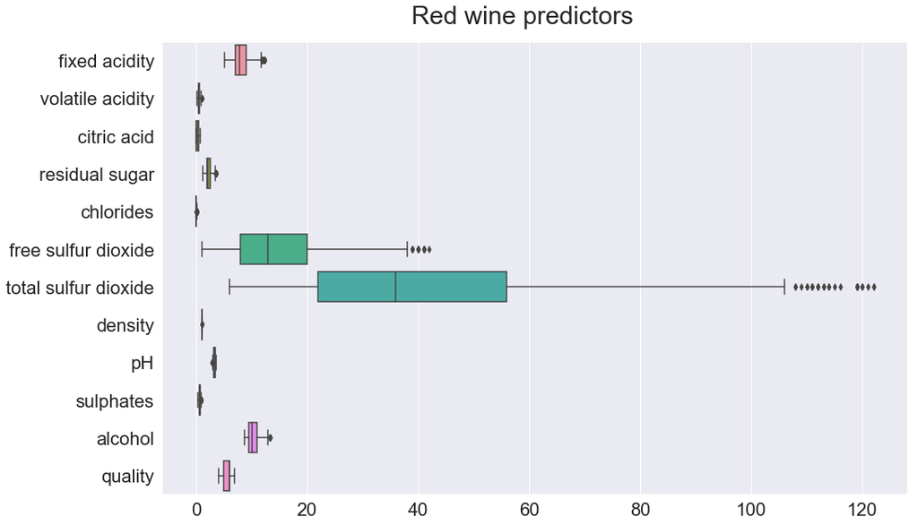

```python
box_plot(data = wine_red_clear, title = "Red wine predictors")
```

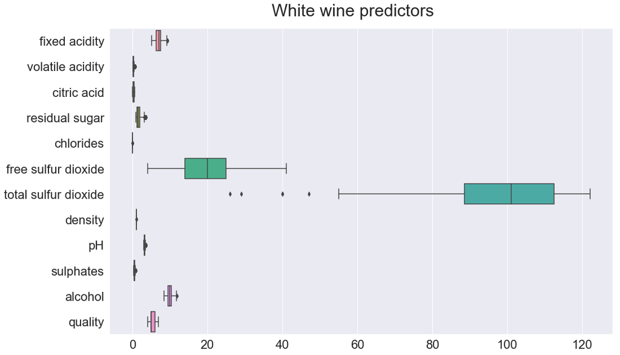

```python
box_plot(data = wine_white_clear, title = "White wine predictors")
```

## Standardizing the dataset

```python
from sklearn import preprocessing
scaler = preprocessing.MinMaxScaler()
```

```python
wine_red_df_preprocessed = pd.DataFrame(scaler.fit_transform(wine_red_clear.iloc[:,:-1]))
wine_white_df_preprocessed = pd.DataFrame(scaler.fit_transform(wine_white_clear.iloc[:,:-1]))
```

## Splitting the data set

```python
X_train_red, X_test_red, y_train_red, y_test_red = train_test_split(wine_red_df_preprocessed, wine_red_clear.iloc[:, -1],
                                                    test_size=0.25, random_state=1)
X_train_white, X_test_white, y_train_white, y_test_white = train_test_split(wine_white_df_preprocessed, wine_white_clear.iloc[:, -1],
                                                    test_size=0.25, random_state=1)
```

## Support Vector Machines (SVM)

```python
def svm_accuracy_cv(X_train, X_test, y_train, y_test, n_fold = 10):
    best_score = 0
    best_C = 10000
    C_list = [1, 10, 100, 1000]
    for C in C_list:
        svc = svm.SVC(C = C, kernel = 'rbf')
        # Getting the scores on n folds
        scores = cross_val_score(svc, X_train, y_train, cv = n_fold)
        score = scores.mean()
        if score > best_score:
            best_C = C
            best_score = score

    svc = svm.SVC(C = best_C, kernel = "rbf")
    svc.fit(X_train, y_train)
    accuracy = svc.score(X_test, y_test)
    return accuracy, best_C
```

```python
red_wine_accuracy, C_red = svm_accuracy_cv(X_train_red, X_test_red, y_train_red, y_test_red, n_fold = 10)
white_wine_accuracy, C_white = svm_accuracy_cv(X_train_white, X_test_white, y_train_white, y_test_white, n_fold = 10)

# Print the accuracy
print("The accuracy of the SVM model on Red wine dataset with 10 fold cross validation is",
      round(red_wine_accuracy * 100, 2))
print("The accuracy of the SVM model on White wine dataset with 10 fold cross validation is",
      round(white_wine_accuracy * 100, 2))
```

```
The accuracy of the SVM model on Red wine dataset with 10 fold cross validation is 63.05
The accuracy of the SVM model on White wine dataset with 10 fold cross validation is 58.0
```

## Naive Bayes Classifier

```python
def naiveBayes_accuracy_cv(X_train, X_test, y_train, y_test, n_fold = 10):
    best_score = 0
    best_C = 10000
    C_list = [1, 10, 100, 1000]
    for C in C_list:
        gnb = GaussianNB()
        # Getting the scores on n folds
        scores = cross_val_score(gnb, X_train, y_train, cv = n_fold)
        score = scores.mean()
        if score > best_score:
            best_C = C
            best_score = score

    gnb = GaussianNB()
    gnb.fit(X_train, y_train)
    accuracy = gnb.score(X_test, y_test)
    return accuracy, best_C
```

```python
red_wine_accuracy, C_red = naiveBayes_accuracy_cv(X_train_red, X_test_red, y_train_red, y_test_red, n_fold = 10)
white_wine_accuracy, C_white = naiveBayes_accuracy_cv(X_train_white, X_test_white, y_train_white, y_test_white, n_fold = 10)

# Print the accuracy
print("The accuracy of the Naive Bayes model on Red wine dataset with 10 fold cross validation is",round(red_wine_accuracy * 100, 2))
print("The accuracy of the Naive Bayes model on White wine dataset with 10 fold cross validation is",round(white_wine_accuracy * 100, 2))
```

```
The accuracy of the Naive Bayes model on Red wine dataset with 10 fold cross validation is 56.61
The accuracy of the Naive Bayes model on White wine dataset with 10 fold cross validation is 40.0
```

## Decision Tree

```python
from sklearn.tree import DecisionTreeClassifier
def decisionTree_accuracy_cv(X_train, X_test, y_train, y_test, n_fold = 10):
    best_score = 0
    best_C = 10000
    C_list = [1, 10, 100, 1000]
    for C in C_list:
        dtc = DecisionTreeClassifier()
        # Getting the scores on n folds
        scores = cross_val_score(dtc, X_train, y_train, cv = n_fold)
        score = scores.mean()
        if score > best_score:
            best_C = C
            best_score = score

    dtc = DecisionTreeClassifier()
    dtc.fit(X_train, y_train)
    accuracy = dtc.score(X_test, y_test)
    return accuracy, best_C
```

```python
red_wine_accuracy, C_red = decisionTree_accuracy_cv(X_train_red, X_test_red, y_train_red, y_test_red, n_fold = 10)
white_wine_accuracy, C_white = decisionTree_accuracy_cv(X_train_white, X_test_white, y_train_white, y_test_white, n_fold = 10)

# Print the accuracy
print("The accuracy of the Decision Tree model on Red wine dataset with 10 fold cross validation is",round(red_wine_accuracy * 100, 2))
print("The accuracy of the Decision Tree model on White wine dataset with 10 fold cross validation is",round(white_wine_accuracy * 100, 2))
```

```
The accuracy of the Decision Tree model on Red wine dataset with 10 fold cross validation is 62.37
The accuracy of the Decision Tree model on White wine dataset with 10 fold cross validation is 42.0
```

## Random Forest Classifier

```python
from sklearn.ensemble import RandomForestClassifier
def randomForest_accuracy_cv(X_train, X_test, y_train, y_test, n_fold = 10):
    best_score = 0
    best_C = 10000
    C_list = [1, 10, 100, 1000]
    for C in C_list:
        rf = RandomForestClassifier()
        # Getting the scores on n folds
        scores = cross_val_score(rf, X_train, y_train, cv = n_fold)
        score = scores.mean()
        if score > best_score:
            best_C = C
            best_score = score

    rf = RandomForestClassifier()
    rf.fit(X_train, y_train)
    accuracy = rf.score(X_test, y_test)
    return accuracy, best_C
```

```python
red_wine_accuracy, C_red = randomForest_accuracy_cv(X_train_red, X_test_red, y_train_red, y_test_red, n_fold = 10)
white_wine_accuracy, C_white = randomForest_accuracy_cv(X_train_white, X_test_white, y_train_white, y_test_white, n_fold = 10)

# Print the accuracy
print("The accuracy of the Decision Tree model on Red wine dataset with 10 fold cross validation is",round(red_wine_accuracy * 100, 2))
print("The accuracy of the Decision Tree model on White wine dataset with 10 fold cross validation is",round(white_wine_accuracy * 100, 2))
```

```
The accuracy of the Decision Tree model on Red wine dataset with 10 fold cross validation is 66.78
The accuracy of the Decision Tree model on White wine dataset with 10 fold cross validation is 52.0
```